# PROJET: tuberculose

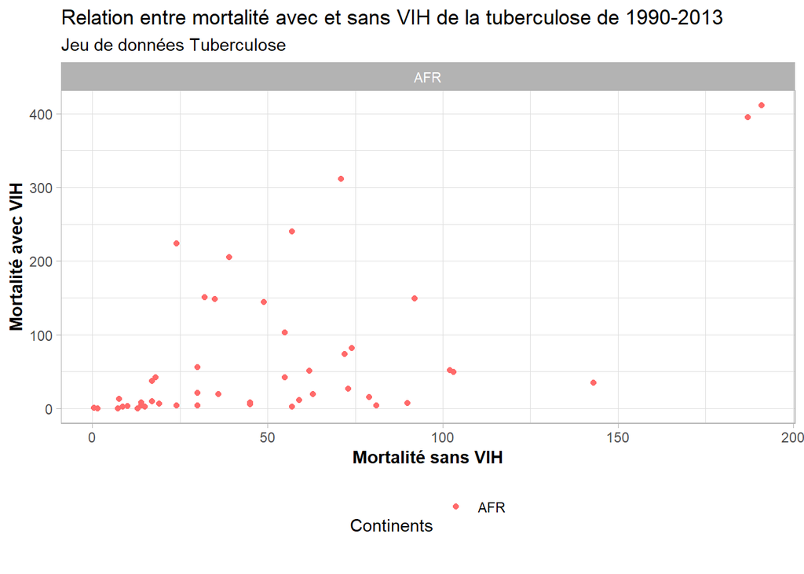

```r
  # Ajuste la légende en bas et les titres des axes en gras. Les labels de l'axe des X sont inclinés pour une meilleure lisibilité.


# 3) Nuage de points uniquement pour la région AFR (Afrique)
ggplot(TB2_2000 %>% filter(Region == "AFR")) +
  # Filtre les données pour ne garder que celles de la région AFR (Afrique).

  aes(x = `Estimated_mortality_of_TB_cases_(all_forms,_excluding_HIV)_per_100_000_population`,
      y = `Estimated_mortality_of_TB_cases_who_are_HIV-positive,_per_100_000_population`,
      colour = Region) +
  geom_point() +
  # Ajoute des points au graphique.

  scale_colour_manual(values = region_colors) +
  # Applique la palette de couleurs définie pour la région AFR.

  labs(
    x = "Mortalité sans VIH",
    y = "Mortalité avec VIH",
    colour = "Continents"
  ) +
  # Définit les labels pour les axes et la légende des couleurs.

  ggtitle("Relation entre mortalité avec et sans VIH de la tuberculose de 1990-2013",
          subtitle = "Jeu de données Tuberculose") +
  # Définit le titre et le sous-titre du graphique.

  scale_x_continuous(labels =scales::label_number(decimal.mark = ",")) +
  scale_y_continuous(labels =scales::label_number(decimal.mark = ",")) +
  # Applique le formatage des nombres avec des virgules sur les axes X et Y.

  facet_grid(cols = vars(Region)) +
  # Crée une grille de facettes, mais ici il n'y a qu'une seule facette (la région AFR).

  guides(color = guide_legend(nrow = 2)) +
  # Organise la légende en 2 lignes.

  theme_light() +
  theme(
    legend.position = "bottom",
    axis.title = element_text(face = "bold")
  )
```

```r
  # Ajuste la position de la légende et met les titres des axes en gras.
```

On peut observer une moyenne dépendance entre la prévalence et l’incidence car les points ne s’alignent pas vraiment autour d’une droite, comme démontré par le calcul de nos coefficients. En effet,la corrélation de Pearson est de 0.54 et la corrélation de Spearman est de 0.65. Donc, la relation est modérée, mais n’est pas très forte.

Le deuxième graphique représente la relation entre mortalité avec et sans VIH mais concentrée sur l’Europe (EUR), l’Asie du Sud-Est (SEA), la Méditerranée orientale (EMR), le Pacifique occidental (WPR) et l’Amérique (AMR) :

Ces graphiques illustrent donc l’urgence d’une action ciblée en Afrique et en Asie du Sud-Est, tout en mettant en lumière l’efficacité des politiques de contrôle en Europe et en Amérique.

#### Regression linéaire

La régression linétaire permet de modéliser la relation entre la mortalité sans VIH et avec VIH

```r
# Modèle de régression linéaire pour étudier la relation entre la mortalité de la tuberculose sans VIH et la mortalité de la tuberculose avec VIH
mortality_vs_hiv <- TB2_2000 %>%
  lm(`Estimated_mortality_of_TB_cases_(all_forms,_excluding_HIV)_per_100_000_population` ~
       `Estimated_mortality_of_TB_cases_who_are_HIV-positive,_per_100_000_population`, data = .)
# Utilisation de `lm()` pour ajuster un modèle de régression linéaire. La variable dépendante est la mortalité de la tuberculose sans VIH,
# et la variable explicative est la mortalité de la tuberculose avec VIH. Les données proviennent du dataframe `TB2_2000`.

summary(mortality_vs_hiv)
```

```
##
## Call:
## lm(formula = `Estimated_mortality_of_TB_cases_(all_forms,_excluding_HIV)_per_100_000_population` ~
##     `Estimated_mortality_of_TB_cases_who_are_HIV-positive,_per_100_000_population`,
##     data = .)
##
## Residuals:
##    Min     1Q Median     3Q    Max
## -68.60 -15.60 -12.34   3.28 139.61
##
## Coefficients:
##                                                                                Estimate
## (Intercept)                                                                    16.54346
## `Estimated_mortality_of_TB_cases_who_are_HIV-positive,_per_100_000_population`  0.33954
##                                                                                Std. Error
## (Intercept)                                                                       2.09443
## `Estimated_mortality_of_TB_cases_who_are_HIV-positive,_per_100_000_population`    0.03631
##                                                                                t value
## (Intercept)                                                                      7.899
## `Estimated_mortality_of_TB_cases_who_are_HIV-positive,_per_100_000_population`   9.352
##                                                                                Pr(>|t|)
## (Intercept)                                                                    1.55e-13
## `Estimated_mortality_of_TB_cases_who_are_HIV-positive,_per_100_000_population`  < 2e-16
##
## (Intercept)                                                                    ***
## `Estimated_mortality_of_TB_cases_who_are_HIV-positive,_per_100_000_population` ***
## ---
## Signif. codes:  0 '***' 0.001 '**' 0.01 '*' 0.05 '.' 0.1 ' ' 1
##
## Residual standard error: 29.28 on 210 degrees of freedom
## Multiple R-squared:  0.294,  Adjusted R-squared:  0.2906
## F-statistic: 87.45 on 1 and 210 DF,  p-value: < 2.2e-16
```

```r
# Affiche les résultats du résumé du modèle de régression, incluant les coefficients, les valeurs p, les R², etc.
```

Tout d’abord, les résidus représentent la différence entre les valeurs observées et les valeurs prédites par le modèle. On peut voir que le minimum est de -68.60 , le 1er quartile est de -15.60 , la médiane est de -12.34 et le 3ème quartile est de 3.28 ainsi que le maximum est de 139.61 .

La mortalité de la tuberculose (toutes formes, excluant VIH) dans la population générale est positivement liée à la mortalité de la tuberculose chez les personnes vivant avec le VIH. Pour chaque augmentation de 1 décès par 100 000 habitants dans la mortalité des personnes vivant avec le VIH, la mortalité de la tuberculose (excluant le VIH) augmente de 0.34 décès par 100 000 habitants.

Le p-value de la variable indépendante (mortalité chez les personnes vivant avec le VIH) est très faible (< 2.2e-16), ce qui signifie que cette relation est hautement significative.

L’intercept (constante) est également significatif avec un p-value de 1.55e-13.

R-squared :

Le modèle explique 29.4% de la variance dans la mortalité de la tuberculose (excluant le VIH). Cela suggère que d’autres facteurs non inclus dans ce modèle peuvent aussi influencer la mortalité de la tuberculose.

Le F-statistic est élevé (87.45), ce qui montre que le modèle est globalement significatif et que la relation entre les deux variables est robuste.

Ainsi, le modèle montre que la mortalité chez les personnes vivant avec le VIH est un prédicteur significatif de la mortalité de la tuberculose dans la population générale, bien que le modèle n’explique qu’environ 29.4% de la variance.

#### Résidus versus valeurs ajustées

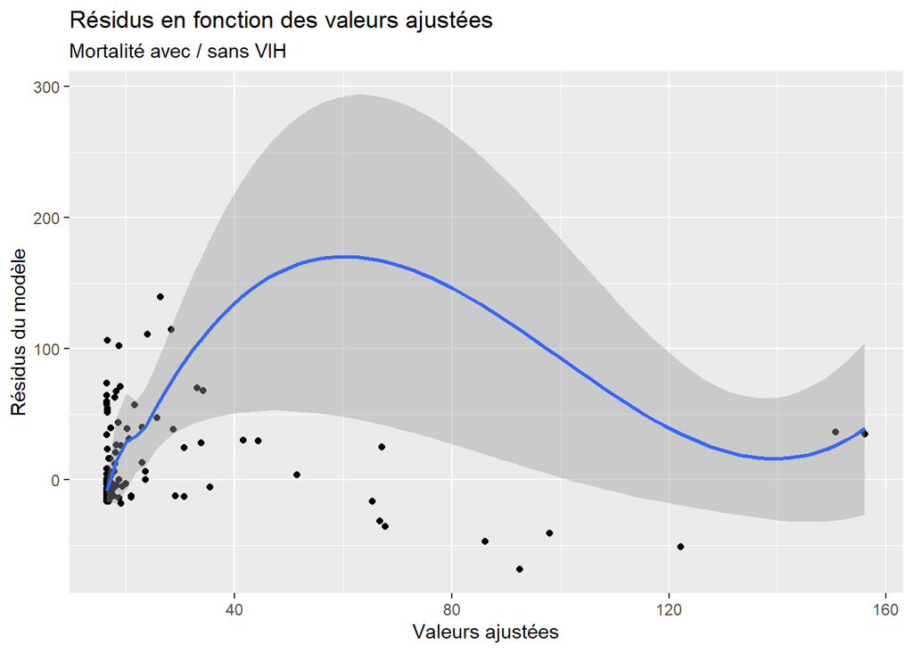

```r
# Création d'un graphique de dispersion pour analyser la relation entre les valeurs ajustées et les résidus du modèle
ggplot() +
  aes(x = fitted(mortality_vs_hiv), y = residuals(mortality_vs_hiv)) +
  # `aes()` définit les variables à afficher sur les axes X (valeurs ajustées du modèle) et Y (résidus du modèle)

  geom_point() +
  # `geom_point()` ajoute un nuage de points pour visualiser les relations entre les valeurs ajustées et les résidus

  geom_smooth() +
  # `geom_smooth()` ajoute une courbe lissée pour examiner la tendance générale entre les valeurs ajustées et les résidus

  xlab("Valeurs ajustées") +
  # `xlab()` définit le titre de l'axe X comme "Valeurs ajustées"

  ylab("Résidus du modèle") +
  # `ylab()` définit le titre de l'axe Y comme "Résidus du modèle"

  ggtitle("Résidus en fonction des valeurs ajustées", subtitle = "Mortalité avec / sans VIH")
```

```r
  # `ggtitle()` ajoute un titre principal et un sous-titre au graphique
```

L’écart-type des résidus semble se réduire pour les valeurs ajustées élevées, ce qui suggère une variabilité moindre des erreurs pour les prédictions élevées.

La courbe lissée indique une forme non linéaire des résidus par rapport aux valeurs ajustées. Cela suggère qu’un modèle linéaire ne s’adapte pas parfaitement aux données, car les erreurs de prédiction ne sont pas distribuées de manière homogène à travers les différentes valeurs ajustées.

Ainsi, le graphique des résidus versus valeurs ajustées montre que la dispersion des résidus varie en fonction des valeurs ajustées. En effet, pour des valeurs ajustées faibles, les résidus sont plus dispersés, tandis que pour des valeurs ajustées élevées, la dispersion des résidus est plus faible. Cela indique que la variance des erreurs n’est pas constante. De plus, la courbe lissée (geom_smooth) montre une forme non linéaire, ce qui signifie que le modèle linéaire ne capture pas toute la dynamique des données. La relation entre les variables semble plus complexe qu’une simple droite.

#### Qq-plot

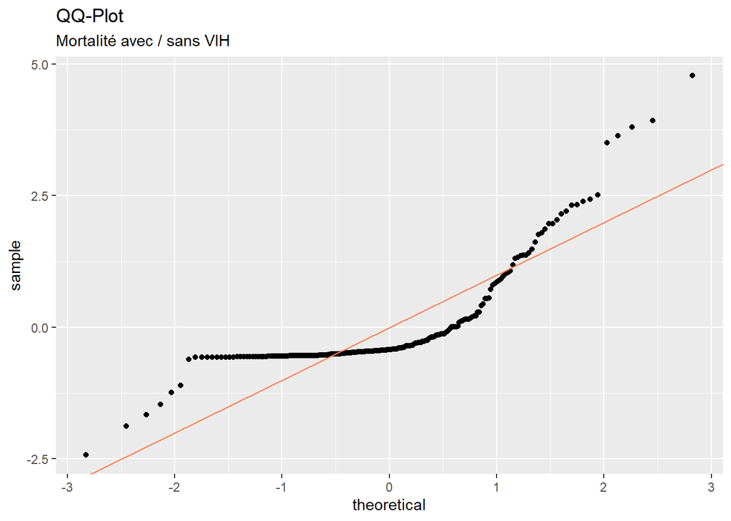

```r
# Création d'un QQ-plot pour analyser la distribution des résidus standardisés
ggplot() +
  geom_qq(aes(sample=rstandard(mortality_vs_hiv))) +
  # `geom_qq()` génère un QQ-plot pour visualiser la distribution des résidus standardisés
  # `aes(sample=rstandard(mortality_vs_hiv))` spécifie que les résidus standardisés du modèle sont utilisés pour l'échantillon du QQ-plot

  geom_abline(color="coral") +
  # `geom_abline()` ajoute une ligne de référence (droite) représentant une distribution normale théorique
  # `color="coral"` définit la couleur de la ligne de référence en corail

  ggtitle("QQ-Plot", subtitle="Mortalité avec / sans VIH")
```

```r
  # `ggtitle()` ajoute un titre principal et un sous-titre au graphique pour indiquer qu'il s'agit d'un QQ-plot
```

Le QQ-plot montre la distribution des résidus de notre modèle de régression par rapport à une distribution normale théorique.

Or, les points commencent à s’éloigner de la droite aux extrémités (dans les valeurs négatives et positives élevées), ce qui suggère que les résidus présentent des queues plus lourdes que ce qui serait attendu d’une distribution normale. Cela pourrait indiquer une asymétrie ou la présence de valeurs extrêmes, que nous allons chercher avec notre distance de cook.

#### Scale-location (position-échelle)

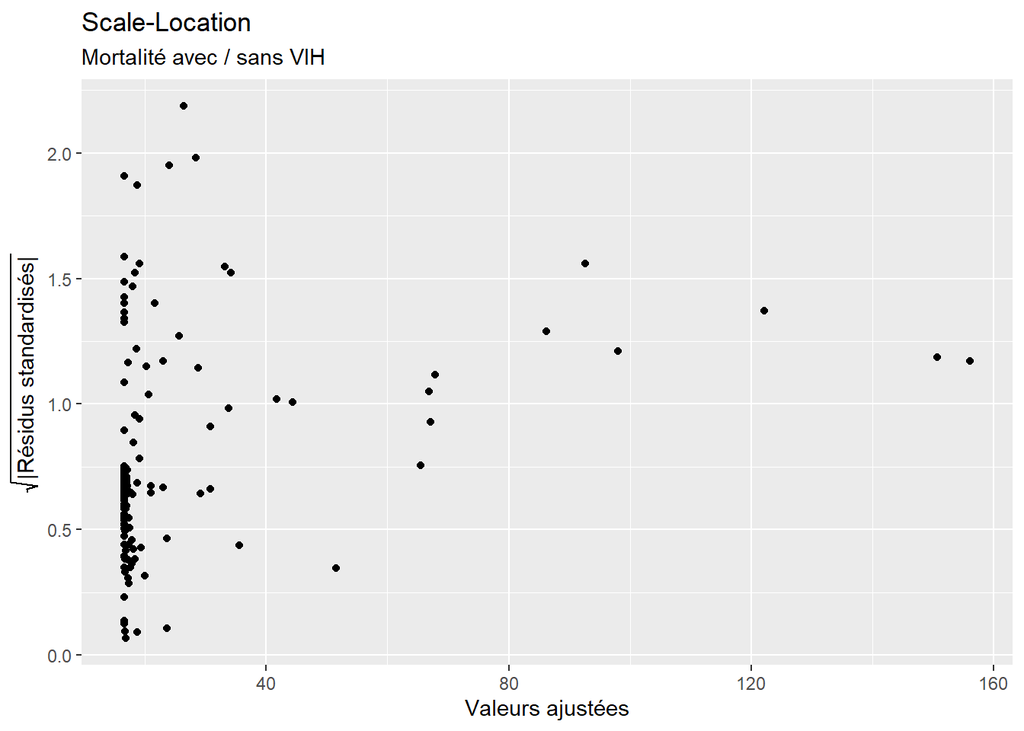

```r
# Création d'un graphique Scale-Location pour analyser les résidus standardisés
ggplot() +
  aes(x = fitted(mortality_vs_hiv), y = sqrt(abs(rstandard(mortality_vs_hiv)))) +
  # Définit les axes du graphique :
  # L'axe des x représente les valeurs ajustées du modèle (fitted values),
  # L'axe des y représente la racine carrée des résidus standardisés (avec la transformation sqrt(abs(...)))

  geom_point() +
  # `geom_point()` ajoute les points du graphique en fonction des valeurs des axes x et y

  xlab("Valeurs ajustées") +
  # `xlab("Valeurs ajustées")` ajoute un titre à l'axe des x, spécifiant qu'il représente les valeurs ajustées du modèle

  ylab(expression(sqrt("|Résidus standardisés|"))) +
  # `ylab(expression(sqrt("|Résidus standardisés|")))` ajoute un titre à l'axe des y, spécifiant qu'il représente la racine carrée des valeurs absolues des résidus standardisés

  ggtitle("Scale-Location", subtitle="Mortalité avec / sans VIH")
```

```r
  # `ggtitle()` ajoute un titre principal et un sous-titre à ce graphique pour indiquer qu'il s'agit du graphique Scale-Location de la mortalité avec et sans VIH
```

Ce graphique montre la relation entre les valeurs ajustées (prédictions du modèle) et les résidus standardisés (échelles transformées par la racine carrée des résidus absolus). Cela permet d’examiner si l’hypothèse d’homoscédasticité (variance constante des résidus) est respectée.

On peut voir que les points sont dispersés de manière uniforme sans tendance visible importante, ce qui est un bon signe pour l’homoscédasticité.

Cependant, quelques points se distinguent à gauche (valeurs ajustées faibles), où les résidus standardisés sont plus élevés, ce qui pourrait indiquer une légère variabilité des erreurs pour des petites valeurs ajustées. Cela peut suggérer qu’un modèle linéaire ne s’ajuste pas parfaitement aux données pour ces cas spécifiques.

Le graphique montre que, dans l’ensemble, les résidus standardisés sont relativement uniformément dispersés par rapport aux valeurs ajustées, ce qui suggère une homoscédasticité pour la plupart des observations.

Toutefois, quelques points à faible valeur ajustée pourraient indiquer des problèmes locaux (comme une mauvaise spécification du modèle ou des valeurs extrêmes) qu’il faudrait peut-être examiner plus en détail, avec la distance de cook.

Ainsi, concernant notre graphique sur la dispersion des résidus et le scale-location, on comprend que la dispersion des erreurs n’est pas constante à travers toutes les valeurs ajustées, mais l’homoscédasticité semble respecter l’hypothèse de constance des erreurs à mesure que l’on progresse dans les valeurs ajustées plus élevées. Identifions maintenant les points influents :

#### Distance de cook

```r
# Calcul de la distance de Cook
cooks_dist <- cooks.distance(mortality_vs_hiv)
# `cooks.distance(mortality_vs_hiv)` calcule la distance de Cook pour chaque observation du modèle de régression `mortality_vs_hiv`.
# La distance de Cook mesure l'influence de chaque point sur les paramètres estimés du modèle.

# Définir un seuil pour identifier les points outliers
seuil_cooks <- 4 / length(cooks_dist)
# `seuil_cooks <- 4 / length(cooks_dist)` définit un seuil pour identifier les points influents (outliers).
# Le seuil est basé sur une règle empirique (4/n, où n est le nombre total d'observations).

# Identifier les indices des points qui dépassent le seuil
outliers_indices <- which(cooks_dist > seuil_cooks)
# `which(cooks_dist > seuil_cooks)` identifie les indices des observations dont la distance de Cook dépasse le seuil défini,
# ce qui indique qu'elles sont influentes (potentiellement des outliers).

# Extraire les pays correspondants aux outliers
outliers_pays <- TB2_2000$Country_or_territory_name[outliers_indices]
# `TB2_2000$Country_or_territory_name[outliers_indices]` extrait les noms des pays correspondant aux indices des outliers,
# en se basant sur la colonne `Country_or_territory_name` du dataframe `TB2_2000`.

# Afficher les pays des outliers
print(outliers_pays)
```

```
##  [1] "Botswana"
##  [2] "Cambodia"
##  [3] "Central African Republic"
##  [4] "Democratic People's Republic of Korea"
##  [5] "Gabon"
##  [6] "Lao People's Democratic Republic"
##  [7] "Lesotho"
##  [8] "Malawi"
##  [9] "Myanmar"
## [10] "Namibia"
## [11] "Swaziland"
## [12] "Zambia"
## [13] "Zimbabwe"
```

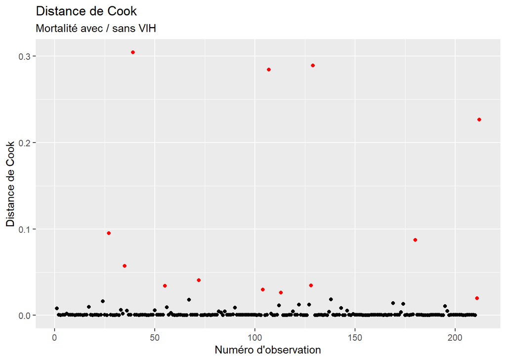

```r
# `print(outliers_pays)` affiche les pays qui ont des distances de Cook supérieures au seuil, identifiés comme influents.

# Afficher la distance de Cook avec les outliers en rouge
ggplot() +
  aes(x = seq_along(cooks_dist), y = cooks_dist) +
  # `aes(x = seq_along(cooks_dist), y = cooks_dist)` définit les axes du graphique :
  # L'axe des x représente les numéros d'observation (séquence de la longueur de `cooks_dist`),
  # L'axe des y représente les distances de Cook de chaque observation.

  geom_point() +
  # `geom_point()` ajoute les points de toutes les observations sur le graphique.

  geom_point(data = data.frame(x = outliers_indices, y = cooks_dist[outliers_indices]),
             aes(x = x, y = y), colour = "red") +
  # `geom_point(data = data.frame(...))` ajoute les points identifiés comme outliers (distance de Cook > seuil) en rouge.

  xlab("Numéro d'observation") +
  # `xlab("Numéro d'observation")` définit le titre de l'axe des x pour indiquer que les points sont numérotés par leur position dans l'échantillon.

  ylab("Distance de Cook") +
  # `ylab("Distance de Cook")` définit le titre de l'axe des y pour indiquer que les valeurs représentent la distance de Cook.

  ggtitle("Distance de Cook", subtitle = "Mortalité avec / sans VIH")
```

```r
  # `ggtitle("Distance de Cook", subtitle = "Mortalité avec / sans VIH")` ajoute un titre principal et un sous-titre au graphique pour décrire son contenu.
```

Ce graphique montre la distance de Cook pour chaque observation dans le modèle de régression, ce qui permet d’identifier les observations qui ont une influence excessive sur les coefficients du modèle. Les points influents sont : Botswana, Cambodia, Central African Republic, Democratic People’s Republic of Korea, Gabon,Lao People’s Democratic Republic, Lesotho, Malawi, Myanmar, Namibia, Swaziland, Zambia, Zimbabwe

Le graphique suggère qu’une petite fraction des observations ont une influence significative sur le modèle. Si ces points influents sont des erreurs de saisie ou des anomalies, leur exclusion ou leur traitement pourrait améliorer l’ajustement du modèle.

#### Residual versus leverage

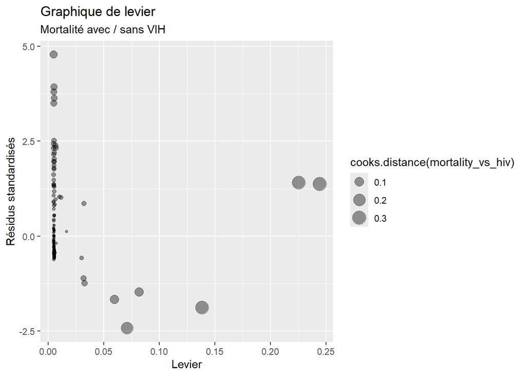

```r
# Création du graphique avec ggplot
ggplot() +
  # Lancement de la fonction ggplot pour initialiser le graphique sans données initiales.
  # Le graphique sera construit en ajoutant des éléments comme les axes et les points par la suite.

  aes(x = hatvalues(mortality_vs_hiv), y = rstandard(mortality_vs_hiv)) +
  # Définition des axes du graphique :
  # - L'axe des x représente les valeurs de levier (influence de chaque observation sur les résultats du modèle), calculées par la fonction `hatvalues(mortality_vs_hiv)`.
  # - L'axe des y représente les résidus standardisés du modèle `mortality_vs_hiv`, calculés par la fonction `rstandard(mortality_vs_hiv)`.

  geom_point(aes(size=cooks.distance(mortality_vs_hiv)), alpha=0.4) +
  # Ajout des points au graphique :
  # - La taille des points est déterminée par la distance de Cook de chaque observation, ce qui permet de visualiser l'influence relative des points.
  # - L'argument `alpha=0.4` ajuste la transparence des points (valeurs entre 0 et 1, ici 40% de transparence).

  xlab("Levier") +
  # Ajout du titre pour l'axe des x, ici le levier, qui est une mesure de l'influence d'une observation sur les prédictions du modèle.

  ylab("Résidus standardisés") +
  # Ajout du titre pour l'axe des y, ici les résidus standardisés, qui mesurent l'écart entre la valeur observée et la valeur ajustée, normalisé.

  ggtitle("Graphique de levier", subtitle="Mortalité avec / sans VIH")
```

```r
  # Ajout du titre principal et du sous-titre du graphique. Le titre indique que le graphique représente le "Graphique de levier", et le sous-titre précise le contexte : "Mortalité avec / sans VIH".
```

Ce graphique examine la relation entre les résidus standardisés et le levier des observations dans le modèle de régression, tout en tenant compte de la distance de Cook. Il permet de détecter les points influents, à la fois en termes d’impact sur la régression (résidus) et de leur influence sur le modèle (levier).

Le graphique de levier montre la relation entre les résidus standardisés et les leviers (influence des points sur les prédictions du modèle). Certains points se détachent, notamment ceux mentionnés dans la liste des points influents (Botswana, Cambodge, etc.), indiquant qu’ils ont un levier élevé. Cela signifie que ces observations ont une grande capacité à modifier les prédictions du modèle, et qu’elles peuvent potentiellement fausser la précision du modèle si elles ne sont pas correctement prises en compte.

Le levier mesure l’influence potentielle d’une observation sur les valeurs ajustées du modèle. Un levier élevé indique qu’une observation est éloignée de la moyenne des autres observations. Les résidus standardisés mesurent l’écart entre les valeurs observées et les valeurs ajustées, normalisées pour tenir compte de la variance des erreurs.

Les points avec un levier élevé sont plus éloignés de la droite de régression, ce qui signifie qu’ils ont une forte capacité à influencer les résultats du modèle.

Les grands cercles (indiquant une distance de Cook élevée) correspondent aux points les plus influents, ceux qui ont à la fois un levier élevé et un résidu important.

En revanche, la majorité des points se trouvent près de l’axe des résidus (proches de zéro), indiquant que la plupart des observations ont une faible influence sur le modèle.

Un levier élevé combiné à un résidu important indique qu’une observation a une influence significative sur le modèle, et ces observations doivent être vérifiées pour décider si elles doivent être exclues ou traitées différemment.

En résumé, ce graphique identifie les points influents qui peuvent nécessiter une attention particulière avant d’interpréter pleinement les résultats du modèle.

En somme, la distance de cook et le graphique de levier témoignent bien du fait que les pays d’Afrique et d’Asie du Sud-Est et de l’Est souffrent plus de la situation sanitaire de la tuberculose par rapport aux autres régions du monde. Notamment par la présence de points influents réprésentant des pays se situant dans ces régions là. Les points communs entre ces pays incluent des défis liés à la pauvreté, aux problèmes de santé publique, à un accès limité aux soins de santé, des inégalités économiques et sociales, ainsi que des instabilités politiques dans certains cas. Les systèmes de santé fragiles et les épidémies (notamment la tuberculose et le VIH) demeurent des préoccupations majeures pour ces pays.

Pour conclure, il existe une relation interdépendante entre la mortalité avec VIH et la mortalité sans VIH dans le contexte de la tuberculose. Le VIH est un facteur aggravant majeur de la mortalité liée à la tuberculose, en particulier dans les pays où les deux infections sont courantes. Bien que les personnes non infectées par le VIH aient un risque plus faible de mortalité due à la tuberculose, la co-infection VIH-tuberculose entraîne une mortalité plus élevée.

## II.1.3) prévalence & mortalité avec VIH

#### covariance

```r
# Sélectionner les colonnes nécessaires dans le jeu de données TB2_2000
TB2_2000 %>%
  select(`Estimated_prevalence_of_TB_(all_forms)_per_100_000_population`,
         # Sélection de la colonne 'Estimated_prevalence_of_TB_(all_forms)_per_100_000_population' qui représente la prévalence de la tuberculose pour tous les cas, exprimée pour 100 000 habitants.
         `Estimated_mortality_of_TB_cases_who_are_HIV-positive,_per_100_000_population`) %>%
         # Sélection de la colonne 'Estimated_mortality_of_TB_cases_who_are_HIV-positive,_per_100_000_population' qui représente la mortalité des cas de tuberculose associés au VIH, également exprimée pour 100 000 habitants.

  cov()
```

```
##                                                                              Estimated_prevalence_of_TB_(all_forms)_per_100_000_population
## Estimated_prevalence_of_TB_(all_forms)_per_100_000_population                                                                     79120.66
## Estimated_mortality_of_TB_cases_who_are_HIV-positive,_per_100_000_population                                                       8441.29
##                                                                              Estimated_mortality_of_TB_cases_who_are_HIV-positive,_per_100_000_population
## Estimated_prevalence_of_TB_(all_forms)_per_100_000_population                                                                                    8441.290
## Estimated_mortality_of_TB_cases_who_are_HIV-positive,_per_100_000_population                                                                     3082.145
```

```r
  # La fonction `cov()` calcule la matrice de covariance de ces deux variables.
```

Covariance de la prévalence avec elle-même : 79120.66 La covariance d’une variable avec elle-même est égale à la variance de cette variable. Cela montre à quel point les valeurs de prévalence varient par rapport à leur moyenne. La valeur élevée de 79120.66 indique une dispersion importante des valeurs de prévalence autour de la moyenne, suggérant que la prévalence varie de manière notable.

Covariance entre la prévalence et la mortalité avec VIH : 8441.29 La covariance positive entre la prévalence de la tuberculose et la mortalité due à la tuberculose chez les personnes vivant avec le VIH montre que lorsque la prévalence de la tuberculose augmente, la mortalité tend également à augmenter (et vice versa). Cette relation positive indique qu’une plus grande prévalence dans une région est généralement associée à une plus grande mortalité chez les personnes vivant avec le VIH.

Covariance de la mortalité avec VIH avec elle-même : 3082.145 La covariance de la mortalité avec VIH avec elle-même représente la variance de cette variable. Elle montre à quel point les valeurs de mortalité varient autour de leur moyenne. La valeur de 3082.145 indique une dispersion modérée des valeurs de mortalité par rapport à la moyenne.

La covariance positive entre la prévalence et la mortalité avec VIH (8441.29) confirme qu’il existe une relation directe entre ces deux variables : lorsque la prévalence de la tuberculose augmente, la mortalité avec VIH augmente également.

Cependant, la covariance est influencée par les unités des variables, ce qui rend difficile l’évaluation de la force de la relation. Pour obtenir une mesure normalisée de cette relation, il serait préférable de calculer le coefficient de corrélation entre ces variables, ce qui permettrait de mieux comprendre la force et la direction de la relation entre la prévalence et la mortalité avec VIH.

#### Coefficient de corrélation pearson

```r
# Calcul du coefficient de corrélation de Pearson entre la prévalence et la mortalité liée au VIH dans les cas de tuberculose
cor(
  x = TB2_2000[["Estimated_prevalence_of_TB_(all_forms)_per_100_000_population"]],
  # La variable x correspond à la prévalence de la tuberculose pour tous les cas, exprimée pour 100 000 habitants.

  y = TB2_2000[["Estimated_mortality_of_TB_cases_who_are_HIV-positive,_per_100_000_population"]],
  # La variable y correspond à la mortalité des cas de tuberculose chez les personnes vivant avec le VIH, également exprimée pour 100 000 habitants.

  method = "pearson"
  # La méthode choisie est le coefficient de corrélation de Pearson, qui mesure la relation linéaire entre les deux variables.
)
```

```
## [1] 0.5405518
```

#### Coefficient de corrélation Spearman

```r
# Calcul du coefficient de corrélation de Spearman entre la prévalence et la mortalité liée au VIH dans les cas de tuberculose
cor(
  x = TB2_2000[["Estimated_prevalence_of_TB_(all_forms)_per_100_000_population"]],
  # La variable x correspond à la prévalence de la tuberculose pour tous les cas, exprimée pour 100 000 habitants.

  y = TB2_2000[["Estimated_mortality_of_TB_cases_who_are_HIV-positive,_per_100_000_population"]],
  # La variable y correspond à la mortalité des cas de tuberculose chez les personnes vivant avec le VIH, également exprimée pour 100 000 habitants.

  method = "spearman"
  # La méthode choisie est le coefficient de corrélation de Spearman, qui mesure la relation monotone (mais pas nécessairement linéaire) entre les deux variables.

)
```

```
## [1] 0.6459321
```

Un coefficient de Pearson de 0.5405 indique une relation positive modérée et linéaire entre la prévalence et la mortalité de la tuberculose chez les personnes vivant avec le VIH. Cela signifie que, lorsque la prévalence de la tuberculose augmente, la mortalité chez les personnes vivant avec le VIH a tendance à augmenter également, mais de manière modérée et linéaire. La valeur de 0.5405 montre que la relation linéaire entre ces deux variables est modérée, et il existe encore des variations importantes qui ne sont pas expliquées par cette relation.

Un coefficient de Spearman de 0.6459 indique une relation monotone modérée à forte entre la prévalence et la mortalité chez les personnes vivant avec le VIH. Cela signifie que, bien que la relation ne soit pas nécessairement linéaire, les deux variables tendent à évoluer de manière similaire : à mesure que l’une augmente, l’autre augmente aussi. La valeur proche de 0.65 montre que la relation monotone entre ces deux variables est relativement forte, bien qu’il reste des fluctuations importantes.

Dans les deux cas, la corrélation est modérée mais significative, indiquant une relation entre la prévalence de la tuberculose et la mortalité chez les personnes vivant avec le VIH. Cependant, le coefficient de Spearman montre que la relation est plus robuste en termes de monotonie.

#### Nuage de points

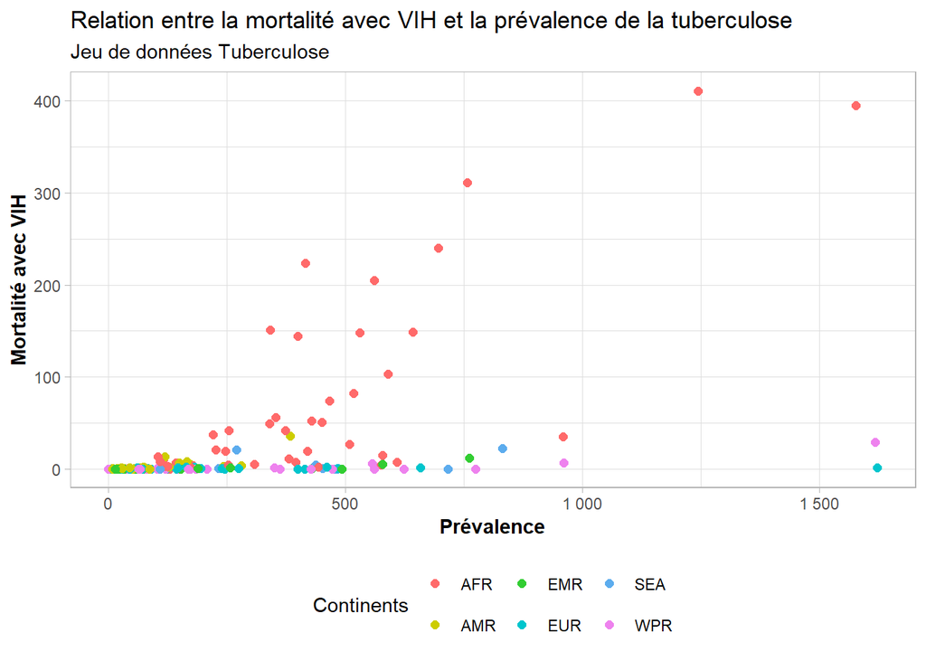

```r
# Définir une palette de couleurs fixe pour les régions
region_colors <- c("AFR" = "indianred1", "AMR" = "yellow3", "EMR" = "limegreen",
                   "EUR" = "turquoise3", "SEA" = "steelblue2", "WPR" = "violet")
# Cette ligne définit une palette de couleurs associée à chaque région (AFR, AMR, EMR, EUR, SEA, WPR).
# Chaque région aura une couleur spécifique dans les graphiques suivants.


# 1) Nuage de points avec tous les continents :
ggplot(TB2_2000) +
  aes(x = `Estimated_prevalence_of_TB_(all_forms)_per_100_000_population`,
      y = `Estimated_mortality_of_TB_cases_who_are_HIV-positive,_per_100_000_population`,
      colour = Region) +
  # Cette ligne spécifie que l'axe X représente la prévalence de la tuberculose pour 100 000 habitants et
  # l'axe Y représente la mortalité de la tuberculose liée au VIH pour 100 000 habitants.
  # L'argument 'colour = Region' permet de colorier les points en fonction de la région.

  geom_point(size = 2) +
  # Cette ligne ajoute les points de données sur le graphique avec une taille de point de 2.

  scale_colour_manual(values = region_colors) +
  # Cette ligne applique la palette de couleurs définie précédemment à chaque région.

  labs(
    x = "Prévalence",
    y = "Mortalité avec VIH",
    colour = "Continents"
  ) +
  # Cette ligne définit les titres des axes (X et Y) et du légende (pour la couleur).

  ggtitle("Relation entre la mortalité avec VIH et la prévalence de la tuberculose",
          subtitle = "Jeu de données Tuberculose") +
  # Cette ligne ajoute un titre principal au graphique et un sous-titre.

  scale_x_continuous(labels =scales::label_number(decimal.mark = ",")) +
  # Cette ligne définit le format des labels de l'axe X, en utilisant une virgule comme séparateur décimal.

  scale_y_continuous(labels =scales::label_number(decimal.mark = ",")) +
  # Cette ligne définit le format des labels de l'axe Y, en utilisant une virgule comme séparateur décimal.

  guides(color = guide_legend(nrow = 2)) +
  # Cette ligne configure la légende de couleur pour qu'elle s'affiche sur deux lignes.

  theme_light() +
  # Cette ligne applique un thème clair au graphique (avec des axes nets et un fond clair).

  theme(
    legend.position = "bottom",
    axis.title = element_text(face = "bold"))
```

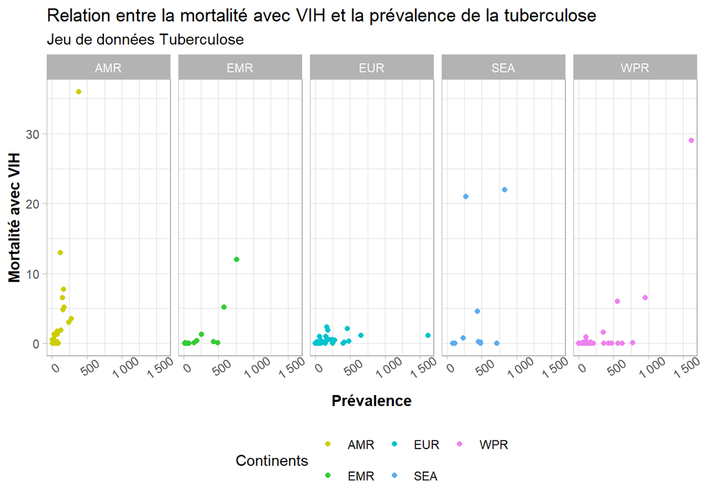

```r
# Cette ligne personnalise le thème du graphique, en plaçant la légende en bas et en mettant les titres des axes en gras.

# 2) Nuage de points sans la région AFR (Afrique) :
ggplot(TB2_2000 %>% filter(Region != "AFR")) +
  aes(x = `Estimated_prevalence_of_TB_(all_forms)_per_100_000_population`,
      y = `Estimated_mortality_of_TB_cases_who_are_HIV-positive,_per_100_000_population`,
      colour = Region) +
  # Cette ligne filtre les données pour exclure la région Afrique (AFR) et les utilise pour le nuage de points.

  geom_point() +
  # Cette ligne ajoute les points de données sur le graphique (pas de taille spécifiée).

  scale_colour_manual(values = region_colors) +
  # Cette ligne applique la palette de couleurs définie précédemment à chaque région.

  labs(
    x = "Prévalence",
    y = "Mortalité avec VIH",
    colour = "Continents"
  ) +
  # Cette ligne définit les titres des axes (X et Y) et du légende (pour la couleur).

  ggtitle("Relation entre la mortalité avec VIH et la prévalence de la tuberculose",
          subtitle = "Jeu de données Tuberculose") +
  # Cette ligne ajoute un titre principal au graphique et un sous-titre.

  scale_x_continuous(labels = scales::label_number(decimal.mark = ",")) +
  # Cette ligne définit le format des labels de l'axe X, en utilisant une virgule comme séparateur décimal.

  scale_y_continuous(labels = scales::label_number(decimal.mark = ",")) +
  # Cette ligne définit le format des labels de l'axe Y, en utilisant une virgule comme séparateur décimal.

  facet_grid(cols = vars(Region)) +
  # Cette ligne permet de diviser le graphique en sous-graphes pour chaque région. Ici, la région Afrique (AFR) a été exclue.

  guides(color = guide_legend(nrow = 2)) +
  # Cette ligne configure la légende de couleur pour qu'elle s'affiche sur deux lignes.

  theme_light() +
  # Cette ligne applique un thème clair au graphique.

  theme(
    legend.position = "bottom",
    axis.title = element_text(face = "bold"),
    axis.text.x = element_text(angle = 35))
```

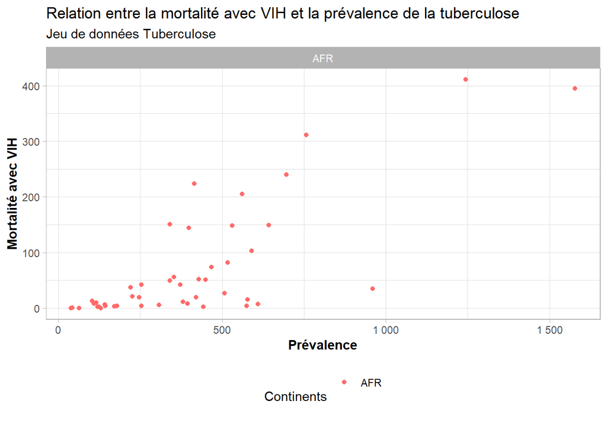

```r
# Cette ligne personnalise le thème du graphique, en plaçant la légende en bas, en mettant les titres des axes en gras et en faisant pivoter les textes des axes X de 35°.

#Nuage de points uniquement pour la région AFR (Afrique) :
ggplot(TB2_2000 %>% filter(Region == "AFR")) +
  aes(x = `Estimated_prevalence_of_TB_(all_forms)_per_100_000_population`,
      y = `Estimated_mortality_of_TB_cases_who_are_HIV-positive,_per_100_000_population`,
      colour = Region) +
  # Cette ligne filtre les données pour ne conserver que la région Afrique (AFR) et les utilise pour le nuage de points.

  geom_point() +
  # Cette ligne ajoute les points de données sur le graphique.

  scale_colour_manual(values = region_colors) +
  # Cette ligne applique la palette de couleurs définie précédemment.

  labs(
    x = "Prévalence",
    y = "Mortalité avec VIH",
    colour = "Continents"
  ) +
  # Cette ligne définit les titres des axes (X et Y) et du légende (pour la couleur).

  ggtitle("Relation entre la mortalité avec VIH et la prévalence de la tuberculose",
          subtitle = "Jeu de données Tuberculose") +
  # Cette ligne ajoute un titre principal au graphique et un sous-titre.

  scale_x_continuous(labels = scales::label_number(decimal.mark = ",")) +
  # Cette ligne définit le format des labels de l'axe X, en utilisant une virgule comme séparateur décimal.

  scale_y_continuous(labels = scales::label_number(decimal.mark = ",")) +
  # Cette ligne définit le format des labels de l'axe Y, en utilisant une virgule comme séparateur décimal.

  facet_grid(cols = vars(Region)) +
  # Cette ligne permet de diviser le graphique en sous-graphes pour chaque région. Ici, seule la région AFR est présente.

  guides(color = guide_legend(nrow = 2)) +
  # Cette ligne configure la légende de couleur pour qu'elle s'affiche sur deux lignes.

  theme_light() +
  # Cette ligne applique un thème clair au graphique.

  theme(
    legend.position = "bottom",
    axis.title = element_text(face = "bold"))
```

```r
# Cette ligne personnalise le thème du graphique, en plaçant la légende en bas et en mettant les titres des axes en gras.
```

On observe aussi ici une forte relation en Afrique entre la prévalence de la tuberculose et la mortalité avec VIH. Les points rouge représentant l’Afrique forment une certaine droite témoignant d’une forte dépendance entre la prévalence et la mortalité avec VIH.

Il est évident que plus la prévalence augmente, plus la mortalité avec VIH a tendance à augmenter. Cela est conforme à l’idée que dans les régions où la tuberculose est plus répandue, la mortalité chez les personnes vivant avec le VIH est plus élevée. Cette relation n’est pas parfaitement linéaire mais montre une tendance générale. Les points situés en bas à gauche du graphique (prévalence faible, mortalité faible) indiquent des pays où la prévalence de la tuberculose est faible et la mortalité associée au VIH également faible. En revanche, les points situés en haut à droite (prévalence élevée, mortalité élevée) indiquent des pays fortement touchés par la tuberculose et où la mortalité liée au VIH est particulièrement élevée.

L’Europe et l’Amérique présentent des valeurs faibles de mortalité, grâce à des systèmes de santé plus solides et un contrôle plus efficace de la tuberculose et du VIH.

Les pays de Méditerranée orientale et Pacifique occidental montrent aussi des faibles niveaux de mortalité, bien que quelques pays présentent des données préoccupantes.

On remarque que les pays d’Afrique (représentés en rouge) sont les plus visibles dans le coin supérieur droit du graphique. Cela indique que de nombreux pays africains sont confrontés à la fois à une forte prévalence et à une mortalité élevée liée au VIH et à la tuberculose.

Le nuage de points confirme que, de manière générale, une augmentation de la prévalence est associée à une augmentation de la mortalité avec VIH, mais cette relation est modérée et présente une certaine variabilité. L’Afrique semble être particulièrement touchée, avec une forte concentration de pays dans la zone de prévalence et de mortalité élevées. La corrélation de Spearman plus élevée suggère que la relation entre ces deux variables est plus consistante de manière monotone, bien que les autres facteurs non inclus dans cette analyse puissent expliquer une partie des variations observées

#### Regression linéaire

```r
# Création du modèle de régression linéaire pour étudier la relation entre la mortalité avec VIH et la prévalence de la tuberculose
mortalite_avec_vih_vs_prevalance <- TB2_2000 %>%
  lm(`Estimated_mortality_of_TB_cases_who_are_HIV-positive,_per_100_000_population` ~
     `Estimated_prevalence_of_TB_(all_forms)_per_100_000_population`,
     data = .)
  # La variable dépendante est la mortalité de la tuberculose chez les patients VIH-positifs
  # La variable indépendante est la prévalence de la tuberculose (tous types confondus)
  # Les données proviennent du jeu de données TB2_2000

# Affichage du résumé du modèle de régression
summary(mortalite_avec_vih_vs_prevalance)
```

```
##
## Call:
## lm(formula = `Estimated_mortality_of_TB_cases_who_are_HIV-positive,_per_100_000_population` ~
##     `Estimated_prevalence_of_TB_(all_forms)_per_100_000_population`,
##     data = .)
##
## Residuals:
##      Min       1Q   Median       3Q      Max
## -165.638  -10.022    1.190    5.056  284.697
##
## Coefficients:
##                                                                 Estimate
## (Intercept)                                                     -6.41809
## `Estimated_prevalence_of_TB_(all_forms)_per_100_000_population`  0.10669
##                                                                 Std. Error
## (Intercept)                                                        4.02503
## `Estimated_prevalence_of_TB_(all_forms)_per_100_000_population`    0.01146
##                                                                 t value
## (Intercept)                                                      -1.595
## `Estimated_prevalence_of_TB_(all_forms)_per_100_000_population`   9.311
##                                                                 Pr(>|t|)
## (Intercept)                                                        0.112
## `Estimated_prevalence_of_TB_(all_forms)_per_100_000_population`   <2e-16 ***
## ---
## Signif. codes:  0 '***' 0.001 '**' 0.01 '*' 0.05 '.' 0.1 ' ' 1
##
## Residual standard error: 46.82 on 210 degrees of freedom
## Multiple R-squared:  0.2922, Adjusted R-squared:  0.2888
## F-statistic: 86.69 on 1 and 210 DF,  p-value: < 2.2e-16
```

```r
  # Cette commande affiche le résumé du modèle linéaire
  # Le résumé inclut les coefficients, la statistique t, la p-valeur et d'autres informations utiles pour évaluer la qualité du modèle
```

Le résumé des résultats montre que les résidus varient de manière significative, avec une valeur minimale de -165.638, un premier quartile de -10.022, une médiane de 1.190, un troisième quartile de 5.056 et une valeur maximale atteignant 284.697, ce qui indique une dispersion importante autour de la prédiction du modèle.

Les résidus montrent une certaine dispersion autour de zéro, ce qui suggère qu’il y a une variabilité dans les erreurs de prédiction. Cependant, il n’y a pas de biais systématique important. Les valeurs extrêmes (maximum et minimum) pourraient indiquer la présence de quelques outliers, mais dans l’ensemble, les résidus semblent relativement bien répartis.

La mortalité due à la tuberculose chez les personnes vivant avec le VIH est positivement liée à la prévalence de la tuberculose (toutes formes). Cela signifie que, lorsque la prévalence augmente, la mortalité chez les personnes vivant avec le VIH tend également à augmenter.

L’intercept est de -6.41809, ce qui signifie que lorsque la prévalence de la tuberculose est nulle, la mortalité due à la tuberculose chez les personnes vivant avec le VIH serait de -6.42 (valeur théorique, mais pas réaliste dans ce contexte).

Coefficient de la prévalence : 0.10669, ce qui signifie qu’une augmentation de 1 décès par 100 000 habitants dans la prévalence de la tuberculose est associée à une augmentation de 0.10669 décès par 100 000 habitants pour la mortalité de la tuberculose chez les personnes vivant avec le VIH.

Le p-value pour le coefficient de la prévalence de la tuberculose est inférieur à 2.2e-16, ce qui signifie que la relation entre la prévalence et la mortalité avec VIH est hautement significative. Le p-value de l’intercept est de 0.112, ce qui suggère que l’intercept n’est pas très significatif (mais il sert de point de départ pour la relation linéaire).

Le R-squared est de 0.2922, ce qui signifie que 29.22% de la variance dans la mortalité de la tuberculose chez les personnes vivant avec le VIH est expliquée par la prévalence de la tuberculose. Bien que cela montre une certaine relation, il reste encore une grande part de la variabilité qui n’est pas expliquée par ce modèle, suggérant que d’autres facteurs pourraient influencer la mortalité avec VIH. De plus, l’Adjusted R-squared est de 0.2888, indiquant que l’ajustement du modèle reste faible même après correction pour le nombre de variables.

Enfin, le F-statistic = 86.69 avec une p-value très faible (< 2.2e-16), ce qui indique que le modèle global est significatif. Cela suggère que la relation entre la prévalence et la mortalité avec VIH est robuste.

Ainsi, le modèle montre que la prévalence de la tuberculose (toutes formes) est un prédicteur significatif de la mortalité de la tuberculose chez les personnes vivant avec le VIH. Cependant, seulement 29.22% de la variance dans la mortalité avec VIH est expliquée par ce modèle, ce qui indique qu’il existe d’autres facteurs non inclus dans le modèle qui influencent cette relation.

La relation est statistiquement significative (p-value très faible), mais l’ajustement global du modèle pourrait être amélioré, car une grande partie de la variance reste inexpliquée. Des variables supplémentaires pourraient être prises en compte pour renforcer l’ajustement du modèle.

#### Résidus versus valeurs ajustées

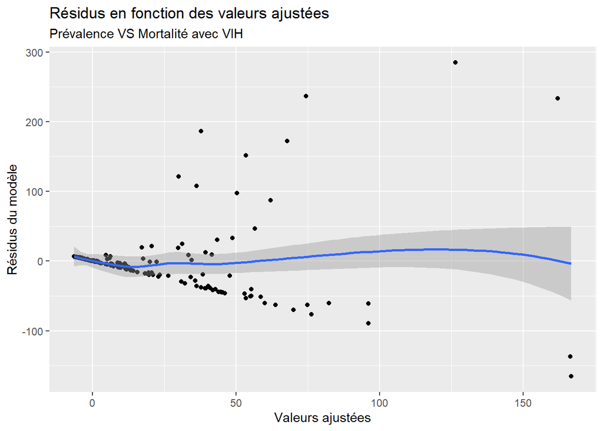

```r
ggplot() +
  # Initialise le graphique ggplot sans données spécifiques (les données seront ajoutées après avec aes())

  aes(x = fitted(mortalite_avec_vih_vs_prevalance), y = residuals(mortalite_avec_vih_vs_prevalance)) +
  # Définir les axes du graphique :
  # L'axe X représente les valeurs ajustées par le modèle de régression (prédictions des valeurs de la mortalité avec VIH).
  # L'axe Y représente les résidus du modèle (différences entre les valeurs observées et les valeurs ajustées).

  geom_point() +  # Ajout d'un nuage de points pour visualiser la relation entre les valeurs ajustées et les résidus

  geom_smooth() +  # Ajout d'une courbe lissée pour examiner la tendance générale entre les résidus et les valeurs ajustées
  # Cette courbe peut aider à identifier des relations non linéaires ou des motifs dans les erreurs du modèle.

  xlab("Valeurs ajustées") +  # Ajout d'un label pour l'axe X : "Valeurs ajustées"

  ylab("Résidus du modèle") +  # Ajout d'un label pour l'axe Y : "Résidus du modèle"

  ggtitle("Résidus en fonction des valeurs ajustées", subtitle = "Prévalence VS Mortalité avec VIH")
```

```r
  # Ajout du titre du graphique : "Résidus en fonction des valeurs ajustées"
  # Le sous-titre indique que le graphique montre la relation entre la prévalence de la tuberculose et la mortalité avec VIH
```

La courbe lissée (geom_smooth) indique une forme non linéaire des résidus par rapport aux valeurs ajustées. Cela suggère qu’un modèle linéaire ne s’adapte pas parfaitement aux données, car les erreurs de prédiction ne sont pas distribuées de manière homogène à travers les différentes valeurs ajustées.

#### Qqplot

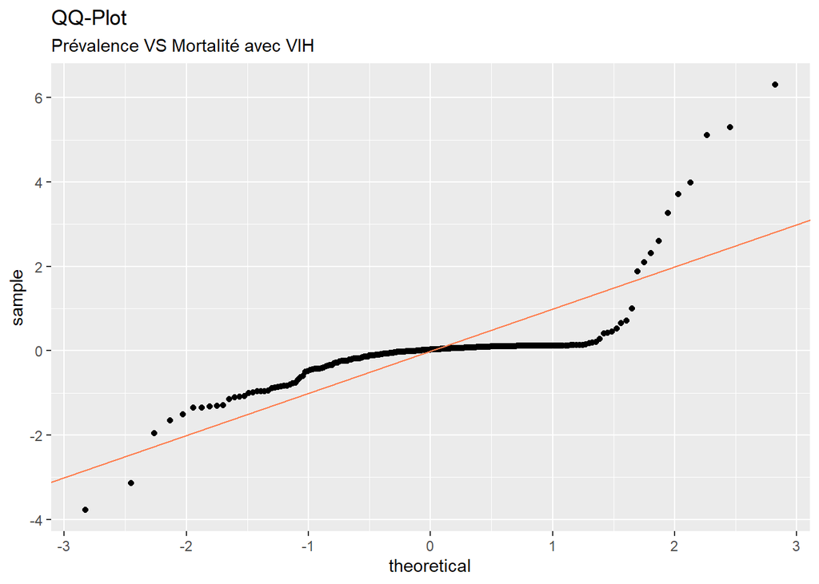

```r
ggplot() +
  # Initialise le graphique ggplot sans données spécifiques (les données seront ajoutées après avec aes())

  geom_qq(aes(sample = rstandard(mortalite_avec_vih_vs_prevalance))) +
  # Ajout d'un QQ-Plot pour visualiser la distribution des résidus standardisés du modèle de régression
  # `rstandard(mortalite_avec_vih_vs_prevalance)` calcule les résidus standardisés (résidus divisés par l'écart-type des résidus)
  # Le QQ-Plot permet de vérifier si les résidus suivent une distribution normale.

  geom_abline(color = "coral") +
  # Ajout d'une ligne de référence (abline) pour vérifier la normalité
  # Cette ligne droite représente la distribution normale théorique (si les points sont proches de cette ligne, cela suggère une distribution normale des résidus)
  # La couleur "coral" est utilisée pour la ligne de référence.

  ggtitle("QQ-Plot", subtitle = "Prévalence VS Mortalité avec VIH")
```

```r
  # Ajout du titre du graphique : "QQ-Plot"
  # Le sous-titre précise que le graphique montre la relation entre la prévalence de la tuberculose et la mortalité avec VIH
```

Le QQ-plot montre la distribution des résidus de notre modèle de régression par rapport à une distribution normale théorique.

#### Scale-location (position-échelle)

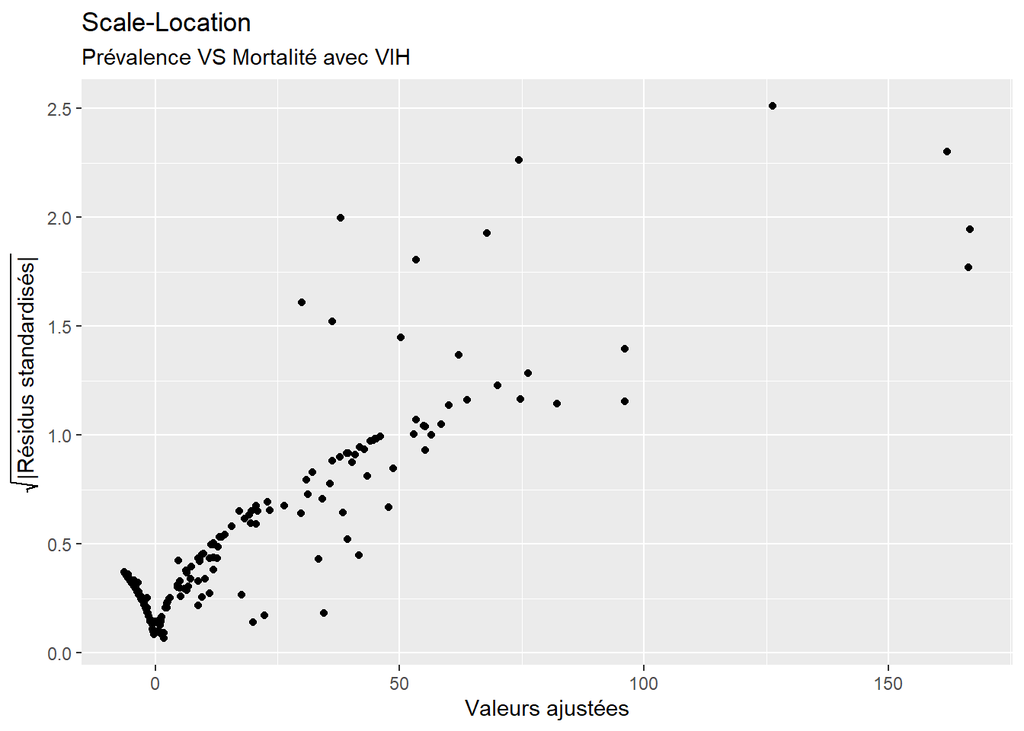

```r
ggplot() +
  # Initialise le graphique ggplot sans données spécifiques (les données seront ajoutées après avec aes())

  aes(x = fitted(mortalite_avec_vih_vs_prevalance), y = sqrt(abs(rstandard(mortalite_avec_vih_vs_prevalance)))) +
  # `aes()` définit les axes du graphique :
  # L'axe des x : `fitted(mortalite_avec_vih_vs_prevalance)` représente les valeurs ajustées du modèle de régression
  # L'axe des y : `sqrt(abs(rstandard(mortalite_avec_vih_vs_prevalance)))` calcule la racine carrée des résidus standardisés absolus.
  # Cette transformation est utilisée pour mieux visualiser les écarts en termes de dispersion et de variance des erreurs.

  geom_point()  +
  # Ajout des points du nuage de points. Chaque point représente une observation avec ses valeurs ajustées et la racine carrée des résidus standardisés.

  xlab("Valeurs ajustées") +
  # Ajout du label à l'axe des x : "Valeurs ajustées"

  ylab(expression(sqrt("|Résidus standardisés|"))) +
  # Ajout du label à l'axe des y : "√(|Résidus standardisés|)" avec une transformation pour exprimer les résidus en termes d'écart par rapport à la moyenne.

  ggtitle("Scale-Location", subtitle = "Prévalence VS Mortalité avec VIH")
```

```r
  # Ajout du titre principal "Scale-Location" pour indiquer que ce graphique examine l'échelle des résidus standardisés en fonction des valeurs ajustées.
  # Le sous-titre spécifie que l'analyse concerne la prévalence de la tuberculose et la mortalité avec VIH.
```

Ce graphique montre la relation entre les valeurs ajustées (prédictions du modèle) et les résidus standardisés (échelles transformées par la racine carrée des résidus absolus). Cela permet d’examiner si l’hypothèse d’homoscédasticité (variance constante des résidus) est respectée.

#### Distance de cook

```r
# Calcul de la distance de Cook
cooks_dist <- cooks.distance(mortalite_avec_vih_vs_prevalance)

# Définir un seuil pour identifier les points outliers
seuil_cooks <- 4 / length(cooks_dist)

# Identifier les indices des points qui dépassent le seuil
outliers_indices <- which(cooks_dist > seuil_cooks)

# Extraire les pays correspondants aux outliers
outliers_pays <- TB2_2000$Country_or_territory_name[outliers_indices]

# Afficher les pays des outliers
print(outliers_pays)
```

```
##  [1] "Azerbaijan"                       "Bhutan"
##  [3] "Botswana"                         "Cambodia"
##  [5] "Central African Republic"         "Djibouti"
##  [7] "Gabon"                            "Lao People's Democratic Republic"
##  [9] "Lesotho"                          "Malawi"
## [11] "Mozambique"                       "Myanmar"
## [13] "Namibia"                          "Philippines"
## [15] "Swaziland"                        "Zambia"
## [17] "Zimbabwe"
```

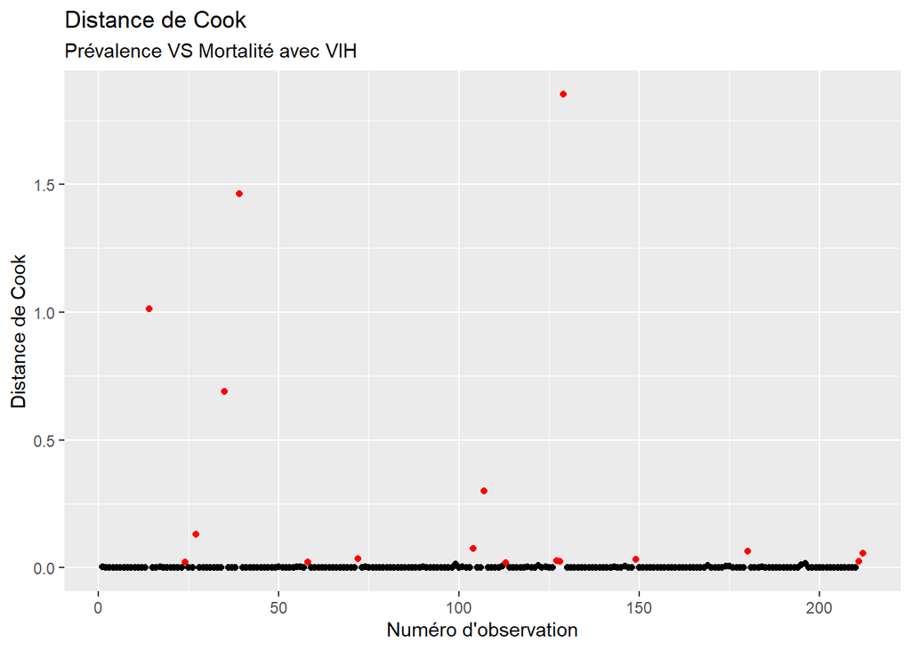

```r
# Afficher la distance de Cook avec les outliers en rouge
ggplot() +
  aes(x = seq_along(cooks_dist), y = cooks_dist) +
  geom_point() +
  geom_point(data = data.frame(x = outliers_indices, y = cooks_dist[outliers_indices]),
             aes(x = x, y = y), colour = "red") + # Points outliers en rouge
  xlab("Numéro d'observation") +
  ylab("Distance de Cook") +
  ggtitle("Distance de Cook", subtitle = "Prévalence VS Mortalité avec VIH")
```

Ce graphique montre la distance de Cook pour chaque observation dans le modèle de régression, ce qui permet d’identifier les observations qui ont une influence excessive sur les coefficients du modèle.

Les outliers sont : Azerbaijan, Bhutan, Botswana, Cambodia, Central African Republic, Djibouti, Gabon, Lao People’s Democratic Republic, Lesotho, Malawi, Mozambique, Myanmar, Namibia, Philippines, Swaziland, Zambia, Zimbabwe

Les pays identifiés dans les points influents (comme le Botswana, Cambodia, Lesotho, etc.) appartiennent à des régions à la fois en Afrique et en Asie du Sud-Est. Ces pays peuvent avoir des caractéristiques économiques, sanitaires ou structurelles uniques qui expliquent leur forte influence sur le modèle. Par exemple, ces pays pourraient avoir des niveaux de prévalence ou de mortalité atypiques qui ne sont pas représentatifs des autres pays du jeu de données. Ils méritent donc d’être examinés pour déterminer s’ils constituent des outliers ou s’ils reflètent une véritable tendance dans les données.

La présence de ces points influents pourrait indiquer que le modèle linéaire ne capture pas entièrement la complexité des relations entre la prévalence et la mortalité avec VIH, ou qu’il y a des problèmes d’hétéroscédasticité ou de distribution non linéaire. Il serait pertinent de tester d’autres modèles, peut-être non linéaires ou de type robustes, pour voir si cela améliore la précision des prédictions.

Bien que ces points influents n’invalident pas nécessairement le modèle, il est important de les examiner de plus près

#### Residual versus leverage

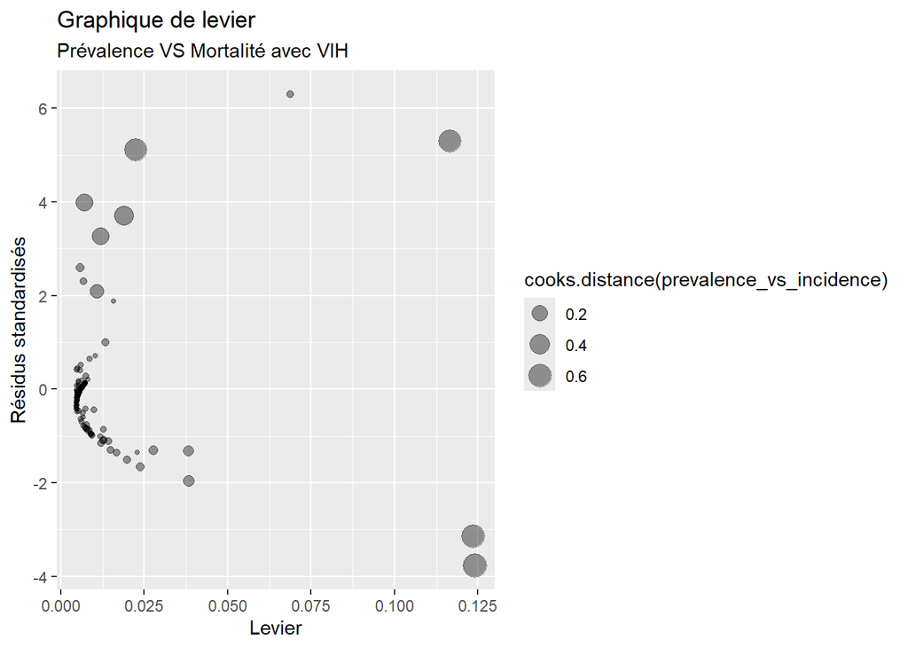

```r
ggplot() +
  # Initialise le graphique ggplot sans données spécifiques (les données seront ajoutées après avec aes())

  aes(x = hatvalues(mortalite_avec_vih_vs_prevalance), y = rstandard(mortalite_avec_vih_vs_prevalance)) +
  # `aes()` définit les axes du graphique :
  # L'axe des x : `hatvalues(mortalite_avec_vih_vs_prevalance)` représente les **leviers** (influence de chaque point sur les valeurs ajustées du modèle).
  # L'axe des y : `rstandard(mortalite_avec_vih_vs_prevalance)` représente les **résidus standardisés**, qui mesurent l'écart entre les valeurs observées et les valeurs ajustées.

  geom_point(aes(size=cooks.distance(prevalence_vs_incidence)), alpha=0.4)  +
  # `geom_point()` ajoute les points du nuage de points au graphique.
  # `aes(size=cooks.distance(prevalence_vs_incidence))` ajuste la taille des points en fonction de la **distance de Cook**, ce qui montre l'influence de chaque observation sur les paramètres du modèle.
  # `alpha=0.4` rend les points légèrement transparents pour mieux visualiser les superpositions des points.

  xlab("Levier") +
  # Ajoute le label de l'axe des x : "Levier" pour indiquer que l'axe représente le levier, une mesure de l'influence de chaque observation sur les valeurs ajustées du modèle.

  ylab("Résidus standardisés") +
  # Ajoute le label de l'axe des y : "Résidus standardisés" pour indiquer que l'axe représente les erreurs normalisées (résidus) du modèle.

  ggtitle("Graphique de levier", subtitle="Prévalence VS Mortalité avec VIH")
```

```r
  # Ajoute un titre principal "Graphique de levier" pour spécifier que ce graphique examine le levier de chaque observation en fonction des résidus standardisés.
  # Le sous-titre "Prévalence VS Mortalité avec VIH" précise que le graphique concerne la relation entre la prévalence et la mortalité avec VIH.
```

Le graphique de levier montre la relation entre les résidus standardisés et les leviers. Les leviers élevés indiquent des points qui ont un grand impact sur le modèle en raison de leur position extrême dans l’espace des variables explicatives (ici, la prévalence).

Ces points peuvent être très influents pour l’estimation des coefficients du modèle, et il est important de les examiner pour voir s’ils doivent être traités différemment (exclusion, transformation des données, ou exploration d’autres modèles). En revanche, la majorité des points se trouvent près de l’axe des résidus (proches de zéro), indiquant que la plupart des observations ont une faible influence sur le modèle.

En somme, une forte prévalence de la tuberculose dans une population entraîne un risque accru de mortalité liée au VIH, en raison de la forte probabilité de co-infection entre le VIH et la tuberculose. La tuberculose devient une cause majeure de décès parmi les personnes vivant avec le VIH, en particulier dans les régions où la tuberculose est courante et où les traitements sont insuffisants. Une approche intégrée de gestion du VIH et de la tuberculose est donc essentielle pour réduire la mortalité liée au VIH dans les zones à forte prévalence de la tuberculose.

## II.1.4) prévalence & mortalité sans VIH

#### covariance

```r
TB2_2000 %>%
  # Sélectionne le jeu de données 'TB2_2000' pour appliquer une transformation (à partir de dplyr).

  select(
    `Estimated_prevalence_of_TB_(all_forms)_per_100_000_population`,
    # Sélectionne la variable `Estimated_prevalence_of_TB_(all_forms)_per_100_000_population`, qui représente la prévalence de la tuberculose (tous types confondus) pour 100 000 habitants.

    `Estimated_mortality_of_TB_cases_(all_forms,_excluding_HIV)_per_100_000_population`
    # Sélectionne la variable `Estimated_mortality_of_TB_cases_(all_forms,_excluding_HIV)_per_100_000_population`, qui représente la mortalité de la tuberculose (hors VIH) pour 100 000 habitants.
  ) %>%
  # Applique un pipe (`%>%`) pour envoyer la sortie de la commande `select()` à la fonction suivante.

  cov()
```

```
##                                                                                   Estimated_prevalence_of_TB_(all_forms)_per_100_000_population
## Estimated_prevalence_of_TB_(all_forms)_per_100_000_population                                                                         79120.657
## Estimated_mortality_of_TB_cases_(all_forms,_excluding_HIV)_per_100_000_population                                                      8370.268
##                                                                                   Estimated_mortality_of_TB_cases_(all_forms,_excluding_HIV)_per_100_000_population
## Estimated_prevalence_of_TB_(all_forms)_per_100_000_population                                                                                              8370.268
## Estimated_mortality_of_TB_cases_(all_forms,_excluding_HIV)_per_100_000_population                                                                          1208.579
```

```r
  # Calcule la matrice de covariance entre les deux variables sélectionnées : la prévalence et la mortalité de la tuberculose (hors VIH).
```

La covariance positive entre la prévalence et la mortalité (hors VIH) de 8,370.27 montre qu’une augmentation de la prévalence est généralement associée à une augmentation de la mortalité. Cependant, comme la covariance est influencée par les unités de mesure des variables, pour évaluer la force et l’intensité de cette relation de manière plus fiable.

Nous allons donc de préférence calculer des mesures normalisées telles que le coefficient de corrélation.

#### Coefficient de corrélation pearson

```r
cor(
  x = TB2_2000[["Estimated_prevalence_of_TB_(all_forms)_per_100_000_population"]],
  # Sélectionne la variable `Estimated_prevalence_of_TB_(all_forms)_per_100_000_population` du jeu de données `TB2_2000`, représentant la prévalence de la tuberculose (tous types confondus) pour 100 000 habitants.

  y = TB2_2000[["Estimated_mortality_of_TB_cases_(all_forms,_excluding_HIV)_per_100_000_population"]],
  # Sélectionne la variable `Estimated_mortality_of_TB_cases_(all_forms,_excluding_HIV)_per_100_000_population` du jeu de données `TB2_2000`, représentant la mortalité de la tuberculose (hors VIH) pour 100 000 habitants.

  method = "pearson"
  # Spécifie la méthode de calcul de la corrélation : ici, la méthode de Pearson
)
```

```
## [1] 0.8559669
```

#### Coefficient de corrélation Spearman

```r
cor(
  x = TB2_2000[["Estimated_prevalence_of_TB_(all_forms)_per_100_000_population"]],
  # Sélectionne la variable `Estimated_prevalence_of_TB_(all_forms)_per_100_000_population` du jeu de données `TB2_2000`, représentant la prévalence de la tuberculose (tous types confondus) pour 100 000 habitants.

  y = TB2_2000[["Estimated_mortality_of_TB_cases_(all_forms,_excluding_HIV)_per_100_000_population"]],
  # Sélectionne la variable `Estimated_mortality_of_TB_cases_(all_forms,_excluding_HIV)_per_100_000_population` du jeu de données `TB2_2000`, représentant la mortalité de la tuberculose (hors VIH) pour 100 000 habitants.

  method = "spearman"
  # Spécifie la méthode de calcul de la corrélation : ici, la méthode de Spearman

)
```

```
## [1] 0.9274942
```

Un coefficient de Pearson de 0.856 indique une relation forte et linéaire positive entre la prévalence de la tuberculose et la mortalité de la tuberculose (toutes formes, excluant VIH). Cela signifie qu’à mesure que la prévalence augmente, la mortalité associée augmente de manière relativement linéaire. La valeur proche de 1 suggère que la relation linéaire entre ces deux variables est bien définie et significative.

Un coefficient de 0.927 pour Spearman indique une relation monotone très forte entre la prévalence et la mortalité. Cela signifie que, bien que la relation ne soit pas nécessairement linéaire, il existe une tendance claire où, à mesure que la prévalence augmente, la mortalité a tendance à augmenter aussi. Ce coefficient est légèrement plus élevé que celui de Pearson, ce qui montre que même si la relation n’est pas strictement linéaire, elle est encore extrêmement forte.

Dans les deux cas, la prévalence et la mortalité sans VIH sont fortement corrélées, avec Spearman indiquant une relation particulièrement robuste en termes de monotonie.

#### Nuage de points

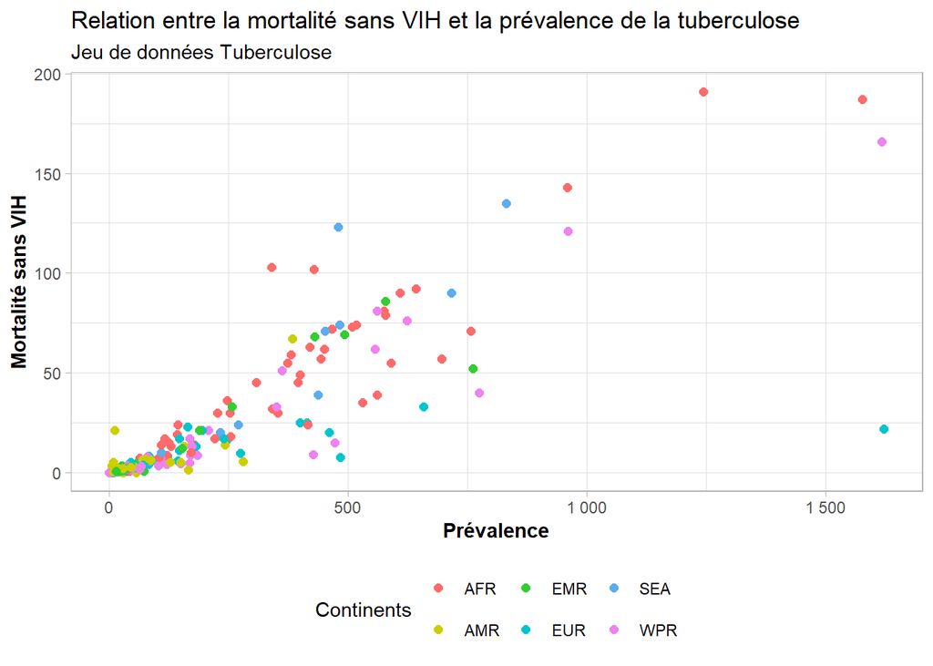

```r
# Définir une palette de couleurs fixe pour les régions
region_colors <- c("AFR" = "indianred1", "AMR" = "yellow3", "EMR" = "limegreen",
                   "EUR" = "turquoise3", "SEA" = "steelblue2", "WPR" = "violet")
# Cette ligne définit une palette de couleurs personnalisées pour chaque région (AFR, AMR, EMR, EUR, SEA, WPR) avec des couleurs spécifiques.


# 1) Nuage de points avec tous les continents :
ggplot(TB2_2000) +  # Commence une nouvelle visualisation ggplot pour le jeu de données TB2_2000

  aes(x = `Estimated_prevalence_of_TB_(all_forms)_per_100_000_population`,
      y = `Estimated_mortality_of_TB_cases_(all_forms,_excluding_HIV)_per_100_000_population`,
      colour = Region) +  # Définir les axes x et y (prévalence et mortalité sans VIH), et utiliser la variable Region pour colorier les points

  geom_point(size = 2) +  # Ajouter des points de taille 2 sur le graphique

  scale_colour_manual(values = region_colors) +  # Appliquer la palette de couleurs définie précédemment aux différentes régions

  labs(  # Ajouter des labels aux axes et à la légende de couleur
    x = "Prévalence",
    y = "Mortalité sans VIH",
    colour = "Continents"
  ) +

  ggtitle("Relation entre la mortalité sans VIH et la prévalence de la tuberculose",
          subtitle = "Jeu de données Tuberculose") +  # Ajouter un titre principal et un sous-titre

  scale_x_continuous(labels =scales::label_number(decimal.mark = ",")) +  # Formater l'axe X pour utiliser la virgule comme séparateur décimal

  scale_y_continuous(labels =scales::label_number(decimal.mark = ",")) +  # Formater l'axe Y pour utiliser la virgule comme séparateur décimal

  guides(color = guide_legend(nrow = 2)) +  # Modifier la légende pour afficher les couleurs sur 2 lignes

  theme_light() +  # Appliquer un fond clair au graphique

  theme(  # Modifier certains aspects du thème
    legend.position = "bottom",  # Placer la légende en bas du graphique
    axis.title = element_text(face = "bold")  # Mettre les titres des axes en gras
  )
```

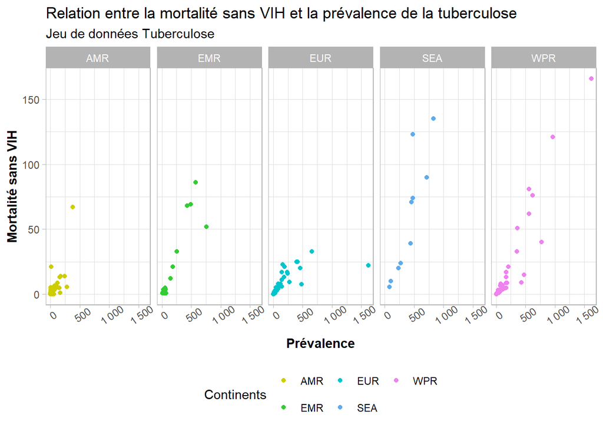

```r
# 2) Nuage de points sans la région AFR (Afrique) :
ggplot(TB2_2000 %>% filter(Region != "AFR")) +  # Filtrer les données pour exclure les observations de la région "AFR" (Afrique)

  aes(x = `Estimated_prevalence_of_TB_(all_forms)_per_100_000_population`,
      y = `Estimated_mortality_of_TB_cases_(all_forms,_excluding_HIV)_per_100_000_population`,
      colour = Region) +  # Définir les axes x et y (prévalence et mortalité sans VIH) et colorier les points par région

  geom_point() +  # Ajouter des points au graphique

  scale_colour_manual(values = region_colors) +  # Appliquer la palette de couleurs définie précédemment

  labs(  # Ajouter des labels aux axes et à la légende de couleur
    x = "Prévalence",
    y = "Mortalité sans VIH",
    colour = "Continents"
  ) +

  ggtitle("Relation entre la mortalité sans VIH et la prévalence de la tuberculose",
          subtitle = "Jeu de données Tuberculose") +  # Ajouter un titre principal et un sous-titre

  scale_x_continuous(labels =scales::label_number(decimal.mark = ",")) +  # Formater l'axe X pour utiliser la virgule comme séparateur décimal

  scale_y_continuous(labels =scales::label_number(decimal.mark = ",")) +  # Formater l'axe Y pour utiliser la virgule comme séparateur décimal

  facet_grid(cols = vars(Region)) +  # Créer des sous-graphiques pour chaque région

  guides(color = guide_legend(nrow = 2)) +  # Modifier la légende pour afficher les couleurs sur 2 lignes

  theme_light() +  # Appliquer un fond clair au graphique

  theme(  # Modifier certains aspects du thème

    legend.position = "bottom",  # Placer la légende en bas du graphique

    axis.title = element_text(face = "bold"),  # Mettre les titres des axes en gras

    axis.text.x = element_text(angle = 35)  # Faire pivoter les labels de l'axe X de 35 degrés
  )
```

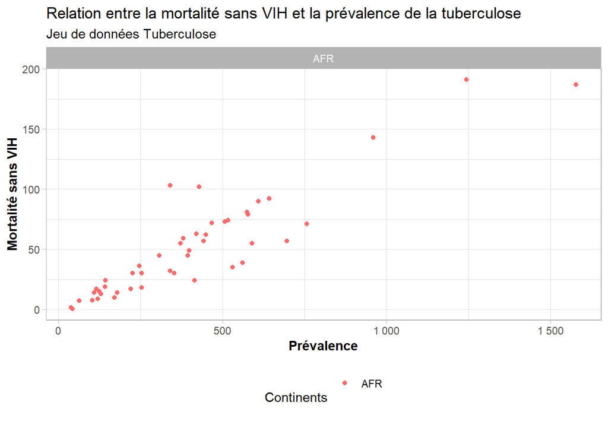

```r
# 3) Nuage de points uniquement pour la région AFR (Afrique) :

ggplot(TB2_2000 %>% filter(Region == "AFR")) +  # Filtrer les données pour ne garder que celles de la région "AFR" (Afrique)

  aes(x = `Estimated_prevalence_of_TB_(all_forms)_per_100_000_population`,
      y = `Estimated_mortality_of_TB_cases_(all_forms,_excluding_HIV)_per_100_000_population`,
      colour = Region) +  # Définir les axes x et y (prévalence et mortalité sans VIH) et colorier les points par région

  geom_point() +  # Ajouter des points au graphique

  scale_colour_manual(values = region_colors) +  # Appliquer la palette de couleurs définie précédemment

  labs(  # Ajouter des labels aux axes et à la légende de couleur
    x = "Prévalence",
    y = "Mortalité sans VIH",
    colour = "Continents"
  ) +

  ggtitle("Relation entre la mortalité sans VIH et la prévalence de la tuberculose",
          subtitle = "Jeu de données Tuberculose") +  # Ajouter un titre principal et un sous-titre

  scale_x_continuous(labels =scales::label_number(decimal.mark = ",")) +  # Formater l'axe X pour utiliser la virgule comme séparateur décimal

  scale_y_continuous(labels =scales::label_number(decimal.mark = ",")) +  # Formater l'axe Y pour utiliser la virgule comme séparateur décimal

  facet_grid(cols = vars(Region)) +  # Créer des sous-graphiques pour chaque région

  guides(color = guide_legend(nrow = 2)) +  # Modifier la légende pour afficher les couleurs sur 2 lignes

  theme_light() +  # Appliquer un fond clair au graphique

  theme(  # Modifier certains aspects du thème
    legend.position = "bottom",  # Placer la légende en bas du graphique

    axis.title = element_text(face = "bold")  # Mettre les titres des axes en gras
  )
```

On observe directement qu’il y a une forte relation entre la prévalence et la mortalité sans VIH, notamment par le fait que les points sont alignés autour d’une droite. Cela témoigne de nos calculs de coefficients juste avant proche de 1 : la prévalence et la mortalité sans VIH sont fortement corrélées.

Ces nuages de points confirment une relation forte entre prévalence et mortalité en tuberculose, particulièrement dans les zones les plus touchées, comme l’Afrique et l’Asie du Sud-Est. Ces régions sont confrontées à des inégalités sanitaires profondes exacerbées par des systèmes de santé fragiles, des facteurs socio-économiques difficiles, et une forte co-infection VIH, tandis que les pays plus développés montrent de meilleures performances en termes de contrôle de la tuberculose et du VIH. L’analyse souligne donc l’importance d’une approche ciblée pour adresser les défis spécifiques de chaque région, notamment à travers le renforcement des infrastructures sanitaires, l’amélioration de l’accès aux soins et des politiques de santé publique adaptées.

#### Regression linéaire

```r
# Créer un modèle de régression linéaire entre la mortalité sans VIH et la prévalence de la tuberculose

mortalite_sans_vih_vs_prevalance <- TB2_2000 %>%  # On utilise le jeu de données TB2_2000

  lm(`Estimated_mortality_of_TB_cases_(all_forms,_excluding_HIV)_per_100_000_population` ~  # Variable dépendante : mortalité sans VIH

       `Estimated_prevalence_of_TB_(all_forms)_per_100_000_population`,  # Variable indépendante : prévalence
     data = .)  # Les données utilisées sont celles du tableau TB2_2000

# Résumé du modèle
summary(mortalite_sans_vih_vs_prevalance)  # Affiche un résumé des résultats du modèle de régression linéaire
```

```
##
## Call:
## lm(formula = `Estimated_mortality_of_TB_cases_(all_forms,_excluding_HIV)_per_100_000_population` ~
##     `Estimated_prevalence_of_TB_(all_forms)_per_100_000_population`,
##     data = .)
##
## Residuals:
##      Min       1Q   Median       3Q      Max
## -149.365   -3.705   -0.706    0.900   72.660
##
## Coefficients:
##                                                                 Estimate
## (Intercept)                                                     -0.33433
## `Estimated_prevalence_of_TB_(all_forms)_per_100_000_population`  0.10579
##                                                                 Std. Error
## (Intercept)                                                        1.54896
## `Estimated_prevalence_of_TB_(all_forms)_per_100_000_population`    0.00441
##                                                                 t value
## (Intercept)                                                      -0.216
## `Estimated_prevalence_of_TB_(all_forms)_per_100_000_population`  23.991
##                                                                 Pr(>|t|)
## (Intercept)                                                        0.829
## `Estimated_prevalence_of_TB_(all_forms)_per_100_000_population`   <2e-16 ***
## ---
## Signif. codes:  0 '***' 0.001 '**' 0.01 '*' 0.05 '.' 0.1 ' ' 1
##
## Residual standard error: 18.02 on 210 degrees of freedom
## Multiple R-squared:  0.7327, Adjusted R-squared:  0.7314
## F-statistic: 575.6 on 1 and 210 DF,  p-value: < 2.2e-16
```

Les résidus représentent la différence entre les valeurs observées et les valeurs ajustées (prédictions) par le modèle.

Le minimum des résidus est de -149.365, ce qui montre qu’il y a des erreurs de prédiction assez importantes dans certaines observations.

Le 1er quartile est de -3.705, la médiane est de -0.706, et le 3ème quartile est de 0.900. Cela montre que la majorité des erreurs de prédiction sont relativement faibles et proches de zéro.

Le maximum est de 72.660, ce qui indique qu’il existe des erreurs de prédiction assez importantes dans certaines observations (outliers possibles).

On peut conclure que les résidus sont relativement éparpillés, ce qui montre qu’il y a une variabilité dans les erreurs de prédiction. Cependant, cette dispersion ne semble pas être excessivement biaisée, car la médiane est proche de zéro et la majorité des valeurs se trouvent autour de zéro. Cela suggère que le modèle est relativement bien ajusté, même si des points influents ou des outliers existent.

La mortalité de la tuberculose (toutes formes, excluant VIH) est positivement liée à la prévalence de la tuberculose (toutes formes). Pour chaque augmentation de 1 décès par 100 000 habitants dans la prévalence de la tuberculose, la mortalité de la tuberculose (excluant le VIH) augmente de 0.10579 décès par 100 000 habitants.

Le modèle explique 73.27% de la variance dans la mortalité de la tuberculose (excluant le VIH), ce qui montre que la prévalence est un facteur très important pour prédire la mortalité dans ce modèle.

Le F-statistic est élevé (575.6) avec une p-value très faible (< 2.2e-16), indiquant que le modèle est globalement significatif et que la relation entre les deux variables est robuste.

En somme, la prévalence de la tuberculose (toutes formes) est un prédicteur significatif de la mortalité de la tuberculose (excluant le VIH) dans la population générale, avec un modèle qui explique 73.27% de la variance de la mortalité. La relation entre ces deux variables est forte et significative.

#### Résidus versus valeurs ajustées

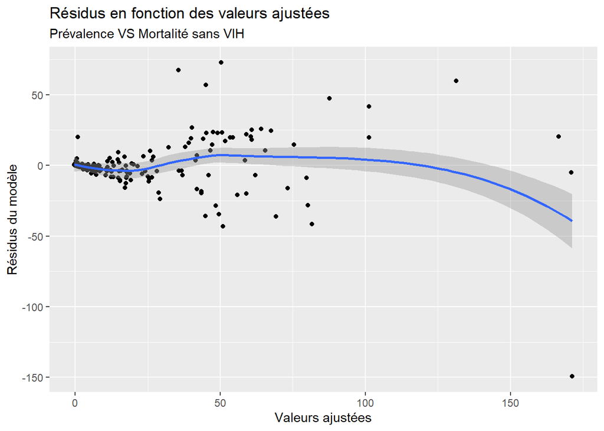

```r
# Créer un graphique de résidus en fonction des valeurs ajustées du modèle de régression
ggplot() +  # Initialisation de ggplot sans données, les données seront spécifiées dans aes()

  aes(x = fitted(mortalite_sans_vih_vs_prevalance ), y = residuals(mortalite_sans_vih_vs_prevalance )) +  # Spécifie les axes : valeurs ajustées sur l'axe des X, résidus du modèle sur l'axe des Y

  geom_point() +  # Trace un nuage de points pour chaque paire (valeur ajustée, résidu)

  geom_smooth() +  # Ajoute une courbe lissée pour visualiser la tendance générale des résidus

  xlab("Valeurs ajustées") +  # Légende de l'axe des X : "Valeurs ajustées" représente les prédictions du modèle

  ylab("Résidus du modèle") +  # Légende de l'axe des Y : "Résidus du modèle" représente l'écart entre les valeurs observées et prédites par le modèle

  ggtitle("Résidus en fonction des valeurs ajustées", subtitle = "Prévalence VS Mortalité sans VIH")  # Titre du graphique et sous-titre pour préciser le contexte
```

Ce graphique représente les résidus en fonction des valeurs ajustées (prédictions du modèle de régression), dans le cadre de l’analyse de la relation entre la prévalence et la mortalité sans VIH.

#### Qplot

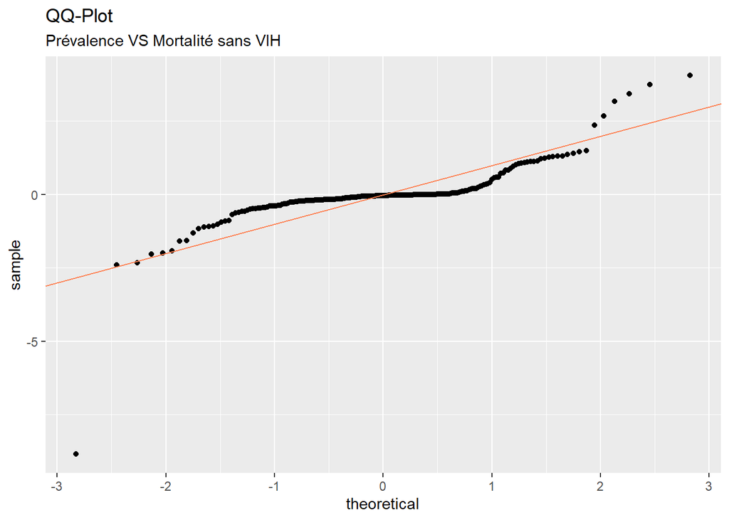

```r
# Créer un QQ-plot pour vérifier la normalité des résidus du modèle de régression
ggplot() +  # Initialisation de ggplot sans données, les données seront spécifiées dans aes()

  geom_qq(aes(sample=rstandard(mortalite_sans_vih_vs_prevalance))) +  # Trace un QQ-plot en utilisant les résidus standardisés du modèle, 'rstandard()' est une fonction qui renvoie les résidus standardisés du modèle

  geom_abline(color="coral") +  # Ajoute une droite de la normalité, en couleur "coral", pour aider à évaluer l'alignement des points avec la normale

  ggtitle("QQ-Plot", subtitle="Prévalence VS Mortalité sans VIH")  # Ajoute un titre principal au graphique et un sous-titre pour clarifier que l'on analyse la relation entre la prévalence et la mortalité sans VIH
```

Ce graphique représente un QQ-plot des résidus de votre modèle de régression, comparés à une distribution normale théorique.

Cependant, les points commencent à s’éloigner de la droite aux extrémités (c’est-à-dire dans les valeurs négatives et positives élevées), ce qui suggère que les queues de la distribution des résidus sont plus lourdes que ce que l’on attendrait d’une distribution normale. Cela peut indiquer une asymétrie ou la présence de valeurs extrêmes (outliers).

Les écarts aux extrémités peuvent avoir un impact important sur les tests statistiques. Des valeurs extrêmes peuvent déformer l’ajustement du modèle et influencer la significativité des résultats. Il peut être utile d’examiner ces outliers plus attentivement.

Le QQ-plot suggère donc que les résidus de la régression suivent une distribution normale dans l’ensemble, mais les outliers et les queues lourdes indiquent qu’il pourrait y avoir des anomalies qui influencent les résultats du modèle. Nous allons donc examiner de plus près ces points extrêmes :

#### Scale-location (position-échelle)

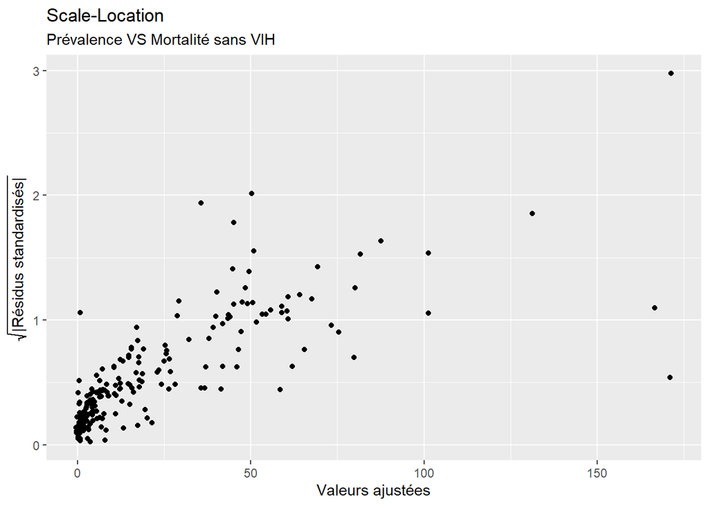

```r
# Création d'un graphique Scale-Location pour analyser l'homoscédasticité des résidus du modèle de régression

ggplot() +
  # Initialisation de ggplot sans données, les données sont spécifiées dans aes()

  aes(x = fitted(mortalite_sans_vih_vs_prevalance),
      # L'axe X représente les valeurs ajustées (prédictions du modèle)
      y = sqrt(abs(rstandard(mortalite_sans_vih_vs_prevalance)))) +
  # L'axe Y représente la racine carrée des résidus standardisés (abs(rstandard())), cette transformation aide à mieux visualiser la dispersion des résidus

  geom_point()  +
  # Ajoute les points du graphique pour chaque observation

  xlab("Valeurs ajustées") +  # Titre de l'axe des X : "Valeurs ajustées", représentant les prédictions du modèle

  ylab(expression(sqrt("|Résidus standardisés|"))) +
  # Titre de l'axe des Y : Racine carrée des résidus standardisés, cette expression permet de visualiser l'impact des erreurs absolues

  ggtitle("Scale-Location", subtitle="Prévalence VS Mortalité sans VIH")
```

```r
# Ajoute un titre principal ("Scale-Location") et un sous-titre clarifiant qu'il s'agit de la relation entre la prévalence et la mortalité sans VIH
```

Ce graphique examine l’homoscédasticité en représentant les résidus standardisés en fonction des valeurs ajustées, transformées par la racine carrée, afin de vérifier si la variance des erreurs reste constante.

#### Distance de cook

```r
# Calcul de la distance de Cook pour le modèle de régression
cooks_dist <- cooks.distance(mortalite_sans_vih_vs_prevalance)
# Utilise la fonction `cooks.distance()` pour calculer la distance de Cook pour chaque observation dans le modèle de régression.

# Définir un seuil pour identifier les points outliers
seuil_cooks <- 4 / length(cooks_dist)
# Le seuil pour identifier les points influents est défini comme 4/n, où n est le nombre total d'observations.
# C'est un critère généralement utilisé pour identifier les points ayant une influence importante sur les estimations du modèle.

# Identifier les indices des points qui dépassent le seuil
outliers_indices <- which(cooks_dist > seuil_cooks)
# La fonction `which()` est utilisée pour extraire les indices des observations dont la distance de Cook dépasse le seuil défini précédemment.
# Ces points sont considérés comme des outliers, ayant une influence anormale sur le modèle.

# Extraire les pays correspondants aux outliers
outliers_pays <- TB2_2000$Country_or_territory_name[outliers_indices]
# Utilise les indices des outliers pour extraire les pays associés à ces observations dans le jeu de données `TB2_2000`.
# Les pays correspondant aux points influents sont stockés dans la variable `outliers_pays`.

# Afficher les pays des outliers
print(outliers_pays)
```

```
##  [1] "Azerbaijan"
##  [2] "Central African Republic"
##  [3] "Democratic People's Republic of Korea"
##  [4] "Djibouti"
##  [5] "Ethiopia"
##  [6] "Gabon"
##  [7] "Georgia"
##  [8] "Kazakhstan"
##  [9] "Lao People's Democratic Republic"
## [10] "Myanmar"
## [11] "Namibia"
## [12] "Nigeria"
## [13] "Philippines"
```

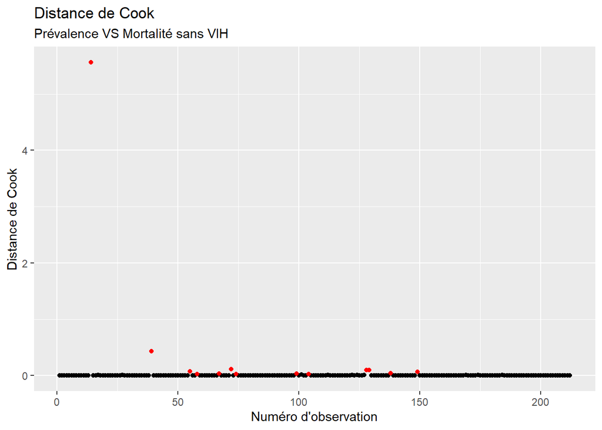

```r
# Affiche les pays dont les observations ont une influence importante sur le modèle, afin de les examiner plus en détail.

# Afficher la distance de Cook avec les outliers en rouge
ggplot() +
  # Initialise un graphique avec ggplot()
  aes(x = seq_along(cooks_dist), y = cooks_dist) +
  # Spécifie que l'axe X représente le numéro d'observation et l'axe Y la distance de Cook
  geom_point() +
  # Ajoute un nuage de points représentant la distance de Cook pour chaque observation
  geom_point(data = data.frame(x = outliers_indices, y = cooks_dist[outliers_indices]),
             aes(x = x, y = y), colour = "red") +
  # Ajoute les points outliers en rouge pour les distinguer visuellement
  xlab("Numéro d'observation") +
  # Titre de l'axe X : "Numéro d'observation"
  ylab("Distance de Cook") +
  # Titre de l'axe Y : "Distance de Cook"
  ggtitle("Distance de Cook", subtitle = "Prévalence VS Mortalité sans VIH")
```

```r
# Titre principal et sous-titre du graphique
```

Le graphique montre que la majorité des points ont des distances de Cook proches de zéro, indiquant qu’ils n’ont pas une influence disproportionnée sur le modèle.

Quelques points, représentés en rouge, ont des distances de Cook élevées : Azerbaijan, Central African Republic, Democratic People’s Republic of Korea, Djibouti, Ethiopia,Gabon,Georgia, Kazakhstan, Lao People’s Democratic Republic, “Myanmar, Namibia, Nigeria, Philippines. Ce sont des points influents, c’est-à-dire des observations qui ont un impact considérable sur la modélisation et l’estimation des paramètres.

#### Residual versus leverage

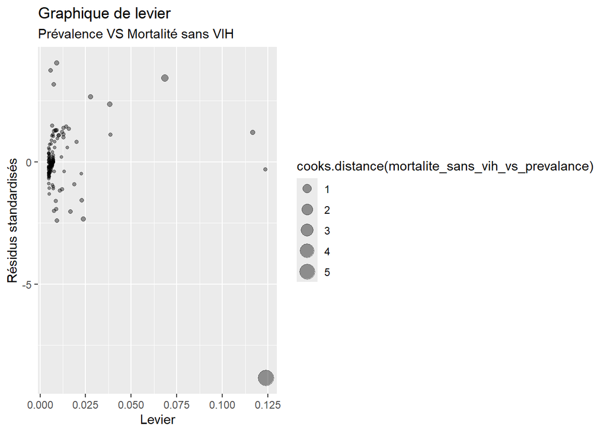

```r
ggplot() +  # Initialise un graphique avec ggplot()

  aes(x = hatvalues(mortalite_sans_vih_vs_prevalance), y = rstandard(mortalite_sans_vih_vs_prevalance)) +
  # Définit les axes : l'axe X représente le levier (influence d'une observation sur les prédictions)
  # et l'axe Y représente les résidus standardisés (erreurs normalisées du modèle).

  geom_point(aes(size = cooks.distance(mortalite_sans_vih_vs_prevalance)), alpha = 0.4) +
  # Ajoute un nuage de points. La taille des points est déterminée par la distance de Cook
  # (qui indique l'influence de chaque observation), et l'alpha (transparence) est fixé à 0.4 pour une meilleure visibilité.

  xlab("Levier") +
  # Définit le titre de l'axe X comme "Levier", qui correspond à l'influence d'une observation sur le modèle.

  ylab("Résidus standardisés") +
  # Définit le titre de l'axe Y comme "Résidus standardisés", qui représentent les erreurs de prédiction du modèle normalisées.

  ggtitle("Graphique de levier", subtitle = "Prévalence VS Mortalité sans VIH")
```

```r
  # Ajoute un titre principal "Graphique de levier" et un sous-titre expliquant que le graphique représente la relation
  # entre la prévalence et la mortalité sans VIH dans le cadre du modèle de régression.
```

Ce graphique examine la relation entre les résidus standardisés et le levier des observations dans le modèle de régression, tout en tenant compte de la distance de Cook. Il permet de détecter les points influents, à la fois en termes d’impact sur la régression (résidus) et de leur influence sur le modèle (levier).

Les points avec un levier élevé sont plus éloignés de la droite de régression, ce qui signifie qu’ils ont une forte capacité à influencer les résultats du modèle. Les grands cercles (indiquant une distance de Cook élevée) correspondent aux points les plus influents, ceux qui ont à la fois un levier élevé et un résidu important.

En revanche, la majorité des points se trouvent près de l’axe des résidus (proches de zéro), indiquant que la plupart des observations ont une faible influence sur le modèle. Ces points influents, ayant un impact sur la pente et les estimations du modèle, nécessitent une vérification plus approfondie pour s’assurer qu’ils ne biaisent pas les résultats.

En somme, dans les régions où la prévalence de la tuberculose est élevée, la mortalité sans VIH sera souvent plus importante. Cela est dû à un plus grand nombre de personnes atteintes de tuberculose qui ne sont pas correctement traitées ou qui développent des formes résistantes de la maladie, conduisant à un taux de mortalité plus élevé. La gestion efficace de la tuberculose dans ces régions nécessite un diagnostic rapide, un traitement approprié, et des mesures préventives pour réduire la transmission et la progression de la maladie.

## II.1.5) incidence & mortalité avec VIH

#### Covariance

```r
TB2_2000 %>%
  select(`Estimated_incidence_(all_forms)_per_100_000_population`,
         `Estimated_mortality_of_TB_cases_who_are_HIV-positive,_per_100_000_population`) %>%
  # Sélectionne les colonnes pour l'incidence et la mortalité des cas de tuberculose avec VIH.

  cov()
```

```
##                                                                              Estimated_incidence_(all_forms)_per_100_000_population
## Estimated_incidence_(all_forms)_per_100_000_population                                                                    43704.066
## Estimated_mortality_of_TB_cases_who_are_HIV-positive,_per_100_000_population                                               9669.466
##                                                                              Estimated_mortality_of_TB_cases_who_are_HIV-positive,_per_100_000_population
## Estimated_incidence_(all_forms)_per_100_000_population                                                                                           9669.466
## Estimated_mortality_of_TB_cases_who_are_HIV-positive,_per_100_000_population                                                                     3082.145
```

```r
  # Calcule la matrice de covariance entre l'incidence et la mortalité liée au VIH,
  # mesurant comment ces deux variables varient ensemble.
```

La covariance entre l’incidence de la tuberculose et la mortalité avec VIH est relativement élevée (9669.466), ce qui confirme l’existence d’une relation positive entre ces deux variables. Cela signifie que dans les régions où l’incidence de la tuberculose est plus élevée, la mortalité liée au VIH tend également à augmenter. Cette information est précieuse pour comprendre comment les deux phénomènes sont liés dans différentes populations.

Toutefois, la covariance seule ne nous permet pas de comparer la force de cette relation entre les variables car elle est influencée par l’unité de mesure de chaque variable. Pour avoir une mesure normalisée de la force de cette relation, nous allons de préférence calculer les coefficients de corrélation Pearson et Spearman.

#### Coefficient de corrélation pearson

```r
cor(x = TB2_2000[["Estimated_incidence_(all_forms)_per_100_000_population"]],
    # Sélectionne la colonne de l'incidence de la tuberculose.

    y = TB2_2000[["Estimated_mortality_of_TB_cases_who_are_HIV-positive,_per_100_000_population"]],
    # Sélectionne la colonne de la mortalité liée au VIH.

    method = "pearson")
```

```
## [1] 0.8331344
```

```r
    # Calcule le coefficient de corrélation de Pearson entre l'incidence et la mortalité avec VIH, mesurant la force et la direction de la relation linéaire entre les deux variables.
```

#### Coefficient de corrélation Spearman

```r
cor(x = TB2_2000[["Estimated_incidence_(all_forms)_per_100_000_population"]],
    # Sélectionne la colonne de l'incidence de la tuberculose.

    y = TB2_2000[["Estimated_mortality_of_TB_cases_who_are_HIV-positive,_per_100_000_population"]],
    # Sélectionne la colonne de la mortalité liée au VIH.

    method = "spearman")
```

```
## [1] 0.6803857
```

```r
    # Calcule le coefficient de corrélation de Spearman entre l'incidence et la mortalité avec VIH, mesurant la force et la direction de la relation monotone entre les deux variables.
```

Le coefficient de Pearson (0.83) montre que l’incidence et la mortalité suivent une relation très forte et linéaire, ce qui est particulièrement utile pour des analyses où une relation prévisible et continue est attendue.

Le coefficient de Spearman (0.68), bien que toujours assez élevé, montre qu’il y a des éléments de variabilité non linéaire. Cela pourrait signifier que dans certaines régions ou certains cas, la relation n’est pas parfaitement linéaire, mais globalement, les deux variables évoluent de manière similaire.

Ici, le fait que le coefficient de Pearson soit supérieur à celui de Spearman indique que la relation entre l’incidence de la tuberculose et la mortalité chez les personnes vivant avec le VIH est plus forte et linéaire que monotone, suggérant que les deux variables évoluent de manière prévisible et proportionnelle, mais avec des variations moins marquées qu’une relation monotone.

#### Nuage de points

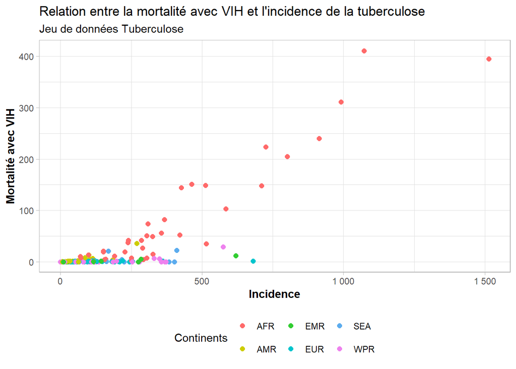

```r
# Définir une palette de couleurs fixe pour les régions
region_colors <- c("AFR" = "indianred1", "AMR" = "yellow3", "EMR" = "limegreen",
                   "EUR" = "turquoise3", "SEA" = "steelblue2", "WPR" = "violet")
# Crée un vecteur `region_colors` pour associer une couleur à chaque région.
# AFR pour l'Afrique, AMR pour l'Amérique, EMR pour la Méditerranée orientale, etc.

#1) Nuage de points avec tous les continents :
ggplot(TB2_2000) +
  aes(x = `Estimated_incidence_(all_forms)_per_100_000_population`,
      y = `Estimated_mortality_of_TB_cases_who_are_HIV-positive,_per_100_000_population`,
      colour = Region) +
  # Crée un graphique avec l'incidence en x, la mortalité avec VIH en y, et la couleur basée sur la région.

  geom_point(size = 2) +
  # Ajoute des points au graphique avec une taille définie de 2.

  scale_colour_manual(values = region_colors) +
  # Applique la palette de couleurs définie pour les régions.

  labs(
    x = "Incidence",
    y = "Mortalité avec VIH",
    colour = "Continents"
  ) +
  # Ajoute des labels pour les axes x, y et la légende de couleur.

  ggtitle("Relation entre la mortalité avec VIH et l'incidence de la tuberculose",
          subtitle = "Jeu de données Tuberculose") +
  # Ajoute un titre et un sous-titre au graphique.

  scale_x_continuous(labels =scales::label_number(decimal.mark = ",")) +
  scale_y_continuous(labels =scales::label_number(decimal.mark = ",")) +
  # Formate les axes x et y pour afficher les nombres avec des virgules comme séparateurs décimaux.

  guides(color = guide_legend(nrow = 2)) +
  # Organise la légende des couleurs sur 2 lignes.

  theme_light() +
  # Applique un thème graphique clair.

  theme(
    legend.position = "bottom",
    axis.title = element_text(face = "bold")
  )
```

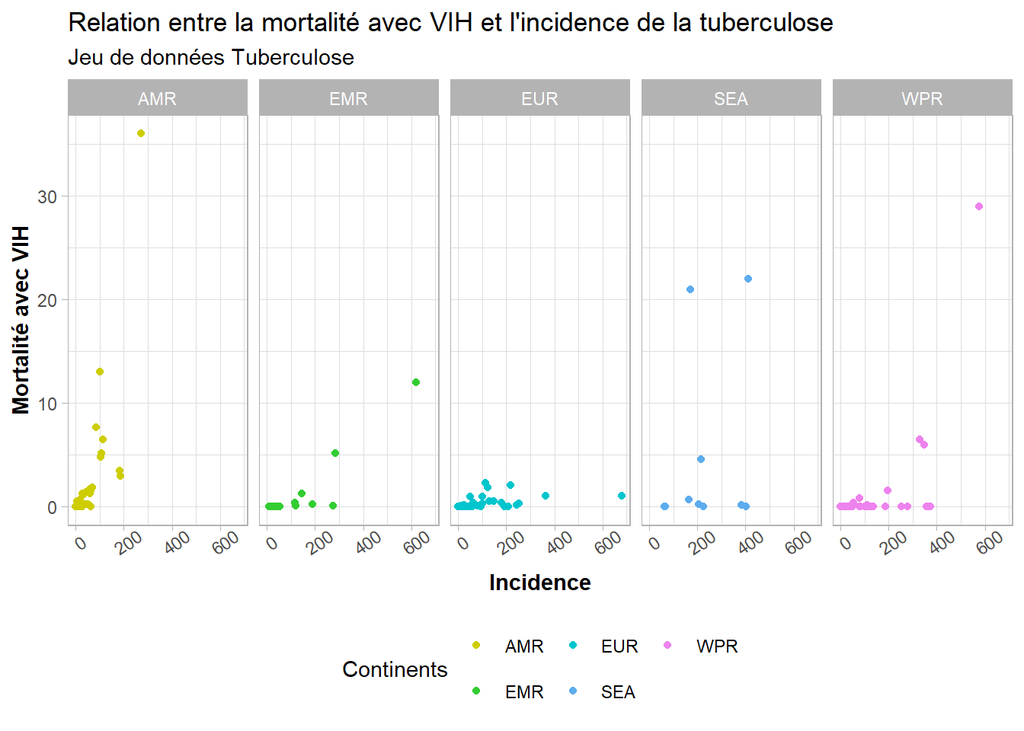

```r
  # Positionne la légende en bas et met en gras les titres des axes.

# 2) Nuage de points sans la région AFR (Afrique) :
ggplot(TB2_2000 %>% filter(Region != "AFR")) +
  aes(x = `Estimated_incidence_(all_forms)_per_100_000_population`,
      y = `Estimated_mortality_of_TB_cases_who_are_HIV-positive,_per_100_000_population`,
      colour = Region) +
  # Applique un filtre pour exclure la région AFR (Afrique).

  geom_point() +
  # Ajoute les points au graphique sans spécifier la taille (par défaut).

  scale_colour_manual(values = region_colors) +
  # Applique la palette de couleurs définie pour les régions.

  labs(
    x = "Incidence",
    y = "Mortalité avec VIH",
    colour = "Continents"
  ) +
  # Ajoute des labels pour les axes et la légende.

  ggtitle("Relation entre la mortalité avec VIH et l'incidence de la tuberculose",
          subtitle = "Jeu de données Tuberculose") +
  # Ajoute un titre et un sous-titre.

  scale_x_continuous(labels =scales::label_number(decimal.mark = ",")) +
  scale_y_continuous(labels =scales::label_number(decimal.mark = ",")) +
  # Formate les axes x et y avec des virgules comme séparateurs décimaux.

  facet_grid(cols = vars(Region)) +
  # Organise les graphiques en fonction des régions sur les colonnes.

  guides(color = guide_legend(nrow = 2)) +
  # Positionne la légende sur 2 lignes.

  theme_light() +
  # Applique un thème clair.

  theme(
    legend.position = "bottom",
    axis.title = element_text(face = "bold"),
    axis.text.x = element_text(angle = 35)
  )
```

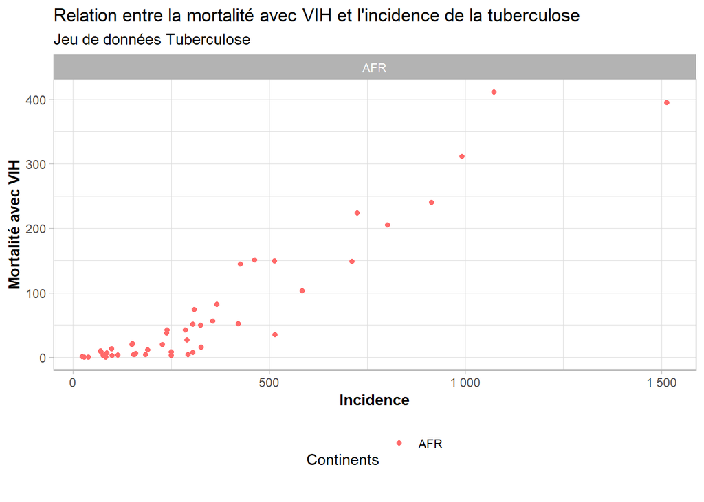

```r
  # Positionne la légende en bas, met les titres des axes en gras, et fait pivoter le texte de l'axe des x à 35°.

# 3) Nuage de points uniquement pour la région AFR (Afrique) :
ggplot(TB2_2000 %>% filter(Region == "AFR")) +
  aes(x = `Estimated_incidence_(all_forms)_per_100_000_population`,
      y = `Estimated_mortality_of_TB_cases_who_are_HIV-positive,_per_100_000_population`,
      colour = Region) +
  # Applique un filtre pour inclure uniquement la région AFR (Afrique).

  geom_point() +
  # Ajoute les points au graphique.

  scale_colour_manual(values = region_colors) +
  # Applique la palette de couleurs définie pour les régions.

  labs(
    x = "Incidence",
    y = "Mortalité avec VIH",
    colour = "Continents"
  ) +
  # Ajoute des labels pour les axes et la légende.

  ggtitle("Relation entre la mortalité avec VIH et l'incidence de la tuberculose",
          subtitle = "Jeu de données Tuberculose") +
  # Ajoute un titre et un sous-titre.

  scale_x_continuous(labels =scales::label_number(decimal.mark = ",")) +
  scale_y_continuous(labels =scales::label_number(decimal.mark = ",")) +
  # Formate les axes x et y avec des virgules comme séparateurs décimaux.

  facet_grid(cols = vars(Region)) +
  # Organise les graphiques en fonction des régions sur les colonnes.

  guides(color = guide_legend(nrow = 2)) +
  # Positionne la légende sur 2 lignes.

  theme_light() +
  # Applique un thème clair.

  theme(
    legend.position = "bottom",
    axis.title = element_text(face = "bold")
  )
```

```r
  # Positionne la légende en bas et met les titres des axes en gras.
```

On observe directement qu’il y a une forte relation entre l’incidence et la mortalité avec VIH, notamment par le fait que les points sont alignés autour d’une droite. Cela témoigne de nos calculs du coefficient de Pearson juste avant proche de 1.

Dans le premier graphique, la relation entre la mortalité avec VIH et l’incidence de la tuberculose est bien marquée, notamment pour les pays les plus fortement affectés, principalement en Afrique (indiquée par les points rouges). Il existe une relation positive : à mesure que l’incidence augmente (le nombre de nouveaux cas), la mortalité avec VIH tend également à augmenter. Les points extrêmes en haut à droite montrent des pays où l’incidence et la mortalité sont particulièrement élevées, indiquant des zones de crise sanitaire. Ce phénomène est principalement observable en Afrique, ce qui souligne la forte corrélation entre la co-infection VIH-tuberculose et la gravité de la situation sanitaire.

Ainsi, les graphiques révèlent une relation forte entre l’incidence de la tuberculose et la mortalité avec VIH, en particulier en Afrique, où les taux de mortalité sont alarmants.

#### Regression linéaire

```r
# Création du modèle de régression linéaire
mortalite_avec_vih_vs_incidence <- TB2_2000 %>%
  lm(
    `Estimated_mortality_of_TB_cases_who_are_HIV-positive,_per_100_000_population` ~
      `Estimated_incidence_(all_forms)_per_100_000_population`,
    data = .)
# Utilise la fonction `lm()` pour créer un modèle de régression linéaire où la variable dépendante est la mortalité des cas de tuberculose avec VIH
# et la variable indépendante est l'incidence de la tuberculose. Le modèle est appliqué au jeu de données `TB2_2000`.

# Affichage du résumé du modèle
summary(mortalite_avec_vih_vs_incidence)
```

```
##
## Call:
## lm(formula = `Estimated_mortality_of_TB_cases_who_are_HIV-positive,_per_100_000_population` ~
##     `Estimated_incidence_(all_forms)_per_100_000_population`,
##     data = .)
##
## Residuals:
##      Min       1Q   Median       3Q      Max
## -133.183   -9.056    6.541   13.732  189.987
##
## Coefficients:
##                                                           Estimate Std. Error
## (Intercept)                                              -16.38688    2.58580
## `Estimated_incidence_(all_forms)_per_100_000_population`   0.22125    0.01014
##                                                          t value Pr(>|t|)
## (Intercept)                                               -6.337  1.4e-09 ***
## `Estimated_incidence_(all_forms)_per_100_000_population`  21.830  < 2e-16 ***
## ---
## Signif. codes:  0 '***' 0.001 '**' 0.01 '*' 0.05 '.' 0.1 ' ' 1
##
## Residual standard error: 30.78 on 210 degrees of freedom
## Multiple R-squared:  0.6941, Adjusted R-squared:  0.6927
## F-statistic: 476.5 on 1 and 210 DF,  p-value: < 2.2e-16
```

```r
# La fonction `summary()` affiche les résultats détaillés du modèle de régression, y compris les coefficients estimés, les erreurs standards,
# les valeurs t et les p-valeurs, ainsi que les indicateurs de qualité du modèle tels que R², les résidus, etc.
```

L’Intercept (constante) est de -16.38688. Cela signifie que lorsque l’incidence de la tuberculose est nulle, la mortalité due à la tuberculose chez les personnes vivant avec le VIH serait de -16.39 décès par 100 000 habitants. C’est une valeur théorique mais pas réaliste dans ce cas.

Le coefficient de l’incidence de la tuberculose est de 0.22125. Pour chaque augmentation de 1 décès par 100 000 habitants dans l’incidence de la tuberculose, la mortalité liée au VIH augmente de 0.22 décès par 100 000 habitants. Cela suggère une relation positive : plus l’incidence de la tuberculose est élevée, plus la mortalité liée au VIH augmente dans cette population.

La p-value de la variable indépendante (incidence) est inférieure à 2.2e-16, étant très faible, elle montre que l’incidence est un prédicteur hautement significatif de la mortalité liée au VIH.

Le modèle explique environ 69.41% de la variance de la mortalité de la tuberculose chez les personnes vivant avec le VIH. Cela montre que l’incidence est un facteur important pour prédire la mortalité dans ce modèle.

L’ajustement du modèle ( 0.6927) reste relativement stable après correction pour le nombre de variables dans le modèle.

l’F-statistic est de 476.5 avec une p-value très faible (< 2.2e-16), ce qui indique que le modèle est globalement significatif et que la relation entre l’incidence de la tuberculose et la mortalité liée au VIH est robuste.

Le modèle montre ainsi que l’incidence de la tuberculose est un prédicteur très significatif de la mortalité liée au VIH dans la population générale. Le modèle explique 69.41% de la variance de la mortalité, ce qui en fait un bon ajustement, mais il reste une partie de la variance non expliquée. Le coefficient de l’incidence montre une relation positive entre l’incidence de la tuberculose et la mortalité de la tuberculose chez les personnes vivant avec le VIH. Les p-values faibles et l’F-statistic élevé renforcent l’idée que la relation entre ces deux variables est forte et significative.

#### Résidus versus valeurs ajustées

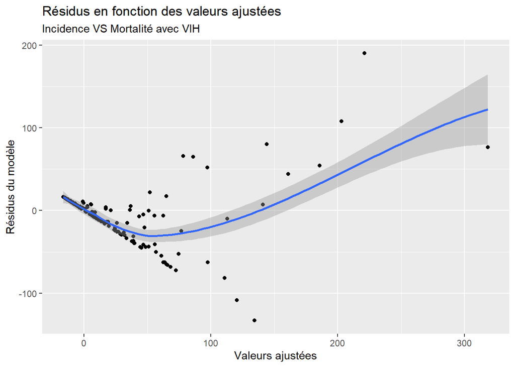

```r
# Création du graphique des résidus en fonction des valeurs ajustées
ggplot() +
  aes(x = fitted(mortalite_avec_vih_vs_incidence), y = residuals(mortalite_avec_vih_vs_incidence)) +
  # Définition de l'axe X avec les valeurs ajustées et de l'axe Y avec les résidus du modèle

  geom_point() +  # Ajout du nuage de points pour afficher la relation entre les valeurs ajustées et les résidus

  geom_smooth() +  # Ajout d'une courbe lissée pour observer la tendance des résidus

  xlab("Valeurs ajustées") +  # Légende pour l'axe X (valeurs ajustées)

  ylab("Résidus du modèle") +  # Légende pour l'axe Y (résidus du modèle)

  ggtitle("Résidus en fonction des valeurs ajustées", subtitle = "Incidence VS Mortalité avec VIH")  # Titre du graphique et sous-titre
```

Le graphique montre la relation entre les résidus du modèle de régression (Incidence VS Mortalité avec VIH) et les valeurs ajustées. Ce type de graphique est essentiel pour examiner l’homoscédasticité, c’est-à-dire si les erreurs de prédiction sont distribuées de manière homogène, ou si elles présentent des tendances particulières selon les valeurs ajustées.

#### Qqplot

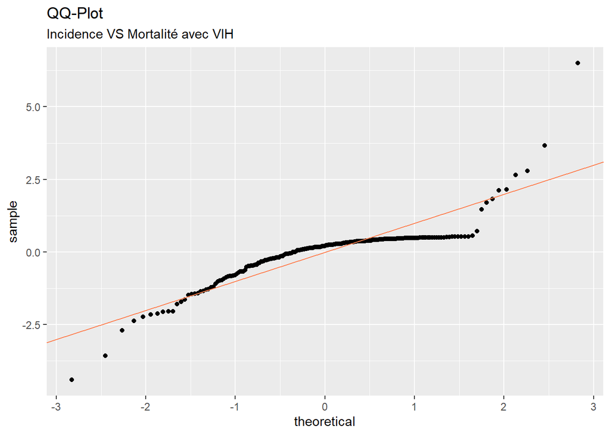

```r
# Création du QQ-Plot pour vérifier la normalité des résidus
ggplot() +
  geom_qq(aes(sample=rstandard(mortalite_avec_vih_vs_incidence))) +  # Ajout du QQ-plot avec les résidus standardisés du modèle
  geom_abline(color="coral") +  # Ajout d'une ligne de référence (droite rouge) pour une distribution normale
  ggtitle("QQ-Plot", subtitle="Incidence VS Mortalité avec VIH")  # Titre et sous-titre du graphique
```

Les points s’alignent principalement sur la droite orange, indiquant une relation normale entre les résidus et la distribution théorique. Cependant, aux extrémités du graphique, les points commencent à s’écarter de la droite, ce qui suggère la présence de valeurs extrêmes ou d’une distribution plus lourde des queues que celle d’une distribution normale. Plus spécifiquement, la partie droite du graphique, correspondant aux valeurs positives élevées, montre un écart plus important par rapport à la droite, ce qui peut indiquer que le modèle sous-estime la variance des résidus pour les grandes valeurs d’incidence et de mortalité.

En conclusion, bien que la majorité des résidus suivent une distribution normale, les points extrêmes suggèrent qu’il pourrait y avoir des outliers ou des points influents, qui méritent d’être examinés plus en détail pour garantir la fiabilité du modèle.

#### Scale-location (position-échelle)

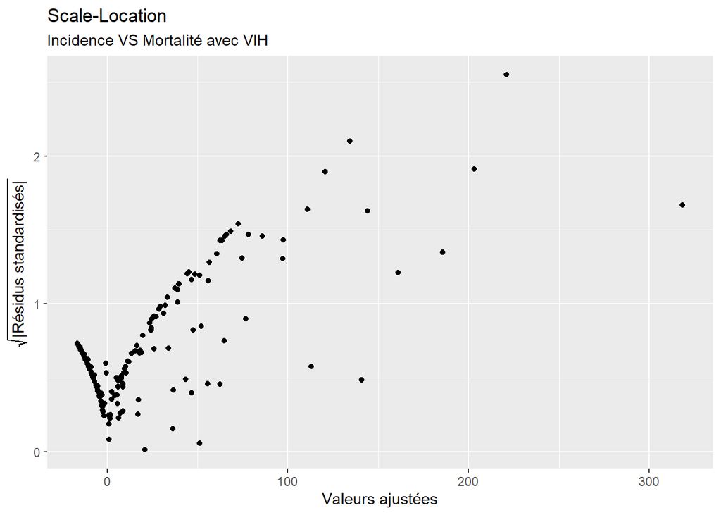

```r
# Création du graphique Scale-Location pour vérifier l'homoscédasticité
ggplot() +
  aes(x = fitted(mortalite_avec_vih_vs_incidence), y = sqrt(abs(rstandard(mortalite_avec_vih_vs_incidence)))) +
  # Axe X avec les valeurs ajustées et Axe Y avec les racines des résidus standardisés

  geom_point()  +  # Ajout des points sur le graphique

  xlab("Valeurs ajustées") +  # Titre de l'axe X

  ylab(expression(sqrt("|Résidus standardisés|"))) +
  # Titre de l'axe Y avec une expression mathématique pour la racine carrée des résidus

  ggtitle("Scale-Location", subtitle="Incidence VS Mortalité avec VIH")  # Titre du graphique et sous-titre
```

Le graphique Scale-Location (ou Position-échelle) montre la relation entre les valeurs ajustées (prédictions du modèle) et les résidus standardisés, transformés par la racine carrée des résidus absolus. Ce graphique est utile pour évaluer l’homoscédasticité.

Ce type de dispersion des résidus est un signe d’hétéroscédasticité, où la variance des erreurs n’est pas constante à travers les différentes valeurs ajustées. Les modèles de régression linéaire, en particulier, supposent que les erreurs doivent avoir une variance constante, donc cette observation suggère qu’un modèle non linéaire pourrait être plus approprié pour ces données.

Nous allons donc chercher à identifier d’où proviennent ces valeurs aberrantes.

#### Distance de cook

```r
# Calcul de la distance de Cook pour le modèle
cooks_dist <- cooks.distance(mortalite_avec_vih_vs_incidence)
# Calcul de la distance de Cook pour chaque observation

# Définir un seuil pour identifier les points influents (outliers)
seuil_cooks <- 4 / length(cooks_dist)
# Seuil basé sur la règle de 4/n, avec n étant le nombre d'observations

# Identifier les indices des points dont la distance de Cook dépasse le seuil
outliers_indices <- which(cooks_dist > seuil_cooks)
# Trouver les indices des points influents

# Extraire les pays correspondants aux indices des points influents
outliers_pays <- TB2_2000$Country_or_territory_name[outliers_indices]
# Extraire les pays des indices trouvés

# Afficher les pays des outliers
print(outliers_pays)
```

```
##  [1] "Azerbaijan"
##  [2] "Bhutan"
##  [3] "Botswana"
##  [4] "Cambodia"
##  [5] "Central African Republic"
##  [6] "Democratic People's Republic of Korea"
##  [7] "Djibouti"
##  [8] "Gabon"
##  [9] "Kazakhstan"
## [10] "Kiribati"
## [11] "Lesotho"
## [12] "Malawi"
## [13] "Mozambique"
## [14] "Namibia"
## [15] "Philippines"
## [16] "Swaziland"
## [17] "Tuvalu"
## [18] "Uganda"
## [19] "Zimbabwe"
```

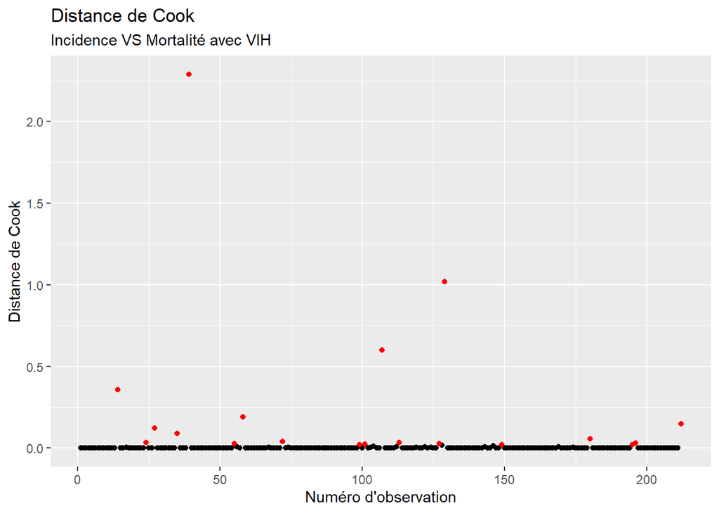

```r
# Affiche les pays dont les distances de Cook sont supérieures au seuil

# Afficher la distance de Cook pour toutes les observations, en mettant en rouge les outliers
ggplot() +
  aes(x = seq_along(cooks_dist), y = cooks_dist) +
  # Axe X avec le numéro d'observation et Y avec la distance de Cook
  geom_point() +

  # Ajouter les points représentant les distances de Cook
  geom_point(data = data.frame(x = outliers_indices, y = cooks_dist[outliers_indices]),
             aes(x = x, y = y), colour = "red") +
  # Points influents (outliers) en rouge

  xlab("Numéro d'observation") +  # Titre de l'axe X

  ylab("Distance de Cook") +  # Titre de l'axe Y

  ggtitle("Distance de Cook", subtitle = "Incidence VS Mortalité avec VIH")  # Titre du graphique et sous-titre
```

Le graphique de la distance de Cook montre les points influents dans la régression entre l’incidence et la mortalité avec VIH. Ces points sont représentés par des cercles rouges, ce qui permet de visualiser leur influence sur le modèle. Les points influents sont ceux dont la distance de Cook est plus élevée, ce qui indique qu’ils ont un impact significatif sur les coefficients estimés du modèle.

#### Residual versus leverage

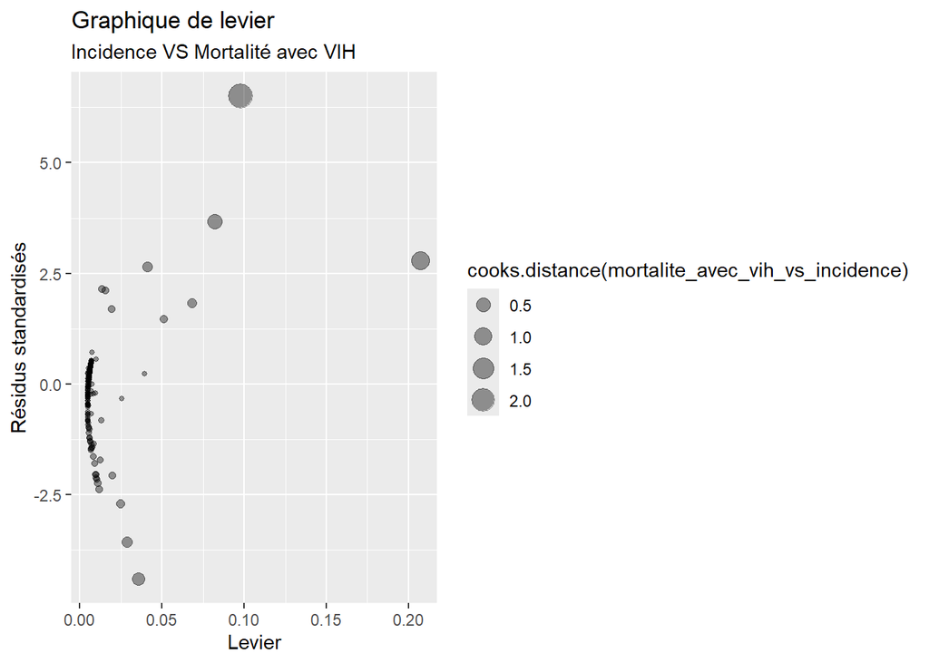

```r
ggplot() +  # Démarre un graphique avec ggplot2.
  aes(x = hatvalues(mortalite_avec_vih_vs_incidence), y = rstandard(mortalite_avec_vih_vs_incidence)) +
  # Définit les axes x et y :
  # x = "hatvalues" (valeurs de levier) du modèle `mortalite_avec_vih_vs_incidence`.
  # y = "rstandard" (résidus standardisés) du même modèle.

  geom_point(aes(size = cooks.distance(mortalite_avec_vih_vs_incidence)), alpha = 0.4) +
  # Ajoute des points (géométrie "point") dans le graphique en utilisant les valeurs définies précédemment.
  # Les points sont dimensionnés selon la "cooks.distance" du modèle, ce qui permet de voir les points influents.
  # "alpha = 0.4" définit la transparence des points (0 = complètement transparent, 1 = complètement opaque).

  xlab("Levier") +  # Ajoute un label à l'axe des x : "Levier" (valeurs de levier).

  ylab("Résidus standardisés") +  # Ajoute un label à l'axe des y : "Résidus standardisés".

  ggtitle("Graphique de levier", subtitle = "Incidence VS Mortalité avec VIH")
```

```r
  # Ajoute un titre principal au graphique ("Graphique de levier") et un sous-titre ("Incidence VS Mortalité avec VIH").
```

Le graphique de Levier examine la relation entre les résidus standardisés et le levier des observations dans le modèle de régression, tout en tenant compte de la distance de Cook. Il permet de détecter les points influents, à la fois en termes d’impact sur la régression (résidus) et de leur influence sur le modèle (levier).

La taille des points dans le graphique correspond à la distance de Cook, qui montre l’influence globale d’une observation sur les paramètres du modèle. Plus la taille est grande, plus l’observation a un effet important sur le modèle.

On observe que les points avec un levier élevé sont situés plus loin de l’axe X, ce qui signifie qu’ils ont une plus grande capacité à influencer les résultats du modèle. Ces points doivent être surveillés, car ils peuvent fausser les résultats de régression. De plus, les points de grande taille (indiquant une distance de Cook élevée) sont les plus influents. Ceux-ci sont situés à la fois à une position de levier élevé et possèdent un résidu important, ce qui signifie qu’ils affectent à la fois l’ajustement du modèle et la variabilité des erreurs.

Enfin, la majorité des points sont situés près de l’axe des résidus, ce qui indique que la plupart des observations ont une faible influence sur le modèle.

En somme, l’incidence de la tuberculose et la mortalité liée au VIH sont liées dans le sens où une incidence élevée de la tuberculose entraîne généralement une mortalité accrue, surtout parmi les personnes vivant avec le VIH, qui sont particulièrement vulnérables à cette infection.

## II.1.6) incidence & mortalité sans VIH

#### covariance

```r
TB2_2000 %>%
  select(`Estimated_incidence_(all_forms)_per_100_000_population`,
`Estimated_mortality_of_TB_cases_(all_forms,_excluding_HIV)_per_100_000_population`)%>%#Sélectionner les colonnes "Estimated_incidence_(all_forms)_per_100_000_population" et "Estimated_mortality_of_TB_cases_(all_forms,_excluding_HIV)_per_100_000_population"

  cov()
```

```
##                                                                                   Estimated_incidence_(all_forms)_per_100_000_population
## Estimated_incidence_(all_forms)_per_100_000_population                                                                         43704.066
## Estimated_mortality_of_TB_cases_(all_forms,_excluding_HIV)_per_100_000_population                                               5630.678
##                                                                                   Estimated_mortality_of_TB_cases_(all_forms,_excluding_HIV)_per_100_000_population
## Estimated_incidence_(all_forms)_per_100_000_population                                                                                                     5630.678
## Estimated_mortality_of_TB_cases_(all_forms,_excluding_HIV)_per_100_000_population                                                                          1208.579
```

```r
#calcul de la matrice de covariance entre les deux variables sélectionnées
```

La covariance entre l’incidence de la tuberculose et la mortalité de la tuberculose est positivement élevée (valeur de 5630.678). Cela indique qu’il existe une forte relation positive entre l’incidence et la mortalité : lorsque l’incidence augmente, la mortalité a tendance à augmenter également. Cela est logique car plus de personnes sont affectées par la tuberculose, plus il est probable que le nombre de décès augmente, en particulier dans les zones où les soins de santé sont limités.

La variance de l’incidence est 43704.066, ce qui signifie qu’il existe une certaine dispersion des valeurs d’incidence autour de la moyenne.

La variance de la mortalité est 1208.579, ce qui suggère une variabilité plus faible de la mortalité par rapport à l’incidence. Cela peut indiquer que la mortalité suit une tendance plus homogène, même si la distribution des cas d’incidence est plus dispersée.

La covariance positive et élevée entre l’incidence et la mortalité indique une relation forte entre ces deux variables. Cela suggère que dans les pays ou régions où l’incidence de la tuberculose est élevée, la mortalité a également tendance à être élevée, bien que le degré exact de cette relation puisse varier en fonction des facteurs de santé publique et des ressources disponibles dans chaque région.

En résumé, la covariance entre l’incidence et la mortalité de la tuberculose est assez forte et positive, indiquant que ces deux variables évoluent ensemble de manière similaire. Pour mieux comprendre cette relation, nous allons calculer les coefficients de corrélation de Pearson et de Spearman, et faire une regréssion linéaire de ces variables.

#### Coefficient de corrélation pearson

```r
# Calcul du coefficient de corrélation de Pearson entre l'incidence et la mortalité sans VIH

cor(
  x = TB2_2000[["Estimated_incidence_(all_forms)_per_100_000_population"]],  # Sélection de la colonne "Incidence" de la tuberculose (toutes formes)

  y = TB2_2000[["Estimated_mortality_of_TB_cases_(all_forms,_excluding_HIV)_per_100_000_population"]],  # Sélection de la colonne "Mortalité sans VIH" de la tuberculose

  method = "pearson"  # Calcul du coefficient de corrélation de Pearson, mesurant la relation linéaire entre les deux variables
)
```

```
## [1] 0.7747513
```

#### Coefficient de corrélation Spearman

```r
# Calcul du coefficient de corrélation de Spearman entre l'incidence et la mortalité sans VIH

cor(
  x = TB2_2000[["Estimated_incidence_(all_forms)_per_100_000_population"]],
  # Sélection de la colonne "Incidence" de la tuberculose (toutes formes)

  y = TB2_2000[["Estimated_mortality_of_TB_cases_(all_forms,_excluding_HIV)_per_100_000_population"]],
  # Sélection de la colonne "Mortalité sans VIH" de la tuberculose

  method = "spearman"
  # Calcul du coefficient de corrélation de Spearman, qui mesure la relation monotone entre les deux variables, sans supposer une relation linéaire
)
```

```
## [1] 0.9196434
```

Un coefficient de Pearson de 0.7748 indique une forte relation linéaire positive entre l’incidence de la tuberculose et la mortalité des cas (hors VIH), suggérant qu’à mesure que l’incidence augmente, la mortalité augmente également. Cependant, cette relation n’est pas parfaitement linéaire, ce qui est confirmé par la valeur inférieure à 1.

Le coefficient de Spearman de 0.9196 révèle une relation monotone très forte entre l’incidence et la mortalité, indiquant que, bien que la relation ne soit pas strictement linéaire, les deux variables tendent à évoluer dans la même direction (augmentation ou diminution systématique).

En comparant les deux coefficients, Spearman montre une relation plus forte, ce qui suggère que la relation entre l’incidence et la mortalité est plus complexe que ce que le modèle linéaire de Pearson capte. Spearman, en capturant une tendance générale, semble mieux refléter les variations non linéaires. En résumé, bien que les deux coefficients montrent une forte relation, la relation monotone capturée par Spearman est plus précise.

#### Nuage de points

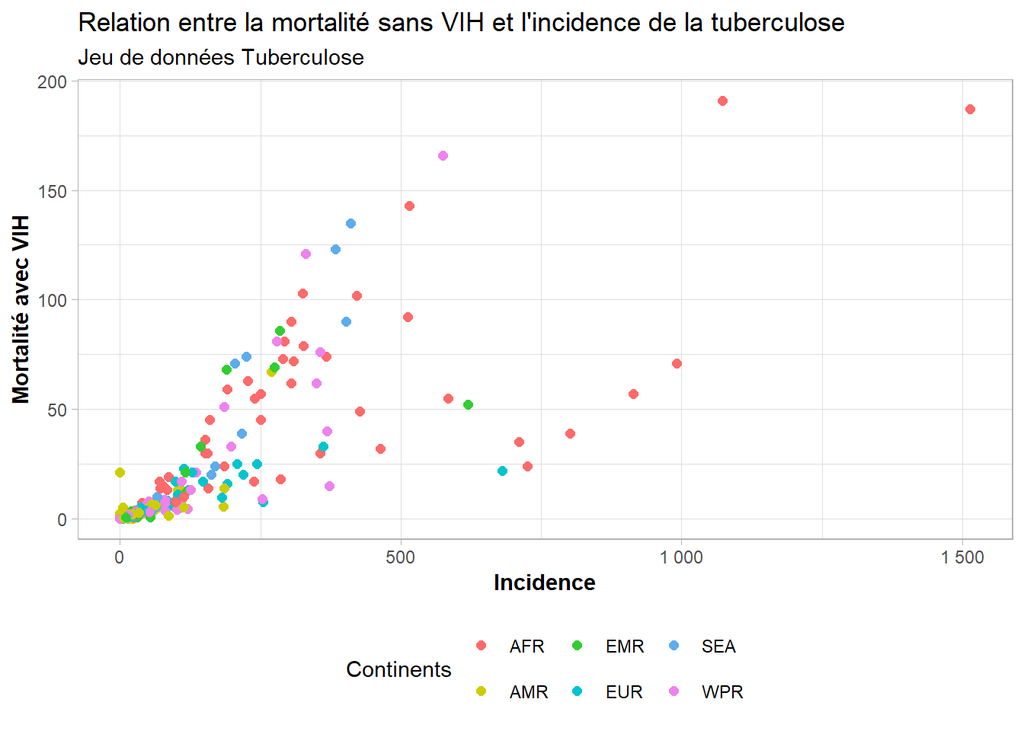

```r
# Définir une palette de couleurs fixe pour les régions
region_colors <- c("AFR" = "indianred1", "AMR" = "yellow3", "EMR" = "limegreen",
                   "EUR" = "turquoise3", "SEA" = "steelblue2", "WPR" = "violet")
# Crée une palette de couleurs personnalisée pour les différentes régions (AFR, AMR, EMR, EUR, SEA, WPR)


# 1) Nuage de points avec tous les continents :
ggplot(TB2_2000) +
  aes(x = `Estimated_incidence_(all_forms)_per_100_000_population`,  # Définit la variable pour l'axe X (Incidence)

      y = `Estimated_mortality_of_TB_cases_(all_forms,_excluding_HIV)_per_100_000_population`,  # Définit la variable pour l'axe Y (Mortalité sans VIH)

      colour = Region) +  # Légende par couleur en fonction de la région

  geom_point(size = 2) +  # Crée les points sur le graphique avec une taille de 2

  scale_colour_manual(values = region_colors) +  # Applique les couleurs personnalisées définies précédemment

  labs(  # Définit les titres des axes et de la légende
    x = "Incidence",
    y = "Mortalité avec VIH",
    colour = "Continents"
  ) +
  ggtitle("Relation entre la mortalité sans VIH et l'incidence de la tuberculose",  # Titre principal du graphique

          subtitle = "Jeu de données Tuberculose") +  #Sous-titre
  scale_x_continuous(labels =scales::label_number(decimal.mark = ",")) +  # Formate les labels de l'axe X

  scale_y_continuous(labels =scales::label_number(decimal.mark = ",")) +  # Formate les labels de l'axe Y

  guides(color = guide_legend(nrow = 2)) +  # Ajuste la position de la légende

  theme_light() +  # Applique un thème léger

  theme(  # Personnalise le style du graphique

    legend.position = "bottom",  # Position de la légende en bas
    axis.title = element_text(face = "bold")  # Met les titres des axes en gras
  )
```

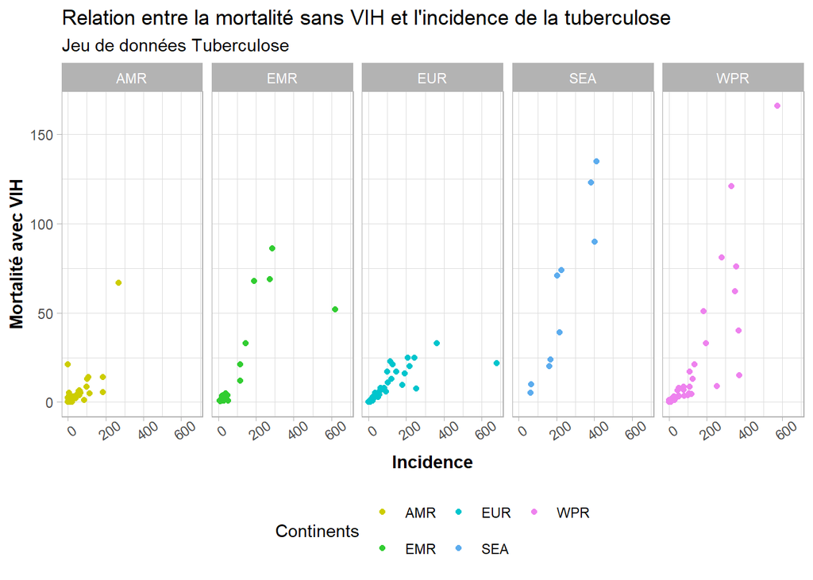

```r
# 2) Nuage de points sans la région AFR (Afrique) :
ggplot(TB2_2000 %>% filter(Region != "AFR")) +  # Filtre les données pour exclure la région AFR

  aes(x = `Estimated_incidence_(all_forms)_per_100_000_population`,
      y = `Estimated_mortality_of_TB_cases_(all_forms,_excluding_HIV)_per_100_000_population`,
      colour = Region) +
  geom_point() +  # Crée les points sur le graphique

  scale_colour_manual(values = region_colors) +  # Applique la palette de couleurs

  labs(
    x = "Incidence",
    y = "Mortalité avec VIH",
    colour = "Continents"
  ) +
  ggtitle("Relation entre la mortalité sans VIH et l'incidence de la tuberculose",
          subtitle = "Jeu de données Tuberculose") +
  scale_x_continuous(labels =scales::label_number(decimal.mark = ",")) +
  scale_y_continuous(labels =scales::label_number(decimal.mark = ",")) +

  facet_grid(cols = vars(Region)) +  # Crée un facettage par région

  guides(color = guide_legend(nrow = 2)) +  # Positionne la légende

  theme_light() +

  theme(
    legend.position = "bottom",
    axis.title = element_text(face = "bold"),
    axis.text.x = element_text(angle = 35)  # Incline les textes de l'axe X pour les rendre plus lisibles
  )
```

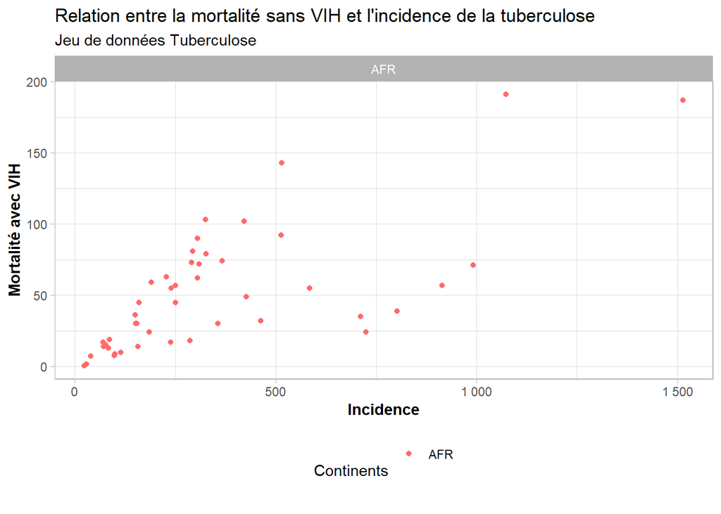

```r
# 3) Nuage de points uniquement pour la région AFR (Afrique) :
ggplot(TB2_2000 %>% filter(Region == "AFR")) +  # Filtre les données pour ne garder que la région AFR
  aes(x = `Estimated_incidence_(all_forms)_per_100_000_population`,
      y = `Estimated_mortality_of_TB_cases_(all_forms,_excluding_HIV)_per_100_000_population`,
      colour = Region) +
  geom_point() +  # Crée les points sur le graphique

  scale_colour_manual(values = region_colors) +  # Applique la palette de couleurs
  labs(
    x = "Incidence",
    y = "Mortalité avec VIH",
    colour = "Continents"
  ) +
  ggtitle("Relation entre la mortalité sans VIH et l'incidence de la tuberculose",
          subtitle = "Jeu de données Tuberculose") +
  scale_x_continuous(labels =scales::label_number(decimal.mark = ",")) +
  scale_y_continuous(labels =scales::label_number(decimal.mark = ",")) +
  facet_grid(cols = vars(Region)) +  # Crée un facettage par région

  guides(color = guide_legend(nrow = 2)) +  # Positionne la légende

  theme_light() +
  theme(
    legend.position = "bottom",
    axis.title = element_text(face = "bold")
  )
```

Afrique (AFR) est largement représentée par des valeurs élevées de mortalité et d’incidence, avec une concentration de points particulièrement visible dans la zone supérieure. Cela montre les défis sanitaires auxquels sont confrontés les pays africains en raison de la double épidémie de tuberculose et de VIH.

Deuxième graphique (Relation par continent) :

Ce graphique présente des données séparées par continents, et il met en évidence des disparités marquées :

Asie du Sud-Est (SEA) présente une certaine variabilité avec des pays ayant des taux modérés de mortalité, mais les valeurs restent globalement plus faibles que celles de l’Afrique.

Afrique (AFR) reste la zone la plus fortement touchée, avec une forte disparité dans les valeurs, allant de faibles à extrêmement élevées. Cela reflète des systèmes de santé fragiles, un accès limité aux traitements, et des conditions socio-économiques et sanitaires défavorables.

Troisième graphique (Concentration des données en Afrique) :

La forte dispersion des points dans cette zone suggère que certains pays, bien que frappés par la tuberculose et le VIH, ont des taux de mortalité plus faibles grâce à des politiques sanitaires qui commencent à porter fruit. Toutefois, la majorité des pays restent lourdement affectés.

Ce graphique met également en évidence des disparités importantes entre les pays d’Afrique, soulignant la nécessité de réponses sanitaires spécifiques à chaque contexte.

#### Regression linéaire

```r
# Création du modèle de régression linéaire entre la mortalité sans VIH et l'incidence de la tuberculose

mortalite_sans_vih_vs_incidence <- TB2_2000 %>%
  # Utilisation de l'objet TB2_2000 comme source de données

  lm(`Estimated_mortality_of_TB_cases_(all_forms,_excluding_HIV)_per_100_000_population` ~
     `Estimated_incidence_(all_forms)_per_100_000_population`,
     # Définition de la relation : variable dépendante (y) = mortalité sans VIH
     data = .)
# Le modèle utilise les données de TB2_2000, avec un lien linéaire entre la mortalité sans VIH et l'incidence

# Résumé du modèle de régression
summary(mortalite_sans_vih_vs_incidence)
```

```
##
## Call:
## lm(formula = `Estimated_mortality_of_TB_cases_(all_forms,_excluding_HIV)_per_100_000_population` ~
##     `Estimated_incidence_(all_forms)_per_100_000_population`,
##     data = .)
##
## Residuals:
##     Min      1Q  Median      3Q     Max
## -72.493  -5.837  -3.792  -0.757  88.832
##
## Coefficients:
##                                                          Estimate Std. Error
## (Intercept)                                              3.086585   1.851079
## `Estimated_incidence_(all_forms)_per_100_000_population` 0.128836   0.007255
##                                                          t value Pr(>|t|)
## (Intercept)                                                1.667   0.0969 .
## `Estimated_incidence_(all_forms)_per_100_000_population`  17.757   <2e-16 ***
## ---
## Signif. codes:  0 '***' 0.001 '**' 0.01 '*' 0.05 '.' 0.1 ' ' 1
##
## Residual standard error: 22.03 on 210 degrees of freedom
## Multiple R-squared:  0.6002, Adjusted R-squared:  0.5983
## F-statistic: 315.3 on 1 and 210 DF,  p-value: < 2.2e-16
```

Tout d’abord, les résidus représentent la différence entre les valeurs observées et les valeurs prédites par le modèle. Les résidus varient de -72.493 à 88.832, avec une médiane de -3.792. Le 1er quartile (Q1) est -5.837, tandis que le 3ème quartile (Q3) est -0.757, indiquant que la majorité des résidus sont concentrés autour de valeurs négatives, avec quelques valeurs extrêmes positives.

Les résidus sont assez dispersés, avec des valeurs allant de -72.493 à 88.832. Bien qu’il y ait une certaine variabilité dans les erreurs de prédiction, cela ne semble pas biaisé de manière significative, car la médiane des résidus est proche de zéro. Cependant, la grande plage des résidus suggère qu’il existe quelques observations où le modèle ne prédit pas bien la mortalité.

Le modèle montre que l’incidence de la tuberculose est positivement liée à la mortalité de la tuberculose (sans VIH).

Le coefficient de l’incidence est de 0.1288, ce qui signifie que pour chaque augmentation de 1 cas par 100 000 habitants dans l’incidence de la tuberculose, la mortalité de la tuberculose (sans VIH) augmente de 0.1288 par 100 000 habitants.

Le p-value pour l’incidence est très faible (< 2.2e-16), ce qui signifie que la relation entre l’incidence et la mortalité est hautement significative. L’incidence est donc un facteur significatif pour prédire la mortalité de la tuberculose.

Le p-value pour l’intercept est de 0.0969, ce qui est supérieur à 0.05, ce qui signifie que l’intercept n’est pas significatif à un niveau de confiance de 95%. Cela suggère que l’inclusion de l’intercept peut ne pas être nécessaire, bien qu’il ne soit pas improbable dans ce cas.

Le R-squared est de 0.6002, ce qui signifie que 60.02% de la variance de la mortalité (sans VIH) est expliquée par l’incidence de la tuberculose. Cela montre que l’incidence est un facteur important pour prédire la mortalité, mais qu’il existe d’autres facteurs non pris en compte dans ce modèle, car environ 40% de la variance reste inexpliquée.

Le R-squared ajusté est de 0.5983, ce qui montre que le modèle s’ajuste bien aux données et prend en compte le nombre de variables.

Le F-statistic de 315.3 avec une p-value très faible (< 2.2e-16) indique que le modèle est globalement significatif. Cela montre que la relation entre l’incidence et la mortalité est robuste, et le modèle dans son ensemble est fiable.

Ainsi, le modèle de régression montre que l’incidence de la tuberculose est un prédicteur très significatif de la mortalité de la tuberculose (sans VIH) dans la population, expliquant environ 60% de la variance dans la mortalité. L’incidence est donc un facteur clé pour comprendre et prédire les tendances de mortalité liées à la tuberculose. Bien que le modèle montre une relation significative et robuste, il reste de la variance inexpliquée, suggérant qu’il existe d’autres facteurs non inclus dans le modèle qui influencent la mortalité.

#### Résidus versus valeurs ajustées

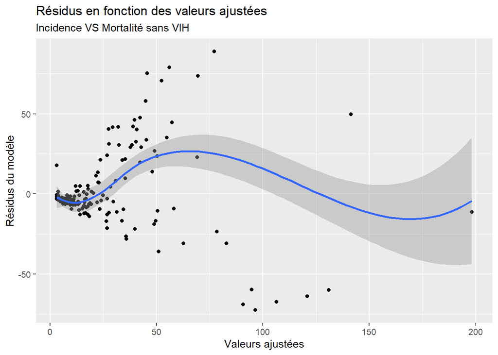

```r
ggplot() +
  # Création d'un graphique avec ggplot sans spécifier de données initiales
  aes(x = fitted(mortalite_sans_vih_vs_incidence), y = residuals(mortalite_sans_vih_vs_incidence )) +
  # aes() définit les variables à utiliser pour les axes du graphique

  geom_point() +
  # geom_point() trace un nuage de points pour visualiser la relation entre les valeurs ajustées et les résidus

  geom_smooth() +
  # geom_smooth() ajoute une courbe lissée (généralement une droite de régression) pour observer la tendance des résidus en fonction des valeurs ajustées

  xlab("Valeurs ajustées") +
  # xlab() définit le titre de l'axe des X comme "Valeurs ajustées"

  ylab("Résidus du modèle") +
  # ylab() définit le titre de l'axe des Y comme "Résidus du modèle"

  ggtitle("Résidus en fonction des valeurs ajustées", subtitle = "Incidence VS Mortalité sans VIH")
```

```r
# ggtitle() ajoute un titre principal et un sous-titre au graphique
```

#### Qqplot

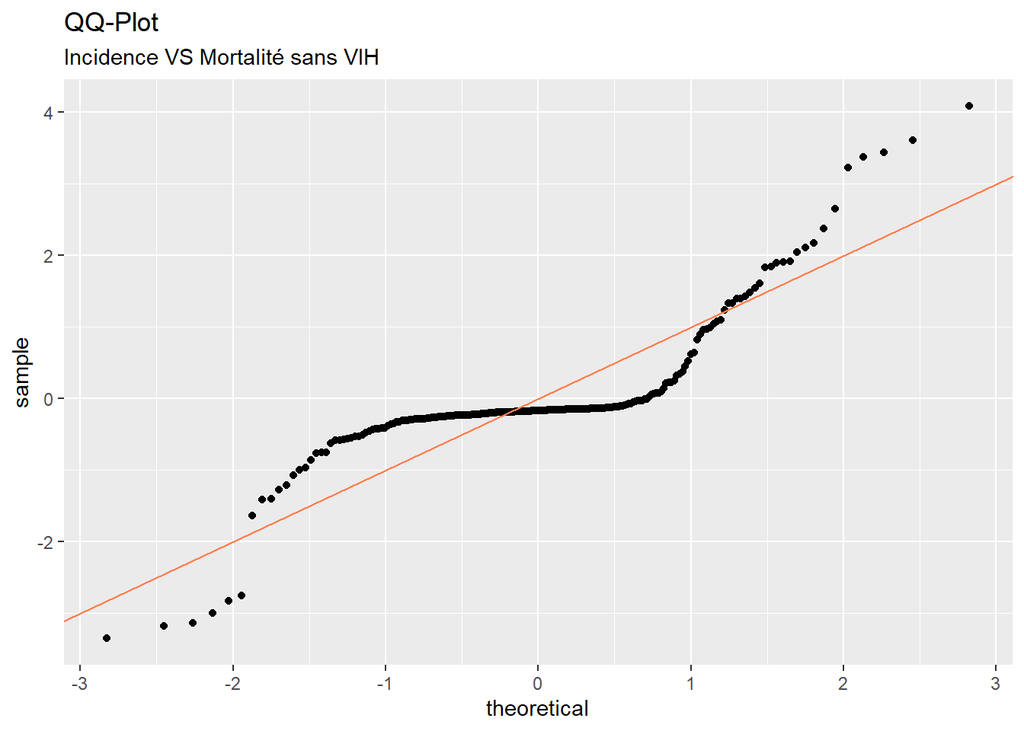

```r
ggplot() +
  # Création de l'objet graphique avec ggplot()
  geom_qq(aes(sample=rstandard(mortalite_sans_vih_vs_incidence))) +
  # Ajout du graphique QQ pour visualiser la normalité des résidus standardisés
  geom_abline(color="coral") +
  # Ajout de la droite d'égalité (ligne de référence) pour vérifier l'alignement des quantiles
  ggtitle("QQ-Plot", subtitle="Incidence VS Mortalité sans VIH")
```

```r
  # Ajout d'un titre principal et d'un sous-titre pour le graphique
```

Les points du graphique indiquent la position des résidus par rapport à la distribution normale théorique. La droite orange représente la ligne théorique que les points devraient suivre si les résidus suivaient parfaitement une distribution normale.

Aux extrémités du graphique, les points s’éloignent de la droite, tant dans les valeurs négatives que positives élevées. Ce phénomène indique que les résidus présentent des queues plus lourdes que ce qui serait attendu d’une distribution normale.

Les points qui dévient dans les queues de la distribution pourraient être des outliers ou des valeurs extrêmes. Cela suggère qu’il y a une asymétrie dans les résidus, ou que des anomalies (valeurs aberrantes) sont présentes dans les données.

#### Scale-location (position-échelle)

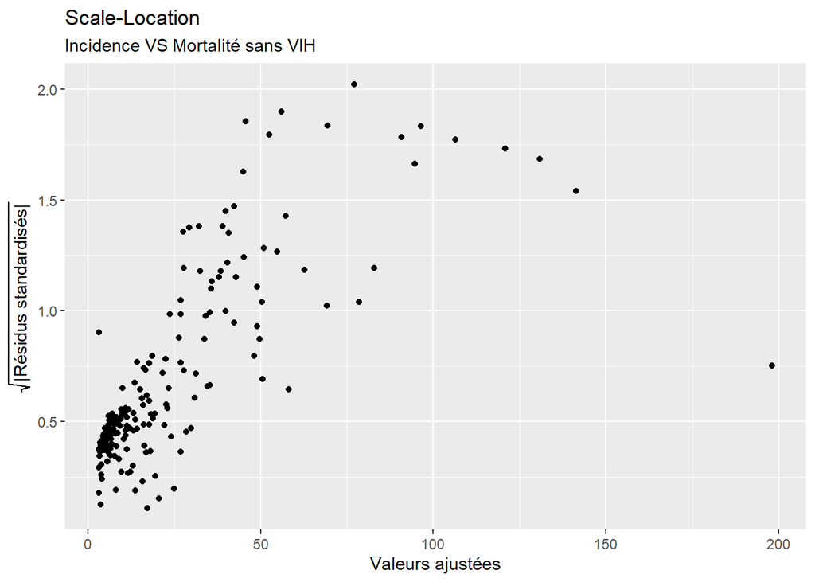

```r
ggplot() +
  # Création de l'objet graphique avec ggplot()
  aes(x = fitted(mortalite_sans_vih_vs_incidence), y = sqrt(abs(rstandard(mortalite_sans_vih_vs_incidence)))) +
  # Définition des axes : valeurs ajustées en X et racine carrée des résidus standardisés en Y

  geom_point() +
  # Ajout des points pour visualiser la relation entre les valeurs ajustées et les résidus transformés

  xlab("Valeurs ajustées") +  # Ajout du label pour l'axe X

  ylab(expression(sqrt("|Résidus standardisés|"))) +  # Ajout du label pour l'axe Y avec une expression mathématique pour les résidus standardisés transformés

  ggtitle("Scale-Location", subtitle="Incidence VS Mortalité sans VIH")  # Ajout du titre principal et du sous-titre pour le graphique
```

#### Distance de cook

```r
# Calcul de la distance de Cook
cooks_dist <- cooks.distance(mortalite_sans_vih_vs_incidence)

# Définir un seuil pour identifier les points outliers
seuil_cooks <- 4 / length(cooks_dist)

# Identifier les indices des points qui dépassent le seuil
outliers_indices <- which(cooks_dist > seuil_cooks)

# Extraire les pays correspondants aux outliers
outliers_pays <- TB2_2000$Country_or_territory_name[outliers_indices]

# Afficher les pays des outliers
print(outliers_pays)
```

```
##  [1] "Azerbaijan"
##  [2] "Botswana"
##  [3] "Cambodia"
##  [4] "Central African Republic"
##  [5] "Democratic People's Republic of Korea"
##  [6] "Djibouti"
##  [7] "Ethiopia"
##  [8] "Gabon"
##  [9] "Lao People's Democratic Republic"
## [10] "Lesotho"
## [11] "Myanmar"
## [12] "Namibia"
## [13] "Nigeria"
## [14] "Swaziland"
## [15] "Zambia"
## [16] "Zimbabwe"
```

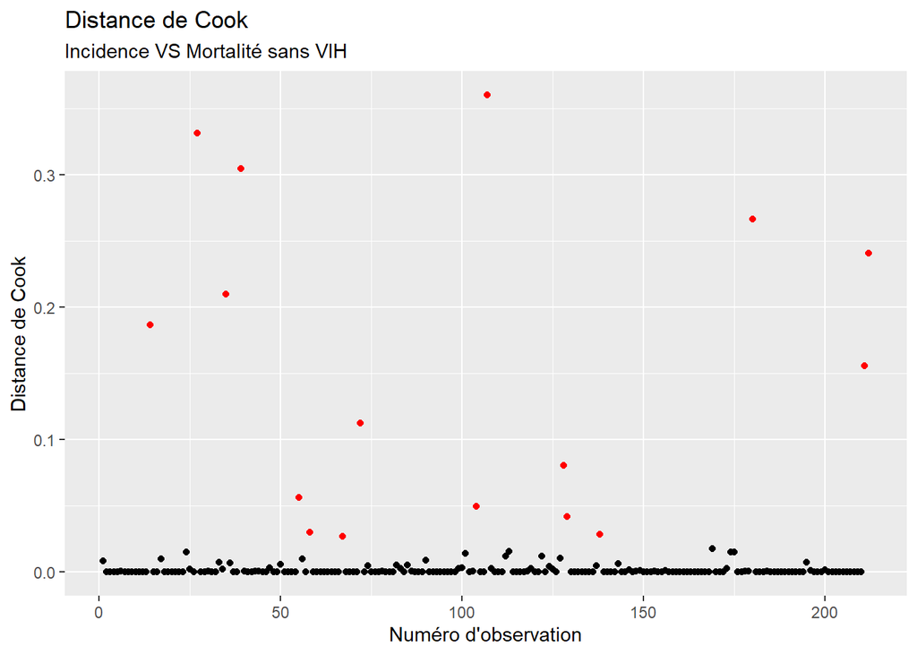

```r
# Afficher la distance de Cook avec les outliers en rouge
ggplot() +
  aes(x = seq_along(cooks_dist), y = cooks_dist) +
  geom_point() +
  geom_point(data = data.frame(x = outliers_indices, y = cooks_dist[outliers_indices]),
             aes(x = x, y = y), colour = "red") + # Points outliers en rouge
  xlab("Numéro d'observation") +
  ylab("Distance de Cook") +
  ggtitle("Distance de Cook", subtitle = "Incidence VS Mortalité sans VIH")
```

Le graphique de la distance de Cook met en évidence des observations influentes identifiées par les points en rouge. Ces points ont des distances de Cook supérieures à la moyenne, ce qui signifie qu’ils ont une forte capacité à affecter les résultats du modèle de régression. La distance de Cook mesure l’impact d’une observation sur les coefficients estimés du modèle, et un point avec une distance élevée peut influencer de manière significative les paramètres du modèle.

Les pays qui apparaissent comme des outliers (notés en rouge) dans ce graphique sont potentiellement responsables de la distorsion des résultats. Il y a : Azerbaijan, Botswana, Cambodia, Central African Republic, Democratic People’s Republic of Korea, Djibouti, Ethiopia, Gabon, Lao People’s Democratic Republic, Lesotho, Myanmar, Namibia, Nigeria, Swaziland, Zambia et le Zimbabwe. Cela pourrait indiquer qu’ils sont soit des observations aberrantes, soit qu’il existe une spécificité particulière dans ces pays qui nécessite une attention particulière. Par exemple, des données manquantes, des erreurs de saisie, ou des caractéristiques uniques pourraient expliquer pourquoi ces observations dévient des autres.

Ces pays sont principalement situés en Afrique et en Asie témoignant des observations faites avec le nuage de point.

#### Residual versus leverage

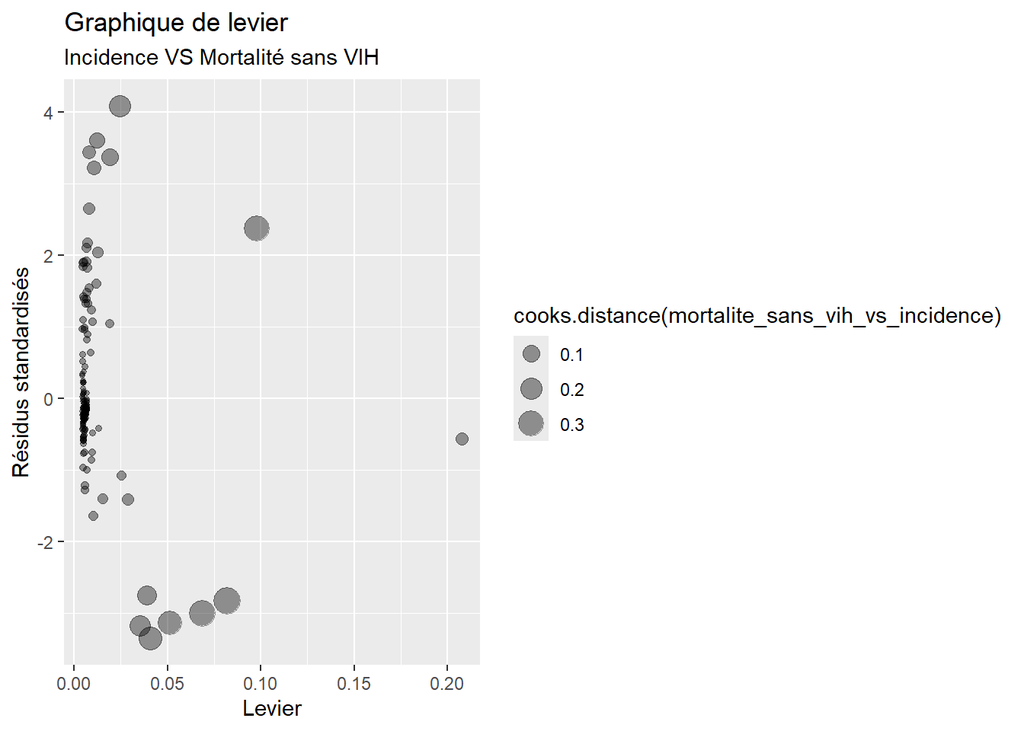

```r
ggplot() +  # Création d'un objet graphique avec ggplot(), initialisation d'un graphique vide.
  aes(x = hatvalues(mortalite_sans_vih_vs_incidence), y = rstandard(mortalite_sans_vih_vs_incidence)) +
  # Définition des axes du graphique :
  # - L'axe X représente le levier des points de données (mesure de l'influence d'un point sur le modèle).
  # - L'axe Y représente les résidus standardisés (mesure des erreurs de prédiction ajustées pour chaque observation).

  geom_point(aes(size=cooks.distance(mortalite_sans_vih_vs_incidence)), alpha=0.4) +
  # Ajout des points au graphique, où :
  # - La taille des points dépend de la distance de Cook (mesure de l'influence de chaque observation sur le modèle).
  # - L'opacité des points est réduite (alpha = 0.4) pour éviter la superposition excessive des points et faciliter la lecture du graphique.

  xlab("Levier") +
  # Label de l'axe X : "Levier", qui mesure l'influence de chaque observation sur le modèle.
  ylab("Résidus standardisés") +
  # Label de l'axe Y : "Résidus standardisés", qui mesure l'erreur de prédiction pour chaque observation.

  ggtitle("Graphique de levier", subtitle="Incidence VS Mortalité sans VIH")
```

```r
  # Ajout d'un titre principal au graphique "Graphique de levier", et un sous-titre pour préciser que l'analyse porte sur la relation entre l'incidence et la mortalité de la tuberculose sans VIH.
```

Le graphique de levier examine la relation entre les résidus standardisés et le levier des observations dans le modèle de régression, tout en prenant en compte leur influence globale à travers la distance de Cook. Il permet ainsi de détecter les points influents qui peuvent affecter l’ajustement du modèle.

La taille des points dans le graphique est déterminée par la distance de Cook, indiquant l’impact de chaque observation sur les résultats du modèle. Plus la taille du point est grande, plus l’observation a un effet significatif sur le modèle.

On observe que les points avec un levier élevé sont éloignés de l’axe des valeurs ajustées, ce qui signifie qu’ils ont une capacité plus importante à influencer les résultats de la régression. Ces points doivent être particulièrement surveillés, car ils pourraient fausser les résultats.

La majorité des points se trouvent près de l’axe des résidus, ce qui indique que la plupart des observations ont une faible influence sur le modèle. Cependant, les points à forte distance de Cook et ceux avec un levier élevé méritent une attention particulière, car ils ont un impact plus marqué sur l’ajustement du modèle et la variabilité des erreurs.

En somme, il existe une relation directe entre une incidence élevée de tuberculose et une mortalité accrue, en particulier dans les régions où les soins de santé sont insuffisants. Cette relation peut être renforcée par des facteurs sociaux, économiques et d’accès aux soins.

# II.B) Analyse qualitative bivariée

## II.2.1)variable det_case & region_facteur

#### Tableau de contingence

```r
# Créer le tableau de contingence pour det_case et region_facteur
contingence_det_region <- TB2_2000 %>%
  select(det_case, region_facteur) %>%   # Sélectionne les colonnes 'det_case' et 'region_facteur' du jeu de données TB2_2000

  table()# Crée un tableau de contingence entre ces deux variables

# Calculer les fréquences conditionnelles pour la variable det_case par region_facteur
conditional_det_region1 <- contingence_det_region  # Copie du tableau de contingence pour le traitement par colonne

conditional_det_region2 <- contingence_det_region  # Copie du tableau de contingence pour le traitement par ligne

# Normalisation pour les colonnes (par région)

for(j in 1:ncol(conditional_det_region1)) { # Boucle à travers les colonnes du tableau de contingence

  conditional_det_region1[,j] <- round(conditional_det_region1[,j] / sum(conditional_det_region1[,j]), digits = 2)  # Normalise chaque colonne (par région) en divisant par la somme de la colonne
}

# Normalisation pour les lignes (par det_case)

for(i in 1:nrow(conditional_det_region2)) { # Boucle à travers les lignes du tableau de contingence

  conditional_det_region2[i,] <- round(conditional_det_region2[i,] / sum(conditional_det_region2[i,]), digits = 2)
  # Normalise chaque ligne (par niveau de détection) en divisant par la somme de la ligne
}

# Utilisation de tidy sur conditional_det_region1
conditional_det_region1_tidy <- tidy(conditional_det_region1)  # Utilise tidy pour transformer le tableau de contingence en un format plus lisible
# Utilisation de tidy sur conditional_det_region2
conditional_det_region2_tidy <- tidy(conditional_det_region2)  # Idem pour l'autre tableau de contingence normalisé
# Affichage du premier tableau (par colonnes)

conditional_det_region1_tidy %>%
  pivot_wider(names_from = region_facteur,
                     values_from = n) %>% # Transforme le tableau en format large avec les régions comme colonnes
  kable(format = "markdown",
               caption = "Tableau de contingence normalisé pour `det_case` par `region_facteur` (normalisé par colonnes)") # Affiche le tableau avec un titre en markdown
```

Tableau de contingence normalisé pour `det_case` par `region_facteur` (normalisé par colonnes)

| det_case | AFR | AMR | EMR | EUR | SEA | WPR |
| --- | --- | --- | --- | --- | --- | --- |
| Bon | 0.13 | 0.53 | 0.59 | 0.72 | 0.2 | 0.56 |
| Correct | 0.28 | 0.20 | 0.18 | 0.13 | 0.2 | 0.11 |
| Insuffisant | 0.46 | 0.09 | 0.23 | 0.11 | 0.6 | 0.22 |
| Non renseignée | 0.13 | 0.18 | 0.00 | 0.04 | 0.0 | 0.11 |

```r
# Affichage du deuxième tableau (par lignes)

conditional_det_region2_tidy %>%
  pivot_wider(names_from = region_facteur,
              values_from = n) %>%  # Transformation en format large pour les lignes

  kable(format = "markdown",
        caption = "Tableau de contingence normalisé pour `det_case` par `region_facteur` (normalisé par lignes)")  # Affiche le tableau avec un titre en markdown
```

Tableau de contingence normalisé pour `det_case` par `region_facteur` (normalisé par lignes)

| det_case | AFR | AMR | EMR | EUR | SEA | WPR |
| --- | --- | --- | --- | --- | --- | --- |
| Bon | 0.06 | 0.23 | 0.13 | 0.37 | 0.02 | 0.19 |
| Correct | 0.33 | 0.23 | 0.10 | 0.18 | 0.05 | 0.10 |
| Insuffisant | 0.42 | 0.08 | 0.10 | 0.12 | 0.12 | 0.16 |
| Non renseignée | 0.30 | 0.40 | 0.00 | 0.10 | 0.00 | 0.20 |

-Tableau normalisé par lignes Ce tableau indique la répartition régionale au sein de chaque niveau de qualité de détection (det_case). Il permet de voir dans quelles régions se concentrent les pays pour chaque niveau de détection. Pour les pays avec une détection “Bon”, 37% sont en Europe (EUR), suivis par l’Amérique (23%) et l’Afrique (6%). Les détections “Insuffisantes” concernent majoritairement l’Afrique (42%) et les régions WPR et SEA. La catégorie “Non renseignée” est dominée par l’Amérique (40%) et l’Afrique (30%), révélant un manque d’information fréquent dans ces régions.

-Tableau normalisé par colonnes Ce tableau montre la qualité de détection dominante dans chaque région. Il permet de comparer les niveaux de détection à l’intérieur de chaque région. En Europe, 72% des pays ont une détection “Bonne”, ce qui en fait la région la plus performante en matière de surveillance. En Afrique, seulement 13% des pays ont une détection “Bonne”, tandis que 46% sont classés comme “Insuffisante”. En Asie du Sud-Est (SEA), 60% des pays sont aussi en détection “Insuffisante”, montrant une forte vulnérabilité.

#### Mosaic plot

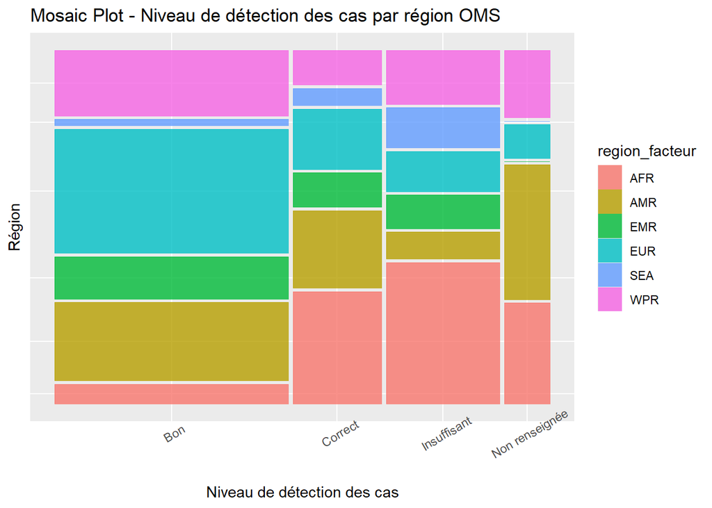

```r
# Créer le plot pour region_facteur et det_case
TB2_2000 %>%
  select(det_case, region_facteur) %>% # Sélectionne les colonnes 'det_case' et 'region_facteur' dans le jeu de       données TB2_2000

  ggplot() +  # Démarre la construction du graphique avec ggplot

  geom_mosaic(aes(x = product(region_facteur, det_case), fill = region_facteur), na.rm = TRUE) +
  # Utilise 'geom_mosaic' pour créer un graphique en mosaïque. L'axe x est défini par le produit des variables 'region_facteur' et 'det_case', et la couleur de remplissage est déterminée par 'region_facteur'. 'na.rm = TRUE' supprime les valeurs manquantes.

  labs(y = "Région", x = "Niveau de détection des cas") +
  # Ajoute des étiquettes aux axes : 'Région' pour l'axe y et 'Niveau de détection des cas' pour l'axe x

  theme(axis.text.x = element_text(angle = 30)) +  # Ajuste l'angle des étiquettes sur l'axe x à 30° pour éviter le chevauchement

  theme(axis.text.y = element_blank(), axis.ticks = element_blank()) +  # Masque les étiquettes et les ticks de l'axe y pour épurer le graphique

  ggtitle("Mosaic Plot - Niveau de détection des cas par région OMS") # Ajoute un titre au graphique, précisant qu'il s'agit d'un graphique enmosaïque montrant le niveau de détection des cas par région OMS
```

Ce graphique en mosaïque représente la répartition des niveaux de détection des cas de tuberculose selon les régions OMS en 2000. L’axe horizontal correspond aux niveaux de qualité de détection (Bon, Correct, Insuffisant, Non renseignée), et chaque barre est subdivisée par région selon leur contribution proportionnelle.

Les blocs sont visuellement plus étroits pour les niveaux “Correct” et “Non renseignée”, ce qui reflète une fréquence moindre dans l’ensemble, mais ils montrent tout de même des disparités régionales nettes.

#### Khi-deux

```r
TB2 %>%  # Charge le jeu de données TB2

  select(region_facteur, det_case) %>%# Sélectionne uniquement les colonnes 'region_facteur' (région selon l'OMS) et 'det_case' (niveau de détection des cas)

  table() %>%# Crée un tableau de contingence pour les deux variables sélectionnées, comptant les occurrences pour chaque combinaison unique de 'region_facteur' et 'det_case'

  chisq.test()# Applique le test du chi carré sur le tableau de contingence pour déterminer s'il existe une association significative entre les variables 'region_facteur' et 'det_case'
```

```
##
##  Pearson's Chi-squared test
##
## data:  .
## X-squared = 1265.3, df = 15, p-value < 2.2e-16
```

La p-value étant très inférieure à 0.05, on rejette l’hypothèse d’indépendance entre la région et la qualité de la détection. Cela signifie qu’il existe une association statistiquement significative entre la région où se trouve un pays et son niveau de détection des cas de tuberculose.

En d’autres termes, le niveau de surveillance n’est pas réparti au hasard selon les régions : certaines zones du monde présentent des taux de détection systématiquement meilleurs ou plus faibles que d’autres, ce qui renforce les constats précédents sur les inégalités régionales.

## II.2.2)incidence & region_facteur

Cela permettra de voir quelles régions géographiques sont les plus touchées par la tuberculose (en termes d’incidence) et si certaines régions (par exemple, l’Afrique (AFR)) sont plus fortement affectées.

#### Tableau de contingence

```r
# On crée le tableau de contingence pour 'incidence' et 'region_facteur'
contingence_inc_region <- TB2_2000 %>%
  select(incidence, region_facteur) %>%  # Sélectionne les colonnes 'incidence' et 'region_facteur' du jeu de données 'TB2_2000'

  table()  # Crée un tableau de contingence entre ces deux variables

# Calculer les fréquences conditionnelles pour la variable 'incidence' par 'region_facteur'

conditional_inc_region1 <- contingence_inc_region  # Copie du tableau de contingence pour le traitement par colonne

conditional_inc_region2 <- contingence_inc_region  # Copie du tableau de contingence pour le traitement par ligne

# Normalisation pour les colonnes (par région)
for(j in 1:ncol(conditional_inc_region1)) {  # Boucle à travers les colonnes du tableau de contingence

  conditional_inc_region1[,j]<-round(conditional_inc_region1[,j]/sum(conditional_inc_region1[,j]), digits = 2)  # Normalise chaque colonne (par région) en divisant par la somme de la colonne
}

# Normalisation pour les lignes (par incidence)
for(i in 1:nrow(conditional_inc_region2)) {  # Boucle à travers les lignes du tableau de contingence

  conditional_inc_region2[i,]<-round(conditional_inc_region2[i,] / sum(conditional_inc_region2[i,]), digits = 2)  # Normalise chaque ligne (par incidence) en divisant par la somme de la ligne
}

# On veut s'assurer que 'n' est de type numérique avant de passer à 'tidy()'
conditional_inc_region1_tidy <- tidy(conditional_inc_region1) %>%
  mutate(n = as.numeric(n))  # Convertir 'n' en numérique si nécessaire
conditional_inc_region2_tidy <- tidy(conditional_inc_region2) %>%
  mutate(n = as.numeric(n))  # Convertir 'n' en numérique si nécessaire
# Affichage du premier tableau (normalisé par colonnes)
conditional_inc_region1_tidy %>%
  pivot_wider(names_from = region_facteur,  # Transforme le tableau en format large avec les régions comme colonnes
              values_from = n) %>%
  kable(format = "markdown",  # Crée un tableau au format markdown
        caption = "Tableau de contingence normalisé pour `incidence` par `region_facteur` (normalisé par colonnes)")  # Affiche le tableau avec un titre en markdown
```

Tableau de contingence normalisé pour `incidence` par `region_facteur` (normalisé par colonnes)

| incidence | AFR | AMR | EMR | EUR | SEA | WPR |
| --- | --- | --- | --- | --- | --- | --- |
| 1 | 0.00 | 0.31 | 0.00 | 0.13 | 0.0 | 0.11 |
| 2 | 0.00 | 0.02 | 0.14 | 0.23 | 0.0 | 0.06 |
| 3 | 0.00 | 0.18 | 0.14 | 0.15 | 0.0 | 0.06 |
| 4 | 0.04 | 0.11 | 0.27 | 0.08 | 0.0 | 0.08 |
| 5 | 0.02 | 0.16 | 0.14 | 0.09 | 0.0 | 0.14 |
| 6 | 0.11 | 0.07 | 0.00 | 0.04 | 0.2 | 0.08 |
| 7 | 0.07 | 0.09 | 0.14 | 0.11 | 0.0 | 0.19 |
| 8 | 0.15 | 0.04 | 0.05 | 0.09 | 0.5 | 0.06 |
| 9 | 0.28 | 0.02 | 0.09 | 0.04 | 0.0 | 0.11 |
| 10 | 0.33 | 0.00 | 0.05 | 0.04 | 0.3 | 0.11 |

```r
# Affichage du deuxième tableau (par lignes)
conditional_inc_region2_tidy %>%
  pivot_wider(names_from = region_facteur, # Transforme le tableau en format large pour les lignes
              values_from = n) %>%
  kable(format = "markdown", # Crée un tableau au format markdown
        caption = "Tableau de contingence normalisé pour `incidence` par `region_facteur` (normalisé par lignes)") # Affiche le tableau avec un titre en markdown
```

Tableau de contingence normalisé pour `incidence` par `region_facteur` (normalisé par lignes)

| incidence | AFR | AMR | EMR | EUR | SEA | WPR |
| --- | --- | --- | --- | --- | --- | --- |
| 1 | 0.00 | 0.56 | 0.00 | 0.28 | 0.00 | 0.16 |
| 2 | 0.00 | 0.06 | 0.17 | 0.67 | 0.00 | 0.11 |
| 3 | 0.00 | 0.38 | 0.14 | 0.38 | 0.00 | 0.10 |
| 4 | 0.10 | 0.25 | 0.30 | 0.20 | 0.00 | 0.15 |
| 5 | 0.05 | 0.33 | 0.14 | 0.24 | 0.00 | 0.24 |
| 6 | 0.33 | 0.20 | 0.00 | 0.13 | 0.13 | 0.20 |
| 7 | 0.13 | 0.17 | 0.13 | 0.26 | 0.00 | 0.30 |
| 8 | 0.32 | 0.09 | 0.05 | 0.23 | 0.23 | 0.09 |
| 9 | 0.59 | 0.05 | 0.09 | 0.09 | 0.00 | 0.18 |
| 10 | 0.60 | 0.00 | 0.04 | 0.08 | 0.12 | 0.16 |

-Tableau normalisé par lignes Ce tableau indique, pour chaque niveau d’incidence, la répartition des pays par région. On observe que : Les pays à faible incidence (déciles 1 à 3) se concentrent dans les régions AMR (Amériques) et EUR (Europe). Les déciles les plus élevés (9 et 10) sont dominés par la région AFR (Afrique), qui regroupe 60 % des pays du 10e décile. Certaines régions comme SEA sont absentes dans les bas déciles mais bien présentes dans les niveaux élevés (ex. 12 % au décile 10), ce qui traduit une prévalence épidémique forte mais localisée

#### Mosaic plot

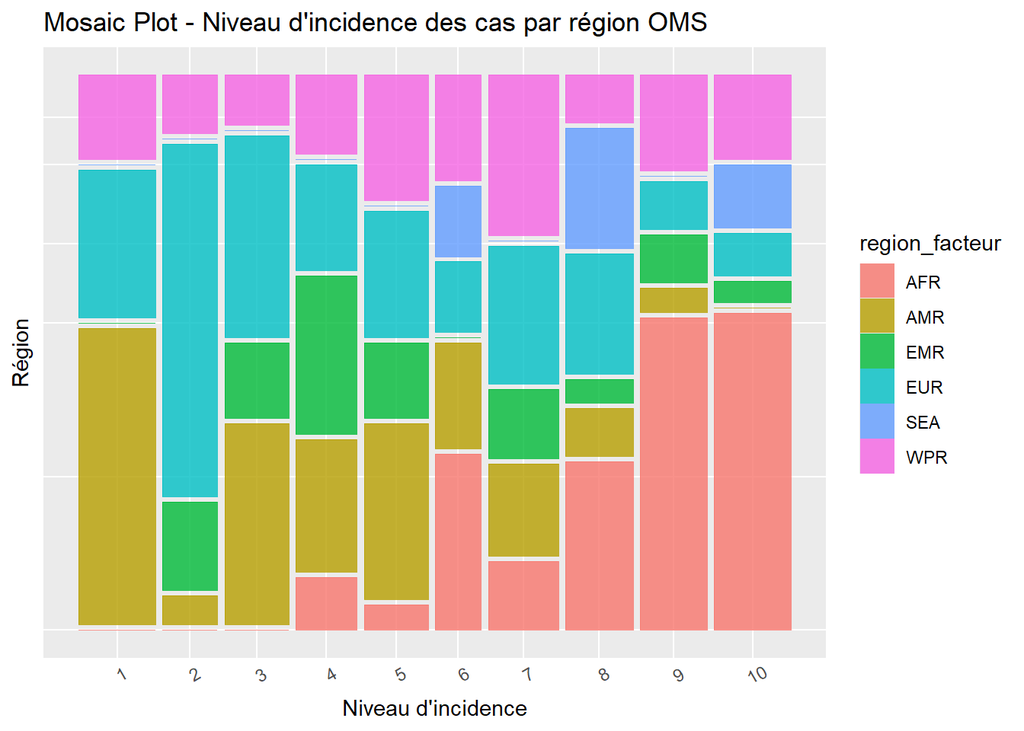

```r
# On crée le mosaic plot pour 'region_facteur' et 'det_case'

TB2_2000 %>%  # Utilise le dataframe 'TB2_2000'
  select(incidence, region_facteur) %>%  # Sélectionne les colonnes 'incidence' et 'region_facteur' du jeu de données

  ggplot() +  # Initialisation du graphique avec ggplot

  # Ajout du graphique de type 'mosaic' avec les variables 'region_facteur' et 'incidence'

  geom_mosaic(aes(x = product(region_facteur, incidence), fill = region_facteur), na.rm = TRUE) +
  # 'aes()' : Spécifie les variables à utiliser pour la création du mosaic plot.
  # 'product(region_facteur, incidence)' crée une interaction entre les deux variables pour construire le tableau de contingence dans le graphique.
  # 'fill = region_facteur' : Remplissage des différentes sections du graphique en fonction de 'region_facteur'.
  # 'na.rm = TRUE' : Ignore les valeurs manquantes (NA) lors du calcul du graphique.

  # Ajout des labels des axes

  labs(y = "Région", x = "Niveau d'incidence") +  # Titre de l'axe des ordonnées (y) : "Région", et de l'axe des abscisses (x) : "Niveau d'incidence"

  # Personnalisation de l'apparence des axes
  theme(axis.text.x = element_text(angle = 30)) +  # Inclinaison des étiquettes de l'axe des abscisses (x) à 30° pour une meilleure lisibilité

  # Personnalisation de l'axe des ordonnées (y)
  theme(axis.text.y = element_blank(), axis.ticks = element_blank()) +  # Enlève les étiquettes et les ticks (graduations) de l'axe des ordonnées (y)

  # Ajout du titre du graphique
  ggtitle("Mosaic Plot - Niveau d'incidence des cas par région OMS")  # Titre principal du graphique
```

Ce graphique en mosaïque illustre la répartition des niveaux d’incidence de la tuberculose (déciles 1 à 10) selon les régions OMS pour l’année 2000. Chaque colonne correspond à un niveau d’incidence, et la hauteur des rectangles par couleur représente la proportion de pays de chaque région dans ce niveau. On observe que les déciles 1 à 3 (faible incidence) sont dominés par les régions AMR (Amériques) et EUR (Europe), tandis que les déciles 9 et 10 (forte incidence) sont largement occupés par la région AFR (Afrique). La région SEA (Asie du Sud-Est) apparaît principalement dans les niveaux d’incidence élevés (à partir du décile 6), confirmant une forte charge épidémiologique localisée.

Ainsi, ce mosaic plot confirme visuellement la polarisation régionale déjà observée dans les tableaux : l’Amérique et l’Europe concentrent les pays à faible incidence, alors que l’Afrique et l’Asie du Sud-Est regroupent une grande part des pays les plus lourdement touchés par la tuberculose.

#### Khi deux

```r
TB2 %>%
  # Charge le jeu de données TB2
  select(region_facteur, incidence) %>%
  # Sélectionne les colonnes 'region_facteur' (région selon l'OMS) et 'incidence' (incidence de la tuberculose par 100 000 habitants)

  table() %>%
  # Crée un tableau de contingence pour les deux variables sélectionnées, comptant les occurrences pour chaque combinaison unique de 'region_facteur' et 'incidence'

  chisq.test()
```

```
##
##  Pearson's Chi-squared test
##
## data:  .
## X-squared = 2705.4, df = 45, p-value < 2.2e-16
```

```r
  # Applique le test du chi carré sur le tableau de contingence pour déterminer   s'il existe une association significative entre les variables   'region_facteur' et 'incidence'
```

La p-value étant très inférieure à 0.05, on rejette l’hypothèse d’indépendance entre la région et le niveau d’incidence.

Cela signifie qu’il existe une association statistiquement significative entre la région géographique d’un pays et son niveau d’incidence de la tuberculose. En d’autres termes, la répartition des niveaux d’incidence varie fortement selon les régions OMS, ce qui confirme les disparités régionales déjà observées dans les tableaux croisés et les graphiques.

## II.2.3)det_case & prevalence

#### Tableau de contingence

```r
# On crée le tableau de contingence pour 'det_case' et 'prevalence'
contingence_det_prevalence <- TB2_2000 %>%  # Sélectionne le dataframe 'TB2_2000'
  select(det_case, prevalence) %>%  # Extrait les colonnes 'det_case' et 'prevalence' du jeu de données
  table()  # Crée un tableau de contingence entre les variables 'det_case' et 'prevalence'

# Calcul des fréquences conditionnelles pour 'det_case' par 'prevalence'
conditional_det_prevalence1 <- contingence_det_prevalence  # Copie du tableau de contingence pour traitement par colonnes
conditional_det_prevalence2 <- contingence_det_prevalence  # Copie du tableau de contingence pour traitement par lignes

# Normalisation pour les colonnes (par prévalence)
for(j in 1:ncol(conditional_det_prevalence1)) {  # Boucle à travers les colonnes du tableau de contingence
  conditional_det_prevalence1[,j] <-round(conditional_det_prevalence1[,j]/sum(conditional_det_prevalence1[,j]), digits = 2)  # Normalise chaque colonne (par prévalence) en divisant par la somme de la colonne
}

# Normalisation pour les lignes (par det_case)
for(i in 1:nrow(conditional_det_prevalence2)) {  # Boucle à travers les lignes du tableau de contingence
  conditional_det_prevalence2[i,]<-
    round(conditional_det_prevalence2[i,]/
            sum(conditional_det_prevalence2[i,]), digits = 2)  # Normalise chaque ligne (par niveau de détection) en divisant par la somme de la ligne
}

# On veut s'assurer que 'n' est de type numérique avant de passer à 'tidy()'
conditional_det_prevalence1_tidy <- tidy(conditional_det_prevalence1) %>%  # Transforme le tableau de contingence en un format tidy

  mutate(n = as.numeric(n))  # Convertir 'n' en numérique si nécessaire
conditional_det_prevalence2_tidy <- tidy(conditional_det_prevalence2) %>%  # Transforme le tableau de contingence en un format tidy

  mutate(n = as.numeric(n))  # Convertir 'n' en numérique si nécessaire
# Affichage du premier tableau (normalisé par colonnes)
conditional_det_prevalence1_tidy %>%  # Utilisation du tableau normalisé par colonnes
  pivot_wider(names_from = prevalence, values_from = n) %>%  # Transforme le tableau long en format large avec 'prevalence' comme colonnes
  kable(format = "markdown",  # Crée un tableau au format markdown
        caption = "Tableau de contingence normalisé pour `det_case` par `prevalence` (normalisé par colonnes)")  # Affiche le tableau avec un titre en markdown
```

Tableau de contingence normalisé pour `det_case` par `prevalence` (normalisé par colonnes)

| det_case | 1 | 2 | 3 | 4 | 5 | 6 | 7 | 8 | 9 | 10 |
| --- | --- | --- | --- | --- | --- | --- | --- | --- | --- | --- |
| Bon | 0.67 | 0.86 | 0.89 | 0.76 | 0.70 | 0.44 | 0.39 | 0.19 | 0.07 | 0.04 |
| Correct | 0.05 | 0.00 | 0.00 | 0.19 | 0.22 | 0.19 | 0.43 | 0.31 | 0.14 | 0.29 |
| Insuffisant | 0.05 | 0.05 | 0.05 | 0.00 | 0.00 | 0.25 | 0.13 | 0.31 | 0.79 | 0.54 |
| Non renseignée | 0.24 | 0.10 | 0.05 | 0.05 | 0.09 | 0.12 | 0.04 | 0.19 | 0.00 | 0.12 |

```r
# Affichage du deuxième tableau (normalisé par lignes)
conditional_det_prevalence2_tidy %>%  # Utilisation du tableau normalisé par lignes
  pivot_wider(names_from = prevalence, values_from = n) %>%  # Transforme le tableau long en format large avec 'prevalence' comme colonnes
  kable(format = "markdown",  # Crée un tableau au format markdown
        caption = "Tableau de contingence normalisé pour `det_case` par `prevalence` (normalisé par lignes)")  # Affiche le tableau avec un titre en markdown
```

Tableau de contingence normalisé pour `det_case` par `prevalence` (normalisé par lignes)

| det_case | 1 | 2 | 3 | 4 | 5 | 6 | 7 | 8 | 9 | 10 |
| --- | --- | --- | --- | --- | --- | --- | --- | --- | --- | --- |
| Bon | 0.14 | 0.17 | 0.17 | 0.16 | 0.16 | 0.07 | 0.09 | 0.03 | 0.02 | 0.01 |
| Correct | 0.03 | 0.00 | 0.00 | 0.10 | 0.13 | 0.08 | 0.26 | 0.13 | 0.10 | 0.18 |
| Insuffisant | 0.02 | 0.02 | 0.02 | 0.00 | 0.00 | 0.08 | 0.06 | 0.10 | 0.44 | 0.26 |
| Non renseignée | 0.25 | 0.10 | 0.05 | 0.05 | 0.10 | 0.10 | 0.05 | 0.15 | 0.00 | 0.15 |

Conclusion : les résultats des deux tableaux montrent une relation claire entre le niveau de prévalence et le niveau de détection des cas : Les pays à faible prévalence sont mieux équipés pour détecter les cas de tuberculose, avec une proportion élevée de détection “Bon”. À l’inverse, les pays avec une prévalence élevée souffrent de systèmes de détection insuffisants ou manquants, notamment dans les déciles 9 et 10. Cela souligne l’importance de renforcer les systèmes de surveillance dans les régions les plus affectées, notamment en Afrique et en Asie du Sud-Est, où la charge épidémique est la plus forte.

#### Mosaic plot

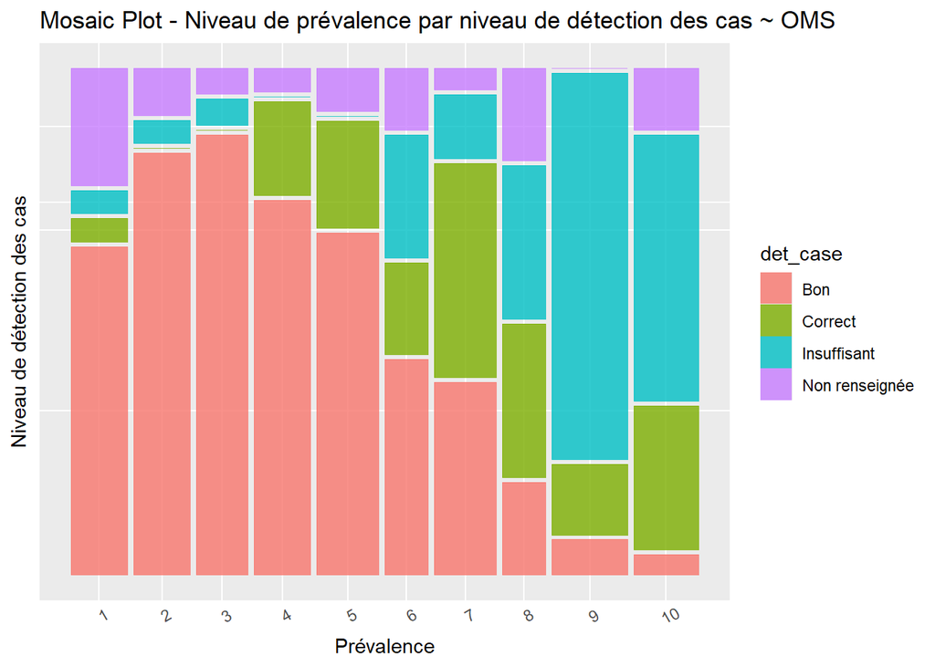

```r
# On crée le mosaic plot pour 'prevalence' et 'det_case'

TB2_2000 %>%  # Utilise le dataframe 'TB2_2000'
  select(det_case, prevalence) %>%  # Sélectionne les colonnes 'det_case' et 'prevalence' du jeu de données

  ggplot() +  # Initialise le graphique avec ggplot


  geom_mosaic(aes(x = product(det_case, prevalence), fill = det_case), na.rm = TRUE) +
  # 'aes()' : Définit les variables à utiliser pour la création du mosaic plot.
  # 'product(det_case, prevalence)' : Crée une interaction entre les variables 'det_case' et 'prevalence' pour déterminer les sections du graphique.
  # 'fill = det_case' : Remplissage des différentes sections du graphique en fonction de 'det_case'.
  # 'na.rm = TRUE' : Ignore les valeurs manquantes (NA) lors du calcul du graphique.

  labs(x = "Prévalence", y = "Niveau de détection des cas") +  # Titre de l'axe des abscisses : "Prévalence" et de l'axe des ordonnées : "Niveau de détection des cas"


  theme(axis.text.x = element_text(angle = 30)) +  # Inclinaison des étiquettes de l'axe des abscisses (x) à 30° pour une meilleure lisibilité


  theme(axis.text.y = element_blank(), axis.ticks = element_blank()) +  # Enlève les étiquettes et les ticks (graduations) de l'axe des ordonnées (y)


  ggtitle("Mosaic Plot - Niveau de prévalence par niveau de détection des cas ~ OMS")  # Titre principal du graphique
```

Ce graphique en mosaïque montre la répartition des pays selon leur niveau de prévalence de la tuberculose et leur niveau de détection des cas (données de détection “Bon”, “Correct”, “Insuffisant” ou “Non renseigné”).

-Prévalence faible (déciles 1 à 3) : On observe que la majorité des pays dans cette catégorie ont un niveau de détection “Bon”, ce qui suggère que ces pays disposent de systèmes de surveillance efficaces. Ces pays sont probablement situés dans des régions à faible incidence, comme l’Europe et les Amériques. Cependant, une proportion non négligeable de données “Non renseignées” persiste également dans le premier décile. Ces données non renseignées pourraient être dues à des manques dans le reporting des données, ce qui empêche d’avoir une vision complète de la situation. En d’autres termes, les données de prévalence pourraient être incomplètes ou erronées, faussant ainsi les estimations globales.

-Prévalence plus élevée (déciles 8 à 10) : Les pays dans ces déciles montrent une forte proportion de détection “Insuffisante” ou “Non renseignée”, ce qui traduit des lacunes dans la détection des cas dans les zones les plus affectées. Ces résultats sont typiques des régions à forte charge épidémiologique comme l’Afrique et l’Asie du Sud-Est, où les infrastructures de santé et la collecte de données sont souvent limitées.

#### Khi deux

```r
TB2 %>%  # Charge le jeu de données TB2
  select(det_case, prevalence) %>%
  # Sélectionne les colonnes 'det_case' (niveau de détection des cas de         tuberculose) et 'prevalence' (prévalence de la tuberculose par 100 000   habitants)

  table() %>%
  # Crée un tableau de contingence pour les variables sélectionnées, comptant   les occurrences pour chaque combinaison unique de 'det_case' et 'prevalence'

  chisq.test()
```

```
##
##  Pearson's Chi-squared test
##
## data:  .
## X-squared = 2218.3, df = 27, p-value < 2.2e-16
```

```r
  # Applique le test du chi carré sur le tableau de contingence pour déterminer   s'il existe une association significative entre les variables 'det_case' et   'prevalence'
```

Le test du khi-deux d’indépendance a été appliqué pour déterminer si le niveau de détection des cas (variable det_case) est indépendant du niveau de prévalence (variable prevalence). La p-value étant extrêmement petite (inférieure à 0.05), on rejette l’hypothèse d’indépendance. Cela signifie qu’il existe une relation statistiquement significative entre les deux variables.

Conclusion Les résultats du test du khi-deux montrent qu’il existe une dépendance significative entre le niveau de prévalence de la tuberculose et le niveau de détection des cas :

Les pays avec une faible prévalence ont tendance à avoir un meilleur taux de détection, avec des systèmes de surveillance plus efficaces.

Les pays avec une prévalence plus élevée rencontrent des problèmes de détection, avec une proportion plus importante de pays ayant des données insuffisantes ou non renseignées.

Cela met en lumière les disparités dans la gestion de la tuberculose et souligne l’importance de renforcer les systèmes de surveillance, particulièrement dans les régions à forte charge épidémique.

Nous ferons cette partie uniquement sur notre base de donnée TB2 car on souhaite analyser une certaine évolution dans le temps, se concentrer uniquement sur l’année 2000 ici n’est pas vraiment pertinent.

## II.C) Analyse bivariée quantitative et qualitative

## II.3.1)region & mortalité sans VIH

#### Boxplot

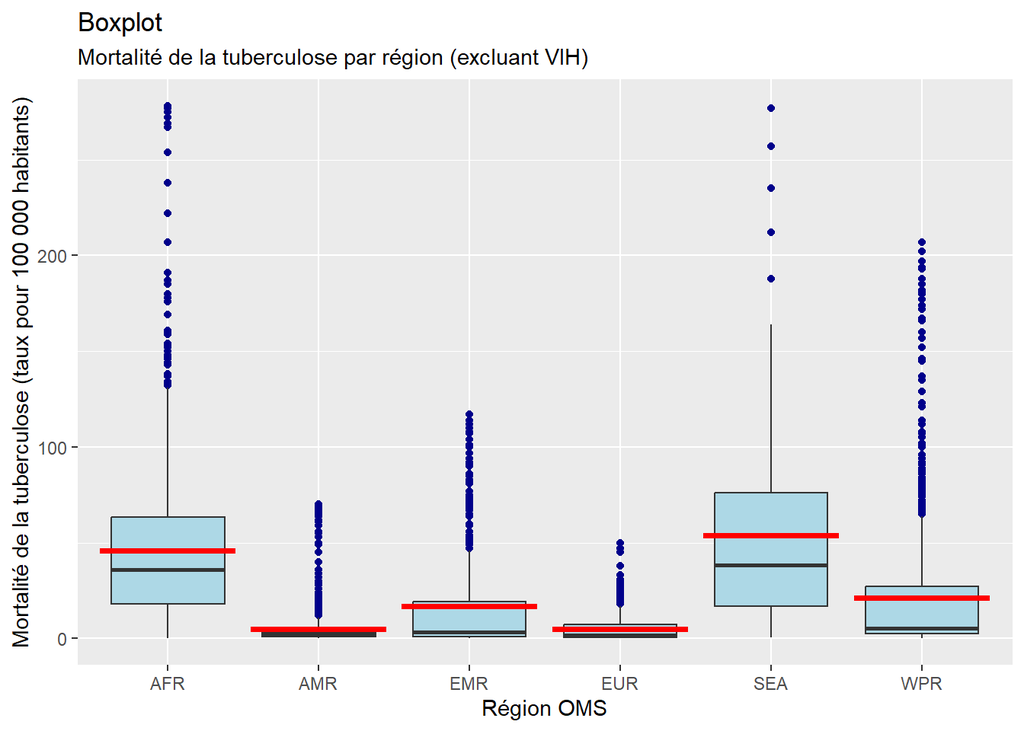

```r
# Créer un boxplot pour visualiser la distribution de la mortalité de la tuberculose par région

TB2 %>%
  filter(!is.na(`Estimated_mortality_of_TB_cases_(all_forms,_excluding_HIV)_per_100_000_population`)) %>%  # Exclut les valeurs manquantes de la mortalité de la tuberculose

  ggplot(# Initialise le graphique avec ggplot
    aes(
      x = as.factor(region_facteur),  # Abscisse = 'region_facteur' converti en facteur pour que chaque région soit représentée comme une catégorie

      y = `Estimated_mortality_of_TB_cases_(all_forms,_excluding_HIV)_per_100_000_population`)) +  # Ordonnée = mortalité de la tuberculose (par 100 000 habitants)

  geom_boxplot(  # Ajoute un boxplot pour afficher la distribution des données

    outlier.color = "darkblue",  # Les valeurs extrêmes (outliers) sont représentées par des points de couleur bleu foncé

    fill = "lightblue") +  # L'intérieur des boîtes est rempli avec une couleur bleu clair

  stat_summary(# Ajoute un résumé statistique pour calculer une statistique personnalisée

    fun = mean,  # moyenne de la mortalité

    geom = "crossbar",  # La moyenne est représentée par une barre horizontale

    color = "red") +  # La barre moyenne est colorée en rouge

  labs(  # Ajoute des labels pour les axes et le titre

    x = "Région OMS",  # Nom de l'axe des abscisses : "Région OMS"

    y = "Mortalité de la tuberculose (taux pour 100 000 habitants)",  # Nom de l'axe des ordonnées : "Mortalité de la tuberculose"

    title = "Boxplot",  # Titre principal du graphique

    subtitle = "Mortalité de la tuberculose par région (excluant VIH)")   # Sous-titre du graphique
```

Interprétation du boxplot :

Région AFR (Afrique) : La mortalité dans la région Afrique (AFR) est très variable, avec plusieurs outliers (valeurs aberrantes) à des niveaux de mortalité extrêmement élevés. Cela reflète une grande disparité dans la gestion de la tuberculose, où certains pays connaissent une forte charge épidémique. La moyenne (en rouge) est nettement supérieure à la médiane, ce qui indique une distribution asymétrique à droite. Les valeurs extrêmes de certains pays tirent la moyenne vers le haut, ce qui masque partiellement les situations plus favorables d’autres pays

Région SEA (Asie du Sud-Est) : La région Asie du Sud-Est (SEA) présente également une large variabilité dans la mortalité de la tuberculose. Les valeurs de mortalité sont globalement plus élevées que dans les autres régions, avec une étendue large, ce qui peut refléter desf défis structurels et une couverture de santé inégale dans la région.La moyenne y dépasse nettement la médiane, révélant une asymétrie marquée vers les hautes valeurs. Cela suggère que certains pays affichent des taux de mortalité particulièrement critiques.

Région AMR (Amériques) : La mortalité dans la région Amériques (AMR) semble plus homogène que dans les autres régions, bien qu’il y ait encore quelques outliers. Cela suggère que la tuberculose est mieux contrôlée dans cette région, mais certains pays peuvent encore souffrir de poches de mortalité plus élevées.La moyenne est proche de la médiane, indiquant une distribution relativement symétrique et équilibrée.

Région EUR (Europe) : La mortalité en Europe (EUR) est généralement plus faible et moins variable, ce qui reflète les systèmes de santé plus robustes et les efforts de contrôle de la tuberculose efficaces dans cette région.La moyenne est presque confondue avec la médiane, ce qui confirme une répartition équilibrée et homogène des données, avec peu d’influence des valeurs extrêmes.

#### Rapport de corélation

```r
# Calcul du rapport de corrélation avec eta2 (entre 'region_facteur' et 'Estimated_mortality_EXVIH_of_TB')

eta2(TB2$`Estimated_mortality_of_TB_cases_(all_forms,_excluding_HIV)_per_100_000_population`, TB2$region_facteur)
```

```
## [1] 0.2830339
```

```r
# Calcul du rapport de corrélation eta2 entre la mortalité de la tuberculose (excluant VIH) et les régions

# Créer le modèle linéaire pour tester l'effet de 'det_case' sur la prévalence estimée
lm_result <- summary(lm(TB2$`Estimated_mortality_of_TB_cases_(all_forms,_excluding_HIV)_per_100_000_population` ~ TB2$region_facteur))

# Création d'un modèle linéaire pour tester l'effet de la variable 'region_facteur' sur la mortalité de la tuberculose excluant VIH

# Afficher les résultats du modèle
print(lm_result)
```

```
##
## Call:
## lm(formula = TB2$`Estimated_mortality_of_TB_cases_(all_forms,_excluding_HIV)_per_100_000_population` ~
##     TB2$region_facteur)
##
## Residuals:
##     Min      1Q  Median      3Q     Max
## -53.245 -14.908  -4.114   3.181 232.110
##
## Coefficients:
##                       Estimate Std. Error t value Pr(>|t|)
## (Intercept)            45.8905     0.8375  54.792  < 2e-16 ***
## TB2$region_facteurAMR -41.0318     1.1896 -34.492  < 2e-16 ***
## TB2$region_facteurEMR -29.1392     1.4738 -19.771  < 2e-16 ***
## TB2$region_facteurEUR -40.7518     1.1435 -35.637  < 2e-16 ***
## TB2$region_facteurSEA   7.8444     1.9450   4.033 5.58e-05 ***
## TB2$region_facteurWPR -24.7822     1.2650 -19.591  < 2e-16 ***
## ---
## Signif. codes:  0 '***' 0.001 '**' 0.01 '*' 0.05 '.' 0.1 ' ' 1
##
## Residual standard error: 27.87 on 5114 degrees of freedom
## Multiple R-squared:  0.283,  Adjusted R-squared:  0.2823
## F-statistic: 403.8 on 5 and 5114 DF,  p-value: < 2.2e-16
```

```r
# Affichage des résultats du modèle linéaire (résumé du modèle avec les coefficients et p-valeurs)
```

Le modèle linéaire examine la relation entre la variable la mortalité estimée de la tuberculose excluant me VIH)et la variable region_facteur

Tout d’abord, l’Intercept (45.8905) représente l’estimation de la mortalité de la tuberculose pour la catégorie de référence (probablement la région par défaut qui n’apparaît pas dans la liste des résultats, comme une base de comparaison). Ce chiffre indique que la mortalité estimée est de 45.89 pour la région de base.

Les autres coefficients représentent l’effet de chaque région par rapport à la région de base (référence) :

- TB2$region_facteurAMR (-41.0318) : La mortalité dans la région AMR est inférieure de 41.03 par rapport à la région de référence.
- TB2$region_facteurEMR (-29.1392) : La mortalité dans la région EMR est inférieure de 29.14 par rapport à la région de référence.
- TB2$region_facteurEUR (-40.7518) : La mortalité dans la région EUR est inférieure de 40.75 par rapport à la région de référence.
- TB2$region_facteurSEA (7.8444): La mortalité dans la région SEA est supérieure de 7.84 par rapport à la région de référence.
- TB2$region_facteurWPR (-24.7822): La mortalité dans la région WPR est inférieure de 24.78 par rapport à la région de référence.

De plus, les p-valeurs associées à chaque coefficient sont extrêmement faibles, bien en dessous du seuil habituel de 0.05, indiquant que ces effets sont statistiquement significatifs. Autrement dit, chaque région a un effet significatif sur la mortalité de la tuberculose par rapport à la région de référence. Il y a donc une dsépendance entre ces variables étudiées, elles sont corélées.

Le R-Square (R² = 0.283) indique que le modèle explique environ 28.3% de la variance de la mortalité de la tuberculose. C’est une valeur modérée, ce qui signifie qu’il y a encore beaucoup de variance non expliquée par les facteurs régionaux dans le modèle. Il peut être utile d’envisager d’autres variables ou modèles pour améliorer l’ajustement.

L’erreur standard résiduelle (27.87) est relativement grande, ce qui indique qu’il y a une certaine dispersion autour des valeurs prédites. Cela peut indiquer que la relation entre les variables n’est pas parfaitement linéaire ou que d’autres facteurs pourraient expliquer davantage la variabilité des données.

En conclusion, il existe des différences significatives de mortalité de la tuberculose selon les régions, avec des valeurs inférieures dans certaines régions comme AMR, EMR, EUR, et WPR par rapport à la région de référence, et une valeur plus élevée dans la région SEA. Le modèle a un R² modéré, ce qui suggère que d’autres variables ou des interactions régionales pourraient améliorer l’explication des résultats.

## II.3.2)region & mortalité avec VIH

#### Boxplot

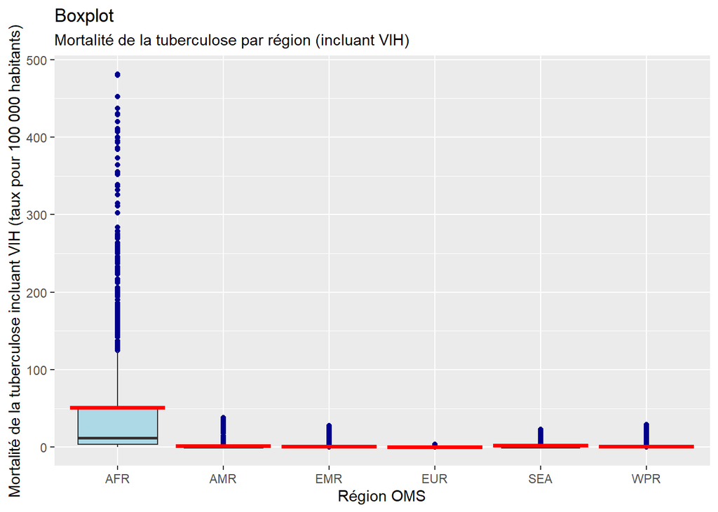

```r
# Créer un boxplot pour visualiser la distribution de la mortalité de la tuberculose incluant VIH par région

TB2 %>%
  filter(!is.na(`Estimated_mortality_of_TB_cases_who_are_HIV-positive,_per_100_000_population`)) %>%  # Exclut les valeurs manquantes de la mortalité de la tuberculose incluant VIH

  ggplot(  # Initialise le graphique avec ggplot
    aes(
      x = as.factor(region_facteur),  # Abscisse = 'region_facteur' converti en facteur pour que chaque région soit représentée comme une catégorie

      y = `Estimated_mortality_of_TB_cases_who_are_HIV-positive,_per_100_000_population`)) +  # Ordonnée = mortalité de la tuberculose incluant VIH (par 100 000 habitants)

  geom_boxplot(  # Ajoute un boxplot pour afficher la distribution des données

    outlier.color = "darkblue",  # Les valeurs extrêmes (outliers) sont représentées par des points de couleur bleu foncé

    fill = "lightblue") +  # L'intérieur des boîtes est rempli avec une couleur bleu clair

  stat_summary(# Ajoute un résumé statistique pour calculer une statistique personnalisée

    fun = mean,  # moyenne de la mortalité

    geom = "crossbar",  # La moyenne est représentée par une barre horizontale

    color = "red") +  # La barre moyenne est colorée en rouge

  labs(  # Ajoute des labels pour les axes et le titre

    x = "Région OMS",  # Nom de l'axe des abscisses : "Région OMS"

    y = "Mortalité de la tuberculose incluant VIH (taux pour 100 000 habitants)",  # Nom de l'axe des ordonnées : "Mortalité de la tuberculose incluant VIH"

    title = "Boxplot",  # Titre principal du graphique

    subtitle = "Mortalité de la tuberculose par région (incluant VIH)")  # Sous-titre du graphique
```

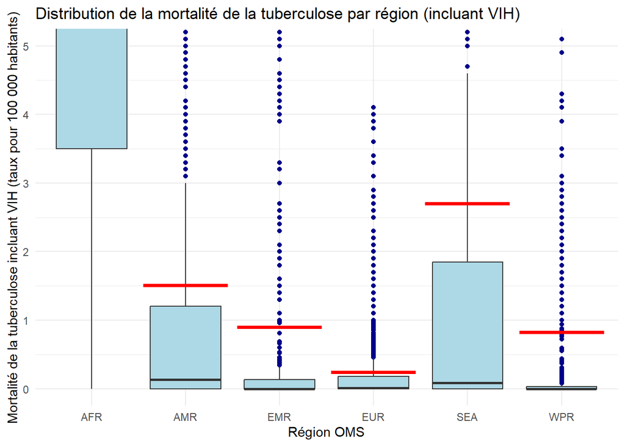

```r
# zoom du boxplot pour visualiser la distribution de la mortalité de la tuberculose incluant VIH par région
TB2 %>%
  filter(!is.na(`Estimated_mortality_of_TB_cases_who_are_HIV-positive,_per_100_000_population`)) %>%  # Exclut les valeurs manquantes de la mortalité de la tuberculose incluant VIH

  ggplot(  # Initialise le graphique avec ggplot
    aes(
      x = as.factor(region_facteur),  # Abscisse = 'region_facteur' converti en facteur pour que chaque région soit représentée comme une catégorie
      y = `Estimated_mortality_of_TB_cases_who_are_HIV-positive,_per_100_000_population`)) +  # Ordonnée = mortalité de la tuberculose incluant VIH (par 100 000 habitants)

  geom_boxplot(  # Ajoute un boxplot pour afficher la distribution des données
    outlier.color = "darkblue",  # Les valeurs extrêmes (outliers) sont représentées par des points de couleur bleu foncé
    fill = "lightblue") +  # L'intérieur des boîtes est rempli avec une couleur bleu clair

  stat_summary(  # Ajoute un résumé statistique pour calculer la moyenne
    fun = mean,  # Fonction pour calculer la moyenne de la mortalité
    geom = "crossbar",  # La moyenne est représentée par une barre horizontale
    color = "red") +  # La barre de la moyenne est colorée en rouge

  ggtitle("Distribution de la mortalité de la tuberculose par région (incluant VIH)") +  # Titre principal du graphique

  xlab("Région OMS") +  # Label de l'axe des X : "Région OMS"

  ylab("Mortalité de la tuberculose incluant VIH (taux pour 100 000 habitants)") +  # Label de l'axe des Y : "Mortalité de la tuberculose incluant VIH"

  theme_minimal() +  # Applique un thème minimaliste pour le graphique

  coord_cartesian(ylim = c(0, 5))  # Zoom sur l'axe des ordonnées entre 0 et 5 pour exclure les valeurs supérieures à 5 et mettre l'accent sur les données plus petites
```

Le boxplot montre la distribution de la mortalité de la tuberculose incluant le VIH (taux pour 100 000 habitants) par région OMS.

Région AFR (Afrique) : La mortalité de la tuberculose incluant le VIH dans la région Afrique (AFR) montre une forte variabilité, avec des outliers importants. Cela indique que certains pays ont une mortalité extrêmement élevée, probablement en raison de la co-infection VIH. La présence de valeurs aberrantes élevées suggère que certains pays de cette région souffrent d’une forte charge épidémique, ce qui est typique des régions à forte co-infection tuberculose-VIH.La moyenne (en rouge) est nettement supérieure à la médiane, ce qui suggère une asymétrie à droite et l’influence marquée de pays connaissant des crises sanitaires sévères. Cela accentue les inégalités régionales dans la gestion des deux infections.

Région SEA (Asie du Sud-Est) : La mortalité en Asie du Sud-Est (SEA) présente une larger étendue des valeurs, ce qui peut refléter des disparités importantes dans l’accès aux soins et les politiques de santé. Cela peut également indiquer une forte variabilité dans la gestion de la co-infection VIH.La moyenne est clairement au-dessus de la médiane, indiquant une distribution asymétrique où des pays très touchés tirent la moyenne vers le haut.

Région WPR (Pacifique occidental) : La mortalité dans la région Pacifique occidental (WPR) présente des valeurs relativement faibles, similaires à celles de l’Europe et des Amériques, bien qu’il y ait quelques pays avec des valeurs modérées. La moyenne dépasse légèrement la médiane, indiquant une asymétrie vers les valeurs élevées, probablement causée par des disparités structurelles et sanitaires dans la région.

#### Rapport de corrélation

```r
# Calcul du rapport de corrélation avec eta2 (entre 'region_facteur' et 'Estimated_mortality_of_TB')
eta2(TB2$`Estimated_mortality_of_TB_cases_who_are_HIV-positive,_per_100_000_population`,TB2$region_facteur)  # rapport de corrélation
```

```
## [1] 0.2080755
```

```r
# Créer le modèle linéaire pour tester l'effet de 'det_case' sur la prévalence estimée
lm_result <- summary(lm(TB2$`Estimated_mortality_of_TB_cases_who_are_HIV-positive,_per_100_000_population` ~ TB2$region_facteur))

# Afficher les résultats du modèle
print(lm_result)
```

```
##
## Call:
## lm(formula = TB2$`Estimated_mortality_of_TB_cases_who_are_HIV-positive,_per_100_000_population` ~
##     TB2$region_facteur)
##
## Residuals:
##    Min     1Q Median     3Q    Max
## -51.27  -1.51  -0.82  -0.21 429.73
##
## Coefficients:
##                       Estimate Std. Error t value Pr(>|t|)
## (Intercept)             51.271      1.216   42.17   <2e-16 ***
## TB2$region_facteurAMR  -49.766      1.727  -28.82   <2e-16 ***
## TB2$region_facteurEMR  -50.372      2.140  -23.54   <2e-16 ***
## TB2$region_facteurEUR  -51.034      1.660  -30.74   <2e-16 ***
## TB2$region_facteurSEA  -48.571      2.824  -17.20   <2e-16 ***
## TB2$region_facteurWPR  -50.448      1.836  -27.47   <2e-16 ***
## ---
## Signif. codes:  0 '***' 0.001 '**' 0.01 '*' 0.05 '.' 0.1 ' ' 1
##
## Residual standard error: 40.45 on 5114 degrees of freedom
## Multiple R-squared:  0.2081, Adjusted R-squared:  0.2073
## F-statistic: 268.7 on 5 and 5114 DF,  p-value: < 2.2e-16
```

On observe que l’Intercept est de 51.271. Cela correspond à la valeur de la variable “Estimated_mortality_of_TB_cases_who_are_HIV-positive,_per_100_000_population” pour la catégorie de référence de region_facteur. Autrement dit, si une région ne tombe dans aucune des catégories spécifiées, la mortalité pour les personnes vivant avec le VIH sera 51.271 (en termes de 100 000 habitants).

Voici l’effet des autres régions par rapport à la catégorie de référence :

- AMR (−49.766) : La mortalité de la tuberculose dans les régions AMR est réduite de 49.77 par rapport à la catégorie de référence.
- EMR (−50.372) : Les régions EMR ont une mortalité réduite de 50.37 par rapport à la catégorie de référence.
- EUR (−51.034) : La mortalité dans les régions EUR est réduite de 51.03 par rapport à la catégorie de référence.
- SEA (−48.571) : Les régions SEA ont une mortalité réduite de 48.57 par rapport à la catégorie de référence.
- WPR (−50.448) : La mortalité dans les régions WPR est réduite de 50.45 par rapport à la catégorie de référence.

Toutes les valeurs p sont inférieures à 2.2e-16, ce qui indique que les effets de region_facteur sur la mortalité de la tuberculose chez les personnes vivant avec le VIH sont statistiquement significatifs. Chaque catégorie de région a donc un impact significatif sur la mortalité par tuberculose.

Le R² de 0.2081 indique que 20.81% de la variation de la mortalité de la tuberculose chez les personnes vivant avec le VIH peut être expliquée par la variable region_facteur. Ce chiffre est relativement faible, ce qui signifie qu’il y a d’autres facteurs, non pris en compte dans ce modèle, qui expliquent la majorité de la variation dans les données.

L’erreur standard résiduelle de 40.45 montre la dispersion des résidus autour des valeurs observées. Plus cette valeur est faible, mieux le modèle s’ajuste aux données. Une erreur résiduelle élevée peut suggérer que le modèle n’explique pas parfaitement la variabilité des données.

Les régions AMR, EMR, EUR, SEA, et WPR ont toutes des taux de mortalité plus faibles par rapport à la catégorie de référence. Ce résultat suggère que ces régions peuvent avoir des politiques de santé publique ou des conditions sociales qui réduisent la mortalité par tuberculose chez les personnes vivant avec le VIH. Par exemple, des régions comme l’AMR et l’EMR ont des réductions significatives dans la mortalité par rapport à la région de référence.

On peut voir que le faible R² (20.81%) indique que bien que les régions aient un effet significatif sur la mortalité, le modèle ne capture pas entièrement la variance des données. Il pourrait être utile d’ajouter des variables supplémentaires dans le modèle (par exemple, des facteurs économiques, des politiques de santé, etc.) pour améliorer la capacité explicative du modèle.

On observe que toutes les variables associées à region_facteur ont des valeurs p très faibles, ce qui signifie qu’il est peu probable que les relations observées entre ces régions et la mortalité soient dues au hasard. Cela conforte l’idée que les régions influencent la mortalité de manière significative.

Ainsi, le modèle montre que les régions ont un effet statistiquement significatif sur la mortalité de la tuberculose chez les personnes vivant avec le VIH. Cependant, une part importante de la variation dans la mortalité reste inexpliquée par ce modèle, et il serait bénéfique d’enrichir le modèle avec d’autres variables explicatives pour mieux comprendre les facteurs influençant cette mortalité.

## II.3.3)det_case & estimated prévalence

#### Boxplot

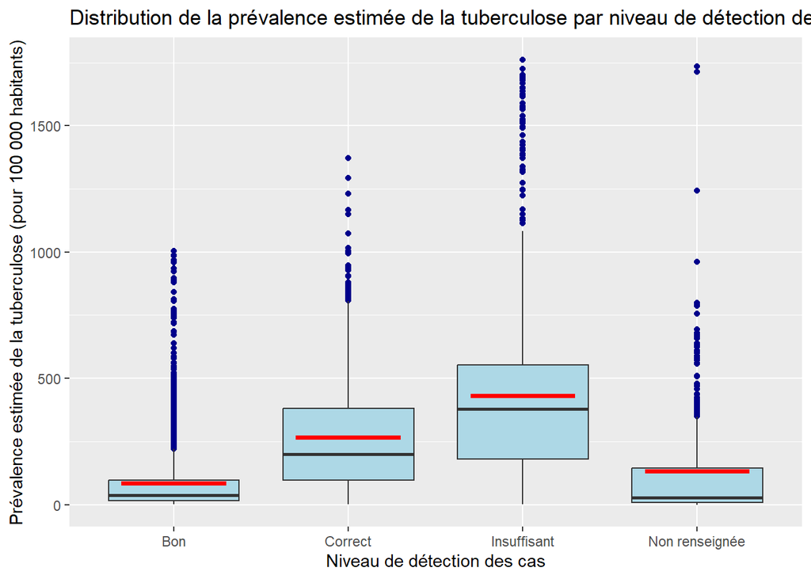

```r
# Créer un boxplot pour visualiser la distribution de la prévalence de la tuberculose par niveau de détection des cas

TB2 %>%
  filter(!is.na(`Estimated_prevalence_of_TB_(all_forms)_per_100_000_population`)) %>%  # Exclut les valeurs manquantes

  ggplot(
    aes(
      x = as.factor(det_case),  # Abscisse : niveau de détection des cas (catégorisé)

      y = `Estimated_prevalence_of_TB_(all_forms)_per_100_000_population`)) +  # Ordonnée : prévalence estimée

  geom_boxplot(
    outlier.color = "darkblue",  # Outliers en bleu foncé

    fill = "lightblue") +  # Remplissage des boxplots en bleu clair

  stat_summary(
    fun = mean,  # Calcule la moyenne

    geom = "crossbar",  # Représentation de la moyenne par une barre horizontale

    color = "red",  # Moyenne affichée en rouge

    width = 0.6) +  # Largeur de la barre moyenne

  labs(
    title = "Distribution de la prévalence estimée de la tuberculose par niveau de détection des cas",#titre boxplot
    x = "Niveau de détection des cas",#titre axe x
    y = "Prévalence estimée de la tuberculose (pour 100 000 habitants)")#titre axe y +
```

```r
  theme_minimal()  # Thème visuel épuré
```

[output not shown]

[output cut: 240 more lines]

[output not shown]

#### Rapport de corrélation

```r
# Calcul du rapport de corrélation avec eta2 (entre 'det_case' et 'Estimated_prevalence_of_TB')
eta2(TB2$`Estimated_prevalence_of_TB_(all_forms)_per_100_000_population`,TB2$det_case)  # rapport de corrélation
```

```
## [1] 0.2836523
```

```r
# Créer le modèle linéaire pour tester l'effet de 'det_case' sur la prévalence estimée
lm_result <- summary(lm(TB2$`Estimated_prevalence_of_TB_(all_forms)_per_100_000_population` ~ TB2$det_case))

# Afficher les résultats du modèle
print(lm_result)
```

```
##
## Call:
## lm(formula = TB2$`Estimated_prevalence_of_TB_(all_forms)_per_100_000_population` ~
##     TB2$det_case)
##
## Residuals:
##     Min      1Q  Median      3Q     Max
## -428.96  -79.14  -52.26   43.74 1603.87
##
## Coefficients:
##                            Estimate Std. Error t value Pr(>|t|)
## (Intercept)                  84.263      4.268  19.743  < 2e-16 ***
## TB2$det_caseCorrect         181.775      8.215  22.127  < 2e-16 ***
## TB2$det_caseInsuffisant     345.900      7.987  43.307  < 2e-16 ***
## TB2$det_caseNon renseignée   47.866     11.194   4.276 1.94e-05 ***
## ---
## Signif. codes:  0 '***' 0.001 '**' 0.01 '*' 0.05 '.' 0.1 ' ' 1
##
## Residual standard error: 219.3 on 5116 degrees of freedom
## Multiple R-squared:  0.2837, Adjusted R-squared:  0.2832
## F-statistic: 675.3 on 3 and 5116 DF,  p-value: < 2.2e-16
```

Tout d’abord, l’Intercept (84.263) correspond à la valeur estimée de la prévalence de la tuberculose (tous types confondus) par 100 000 habitants pour la catégorie de référence de det_case. Si aucune des autres catégories n’est applicable, la prévalence de la tuberculose serait de 84.263 pour 100 000 habitants.

Toutes les valeurs p sont très inférieures à 0.05, ce qui signifie que les relations entre les différentes catégories de det_case et la prévalence de la tuberculose sont statistiquement significatives : ces variables sont dépendantes entre elles.

Le R² est de 0.2837, ce qui indique que 28.37% de la variation de la prévalence de la tuberculose peut être expliquée par les catégories de det_case. Ce n’est pas un R² très élevé, donc cela suggère qu’il existe d’autres facteurs non pris en compte dans ce modèle qui expliquent la majorité de la variation de la prévalence.

L’erreur standard résiduelle de 219.3 montre la dispersion des résidus autour des valeurs observées. Une erreur élevée suggère que le modèle ne capte pas parfaitement la variabilité des données, et il pourrait être nécessaire d’ajouter davantage de variables explicatives.

Le faible R² (28.37%) indique que le modèle ne capture pas entièrement la variance de la prévalence de la tuberculose. Il serait judicieux d’ajouter d’autres variables explicatives dans le modèle, comme les conditions socio-économiques, les politiques de santé, ou d’autres indicateurs liés à la gestion de la tuberculose.

Comme les valeurs p sont très faibles pour toutes les catégories de det_case, cela indique que ces variables sont significativement associées à la prévalence de la tuberculose, ce qui renforce l’idée que la détection des cas influe sur la prévalence.

Ainsi, les résultats montrent que les catégories de détection des cas (correcte, insuffisante, non renseignée) ont un impact significatif sur la prévalence de la tuberculose. Cependant, le modèle explique une partie limitée de la variation, ce qui suggère qu’il y a d’autres facteurs importants à prendre en compte. L’ajout de variables supplémentaires pourrait améliorer la précision du modèle et nous permettre de mieux comprendre les déterminants de la prévalence de la tuberculose.

Passons maintenant à la dernière partie de notre projet :

# III) Analyse en compposante principale (ACP)

L’ACP est une technique qui permet de réduire la dimensionnalité. Nous allons nous demander quelles sont les relations multivariées qui existe entre les différentes variables. De plus, on cherchera à savoir quels sont les individus de TB2 qui se ressemblent et quels sont les indivus qui sont opposés.

Nous allons de ce fait créer un nouveau tableau nommé “TB2_ACP” dans lequel nous regrouperons toutes les variables quantitatives continues utilisées lors de nos analyses univariées et bivariées, ainsi que la variable qualitative Region.

Grâce à cela, notre ACP va nous permettre de savoir quelles sont les variables qui sont le plus fortement corrélées entre elles, de déterminer les variables influentes de la tuberculose et de déceller les groupes de pays qui ont tendance à être très impacté par la tuberculose.

```r
TB2_ACP<-TB2%>%
  select(  Country =Country_or_territory_name,
    Region,# valeurs qualitatives
          Year, #valeurs quantitatives

          Estimated_prevalence =`Estimated_prevalence_of_TB_(all_forms)_per_100_000_population`, # valeurs quantitatives
         Mortalite_sans_VIH= `Estimated_mortality_of_TB_cases_(all_forms,_excluding_HIV)_per_100_000_population`,# valeurs quantitatives
          Mortalite_avec_VIH= `Estimated_mortality_of_TB_cases_who_are_HIV-positive,_per_100_000_population` , # valeurs quantitatives
         Estimated_incidence =`Estimated_incidence_(all_forms)_per_100_000_population`)# valeurs quantitatives

# affichage des noms des colones de TB2-ACP
glimpse(TB2_ACP)
```

```
## Rows: 5,120
## Columns: 7
## $ Country              <chr> "Afghanistan", "Afghanistan", "Afghanistan", "Afg…
## $ Region               <chr> "EMR", "EMR", "EMR", "EMR", "EMR", "EMR", "EMR", …
## $ Year                 <dbl> 1990, 1991, 1992, 1993, 1994, 1995, 1996, 1997, 1…
## $ Estimated_prevalence <dbl> 306, 343, 371, 392, 410, 424, 438, 448, 454, 446,…
## $ Mortalite_sans_VIH   <dbl> 37.0, 46.0, 54.0, 60.0, 65.0, 69.0, 71.0, 72.0, 7…
## $ Mortalite_avec_VIH   <dbl> 0.04, 0.06, 0.08, 0.11, 0.13, 0.15, 0.17, 0.19, 0…
## $ Estimated_incidence  <dbl> 189, 191, 191, 189, 188, 188, 188, 189, 189, 190,…
```

## cercle de corrélations

Nous allons centrer et réduire nos données afin d’étudier une ACP centrée réduite. Lors du choix des composantes principales, la variance expliquée par la première composante sera toujours plus grande que la composante suivante et ainsi de suite.

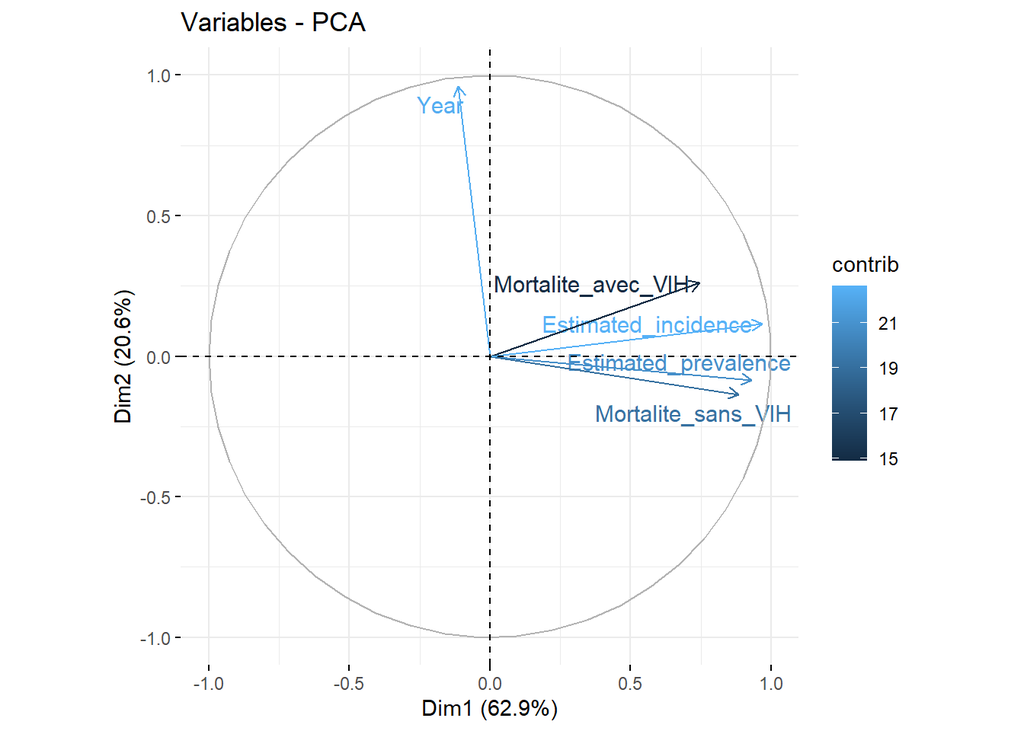

```r
res.pca =PCA(TB2_ACP[,3:7],# Sélection des colonnes 3 à 7 du tableau de données 'TB2_ACP'

             scale.unit = TRUE,# Les données sont centrées (moyenne = 0) et réduites (écart-type = 1)

             graph=F)  # Désactive l'affichage automatique des graphiques de l'ACP.

# Visualisation du cercle des corrélations (représentation des variables dans le plan factoriel)
fviz_pca_var(res.pca, # Résultat de l'ACP effectuée précédemment (objet PCA)
             col.var = "contrib",    # Colorier selon la contribution on vera cela plus en détail avec le sceenplot

             repel = T) # Active la répulsion automatique des étiquettes pour éviter qu'elles ne se chevauchent
```

Tout d’abord, les dimensions représentent l’axe des composantes principales. Lorsque les variables sont loin du cercle, il n’y a pas de conclusion pour ces points : elles ne sont pas corrélées linéairement. À contrariot, lorsqu’elles sont proche du bord du cercle, elles sont corréleées. Ici, la “contrib” donne la qualité de représentation de la vairable : plus une variable est proche du cercle, plus elle est bien représentée : plus ce “contrib” est élevé, mieux c’est.

Analysons plus précisemment selon Dim1 et Dim2 :

Dim2 explique 20.6% de la variance totale, ce qui montre qu’il joue un rôle moins important que Dim1 mais reste significatif. Dim2 capture des variations secondaires dans les données, représentant une autre source de variabilité qui n’est pas expliquée par Dim1.

L’axe Dim2 est fortement influencé par la variable “Year”, comme le montre la flèche pointant vers le haut, dans la direction de l’axe Dim2. Cela signifie qu’il y a une forte variation dans les données en fonction de l’année. Si les années ont des valeurs différentes, elles affecteront de manière significative la répartition des données. Il est probable que les années récentes montrent des tendances différentes (par exemple, des améliorations ou des changements dans la mortalité, l’incidence, etc…).

Ici, Year a une longueur (distance) grande car “contrib” est haut donc c’est une variable explicative de la Dim2.

Dim1 explique 62.9% de la variance totale des données. Cela signifie qu’une grande partie de la variabilité des données est capturée par cet axe. En d’autres termes, cette première composante principale représente une tendance majeure dans l’ensemble des données, avec une forte corrélation entre certaines variables.

Ici, Estimated Incidence a une longueur (distance) grande car “contrib” est haut donc c’est la variable explicative la plus importante de la Dim1.

## Pourcentage de variance expliqués

```r
# Affichage du tableau avec kable
kable(get_eig(res.pca),# Extraire les valeurs propres de l'ACP

      caption = "Pourcentage des variance expliqués") %>%# Titre du tableau

  kable_styling(full_width = FALSE, # Limite la largeur du tableau pour ne pas qu'il s'étende sur toute la page

              position = "center",  # Centre le tableau horizontalement dans la page

       bootstrap_options = c("striped",# "striped" : alterne la couleur des lignes pour une meilleure lisibilité

                             "hover"))%>% # "hover"   : surbrillance d'une ligne au passage de la souris (utile en affichage interactif)

   column_spec(1, bold = TRUE)# la première colonne est en gras
```

Pourcentage des variance expliqués

|  | eigenvalue | variance.percent | cumulative.variance.percent |
| --- | --- | --- | --- |
| Dim.1 | 3.1469750 | 62.9395008 | 62.93950 |
| Dim.2 | 1.0312529 | 20.6250587 | 83.56456 |
| Dim.3 | 0.6421121 | 12.8422429 | 96.40680 |
| Dim.4 | 0.1510662 | 3.0213233 | 99.42813 |
| Dim.5 | 0.0285937 | 0.5718743 | 100.00000 |

Le tableau présenté montre les résultats de l’ACP en termes de valeurs propres et du pourcentage de variance expliquée par chaque composante.

- Explication des colonnes du tableau : Eigenvalue (Valeur propre) :

Une valeur propre représente la “puissance” d’une composante principale dans l’ACP. Plus la valeur propre est élevée, plus la composante explique de la variance des données. Par exemple, la Dim.1 a une valeur propre de 3.1469750, indiquant que cette composante explique une part importante de la variance des données.

Variance Percent (Pourcentage de variance expliquée) :

Ce pourcentage montre quelle proportion de la variance totale est expliquée par chaque composante principale. Dim.1 explique 62.94% de la variance, ce qui est très élevé par rapport aux autres dimensions.

Dim.2 explique 20.63% de la variance, et Dim.3 en explique 12.84%.

Cumulative Variance Percent (Variance cumulée) :

Cette colonne montre la variance totale cumulée expliquée par les premières composantes principales. Après Dim.1, Dim.2 ajoute 20.63% de variance supplémentaire, ce qui porte la variance totale expliquée à 83.56%. En cumulant les trois premières dimensions, 96.41% de la variance est expliquée.

Analysons les résultats : Dim.1 (62.94%) : La première composante principale explique 62.94% de la variance des données, ce qui est un pourcentage très élevé. Cela signifie que cette composante est la plus significative pour représenter la majorité de l’information contenue dans les données.

Dim.2 (20.63%) : La deuxième composante explique 20.63% de la variance.

Ensemble, les deux premières composantes principales (Dim.1 et Dim.2) expliquent 83.56% de la variance totale. Cela signifie que la combinaison de ces deux premières dimensions couvre une grande majorité des informations des données.

Dim.3 (12.84%) : La troisième composante ajoute encore 12.84% à la variance expliquée, portant le total cumulé à 96.41% après les trois premières dimensions. Cela indique que les trois premières dimensions sont largement suffisantes pour expliquer la grande majorité de la structure des données.

Dim.4 et Dim.5 : Les composantes suivantes (Dim.4 et Dim.5) expliquent des portions de variance beaucoup plus faibles (3.02% et 0.57% respectivement), ce qui suggère qu’elles n’apportent qu’une information marginale à l’analyse. Après la troisième dimension, la contribution à la variance devient négligeable, et ces dimensions sont donc peu utiles pour une analyse plus approfondie.

Ainsi, les trois premières composantes principales suffisent à expliquer 96.41% de la variance totale des données, ce qui signifie qu’on peut probablement réduire la dimensionnalité de l’analyse en ne conservant que ces trois premières composantes. Les dimensions suivantes (Dim.4 et Dim.5) ne contribuent plus de manière significative à l’explication de la variance, donc elles peuvent être ignorées dans l’analyse.

Dim1 est de loin la plus importante et devrait être prise en compte pour interpréter la structure principale des données.

Pour choisir combien d’informations on garde, on fait un screeplot :

## Screeplot

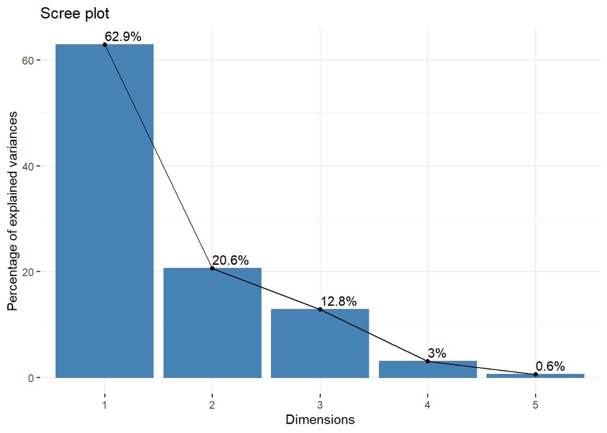

```r
fviz_screeplot(res.pca, # Objet contenant les résultats de l'ACP réalisé précédemment avec la fonction PCA()

               addlabels=TRUE)# Ajoute les étiquettes numériques au-dessus des barres du scree plot
```

Ce graphique représente un Scree plot, couramment utilisé pour analyser les résultats d’une analyse en composantes principales.

Les barres bleues montrent le pourcentage de la variance expliquée par chaque dimension (ou composante principale).

La Dimension 1 explique 62.9% de la variance des données. C’est la composante la plus importante. La Dimension 2 explique 20.6% de la variance. La Dimension 3 explique 12.8%, et ainsi de suite. La variance expliquée diminue considérablement à partir de la troisième dimension.

La ligne noire montre la pente de la courbe de l’échelle des variances expliquées. On voit que la pente diminue fortement après la première dimension, ce qui est un indicateur classique du fait que les premières composantes sont très informatives et que la valeur ajoutée des dimensions suivantes devient marginale.

Selon le “knee point” (le point d’inflexion), on peut déterminer combien de dimensions (ou composantes principales) doivent être conservées pour l’analyse. Dans ce cas, la première et la deuxième composantes expliquent ensemble plus de 80% de la variance. Après, les dimensions 3 à 5 expliquent de moins en moins de variance et ont donc un impact réduit sur la compréhension des données.

## Contributions des variables

```r
kable(res.pca$var$contrib,  # Extraction des contributions des variables depuis l'objet PCA

      caption = "Contributions des variables ") %>% # Titre du tableau

  kable_styling(full_width = FALSE, # Le tableau n'utilisera pas toute la largeur disponible

                position = "center",# Le tableau est centré horizontalement dans la page

                bootstrap_options = c("striped", # "striped" : alternance de couleurs pour les lignes (zébrage)
                                      "hover")) %>%  # "hover" : surbrillance d'une ligne au passage de la souris (utile pour l'interactif)
  column_spec(1, bold = TRUE)# la première colonne est en gras
```

Contributions des variables

|  | Dim.1 | Dim.2 | Dim.3 | Dim.4 | Dim.5 |
| --- | --- | --- | --- | --- | --- |
| Year | 0.3995528 | 89.6438558 | 9.773504 | 0.1323346 | 0.0507532 |
| Estimated_prevalence | 27.4699946 | 0.6807842 | 13.358339 | 21.2335780 | 37.2573036 |
| Mortalite_sans_VIH | 24.8393406 | 1.7872764 | 18.780044 | 51.9966752 | 2.5966638 |
| Mortalite_avec_VIH | 17.6350464 | 6.5980164 | 56.307664 | 8.0546902 | 11.4045832 |
| Estimated_incidence | 29.6560655 | 1.2900672 | 1.780449 | 18.5827219 | 48.6906962 |

Ces colonnes représentent les contributions de chaque variable à chaque dimension principale (Dim1, Dim2, etc.) de l’ACP.

Dim.1 représente la première composante principale qui explique la majeure partie de la variance dans les données (62.94% comme observé précédemment).

Dim.2 à Dim.5 représentent les autres dimensions principales qui expliquent respectivement une part de la variance de moindre importance.

Les valeurs dans les cellules montrent la contribution de chaque variable à la dimension correspondante. Plus la valeur est élevée, plus cette variable est importante pour la dimension donnée.

Analyse des contributions : “Year” :

Dim.1 : La contribution de Year à Dim.1 est relativement faible (0.3995528). Cela signifie que bien que l’année puisse avoir une influence sur la première composante, son impact est modéré.

Dim.2 : Year a une contribution élevée (89.64%) à Dim.2, ce qui indique que Dim.2 est fortement influencée par la variation temporelle dans les données, comme on l’a observé lors de l’analyse du cercle de corrélation.

“Estimated_prevalence” :

Dim.1 : Cette variable a une contribution importante à Dim.1 (27.47%). Cela montre qu’elle est l’une des principales variables influençant cette première dimension.

Dim.2 : Sa contribution à Dim.2 est faible (0.68%), suggérant qu’elle joue un rôle moins important dans cette deuxième dimension.

Dim.3 : Cependant, Estimated_prevalence a une contribution significative à Dim.3 (13.36%), ce qui indique que cette variable est aussi importante dans cette dimension secondaire.

“Mortalite_sans_VIH” :

Dim.1 : Mortalite_sans_VIH contribue également de manière significative à Dim.1 (24.84%), ce qui la rend importante pour la première composante principale.

Dim.4 : Une contribution très élevée (51.99%) à Dim.4 montre qu’elle explique une grande partie de la variance pour cette dimension.

“Mortalite_avec_VIH” :

Dim.1 : Cette variable a une contribution modérée à Dim.1 (17.64%), mais elle devient plus significative dans les dimensions suivantes.

Dim.2 : Elle contribue 6.60% à Dim.2, ce qui la place parmi les variables influentes pour cette dimension secondaire.

Dim.3 : Sa contribution à Dim.3 (56.31%) est notable, montrant que la mortalité liée au VIH est très présente dans cette dimension.

“Estimated_incidence” :

Dim.1 : Cette variable a une forte contribution à Dim.1 (29.66%), ce qui en fait une variable clé pour expliquer la variance dans la première dimension, comme on l’a observé lors de l’analyse du cercle de corrélation.

Dim.2 : La contribution à Dim.2 est faible (1.29%), indiquant que l’incidence a un impact limité sur cette deuxième dimension.

Interprétation générale : Dim.1 est influencée par plusieurs variables, notamment Estimated_prevalence et Estimated_incidence, qui contribuent fortement à cette composante principale. Year et Mortalite_sans_VIH ont également un impact sur cette dimension, bien que plus faible.

Dim.2 semble être dominée par Year, qui a une contribution écrasante à cette dimension. D’autres variables, comme Mortalite_avec_VIH et Estimated_prevalence, ont des contributions relativement faibles sur cette dimension.

Analysons les individus qui ont contibué à la formation des axes de notre cercle de corrélation :

##plan des individus par années (1990-2013)

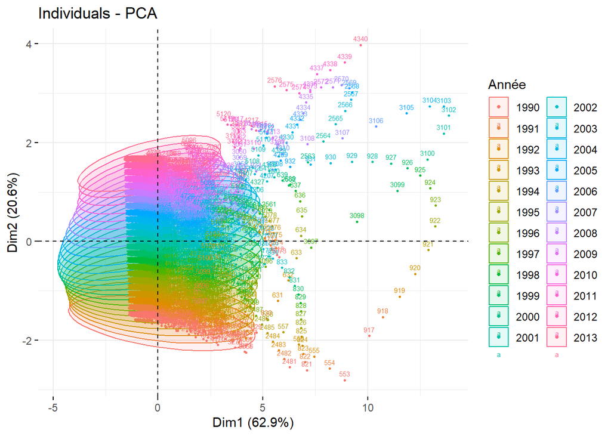

```r
#plan des individus par année
fviz_pca_ind(res.pca, # Objet contenant les résultats de l'ACP précédemment calculée

             labelsize = 2,  # Taille des étiquettes des individus (les noms/identifiants)

             geom.ind = c("point", "text"),    # Affiche les individus sous forme de points et de textes (étiquettes)

             col.ind = as.factor(TB2_ACP$Year),  # Colore les points en fonction de l'année (TB2_ACP$Year)

              pointshape = 19, #point rond plein

             pointsize = 0.5, #taille des ronds pleins

             addEllipses = T,            # Ajouter des ellipses de concentration autour des groupes d'individus

             legend.title = "Année")  # Titre de la légende qui indiquera les années en couleur
```

Ce graphique représente un plan des individus dans le cadre de l’Analyse en Composantes Principales (ACP), avec les axes Dim1 (62.9%) et Dim2 (20.6%) représentant les deux premières composantes principales.

Les points sont répartis sur les axes Dim1 (abscisse) et Dim2 (ordonnée). On remarque que la majorité des individus se situent dans les zones délimitées par les valeurs de Dim1 comprises entre environ -2,5 et 2 et celles de Dim2 entre -2 et 2. Cette concentration suggère qu’il existe une certaine variabilité entre les individus au fil des années, tout en mettant en évidence une évolution temporelle des données.

Les individus des années 1990 se trouvent proches de -2 sur l’axe Dim2, tandis que chaque année suivante montre une progression ascendante sur cet axe. En 2013, les individus atteignent une position proche de +2 sur Dim2. Cette évolution suggère que, au fil des années, les caractéristiques des individus (telles que la prévalence, l’incidence, ainsi que la mortalité liée au VIH et sans VIH) ont évolué de manière graduelle.Cette montée sur Dim2 reflète des améliorations dans les indicateurs de santé au fil du temps, influencées par des changements dans les politiques publiques, les traitements ou la collecte des données.

Les individus des années anciennes (1990-1995) sont répartis sur une plus grande étendue de l’espace des composantes principales, notamment sur l’axe Dim2, où certains points se trouvent proches de -2, tandis que d’autres sont plus éloignés. Cela pourrait indiquer une diversité dans les caractéristiques des données (comme la prévalence, l’incidence et la mortalité), ou une gestion moins homogène de la tuberculose à cette époque.

En revanche, les années récentes (2000 et au-delà) montrent une concentration plus marquée des points, notamment autour de 0 à 2 sur Dim2. Cela suggère que les données des années plus récentes sont plus homogène, ce qui pourrait refléter des changements dans les politiques de santé publique, des améliorations dans les traitements, ou encore une collecte des données plus précise et plus uniforme.

En résumé, ce graphique illustre l’évolution des individus selon les années et leur répartition dans l’espace des deux premières composantes principales. L’évolution au fil du temps, avec la tendance à une concentration accrue des points dans les années récentes, laisse entrevoir une influence plus homogène des facteurs de santé publique, une gestion améliorée de la tuberculose, ou encore des changements sociaux.

Cela suggère que les données se sont progressivement normalisées au fil du temps, avec des changements dans les politiques de santé publique, la gestion des traitements et une meilleure collecte des données. Une analyse de classification pourrait être une étape suivante intéressante pour identifier des groupes distincts et mieux comprendre les tendances sous-jacentes des données, telles que des clusters d’années ou des régions ayant des caractéristiques similaires en termes de mortalité ou de prévalence de la tuberculose.

## III.1) Méthode de Ward : Année 2000

###Classification hiérarchique

Maintenant, nous allons nous concentrer exclusivement sur l’année 2000 pour la suite de l’analyse, en raison du nombre élevé de valeurs disponibles. Cette approche nous permettra de simplifier l’interprétation des résultats tout en conservant des données pertinentes et significatives. Nous commencerons par réaliser un arbre hiérarchique selon la méthode de Ward, suivi de l’analyse de l’inertie et du clustering basé sur cette même méthode, afin de mieux comprendre la structure des groupes de pays en 2000. Cette focalisation sur l’année 2000 nous aidera à obtenir des résultats plus clairs et précis pour cette période spécifique.

Dans un premier temps, construisons une matrice de distance, puis l’arbre de classification :

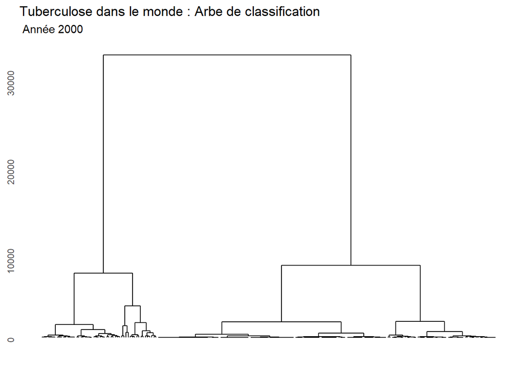

```r
TB2_ACP_2000 <- TB2_ACP %>%
  filter(Year == 2000) # on prend que les valeurs de TB2_ACP correspondant à l'année 2000

matrice.distance.pays<-dist(TB2_ACP_2000[,3:7]) #on crée un objet matrice.distance.pays, la matrice de distance euclidienne par défaut

tb.clust<-hclust(matrice.distance.pays, method="ward.D")#on crée un objet tb.clusr, suivant la méthode de ward.

ggdendrogram(tb.clust, rotate = FALSE, size=2)+
  labs(title = "Tuberculose dans le monde : Arbe de classification",
       subtitle  =" Année 2000") +
    theme(axis.text.x = element_blank())  # Supprimer les labels des axes X : L'option theme(axis.text.x = element_blank()) a été utilisée pour supprimer les labels sur l'axe des X afin de mieux visualiser la structure générale de l'arbre sans surcharger l'affichage avec trop de texte.
```

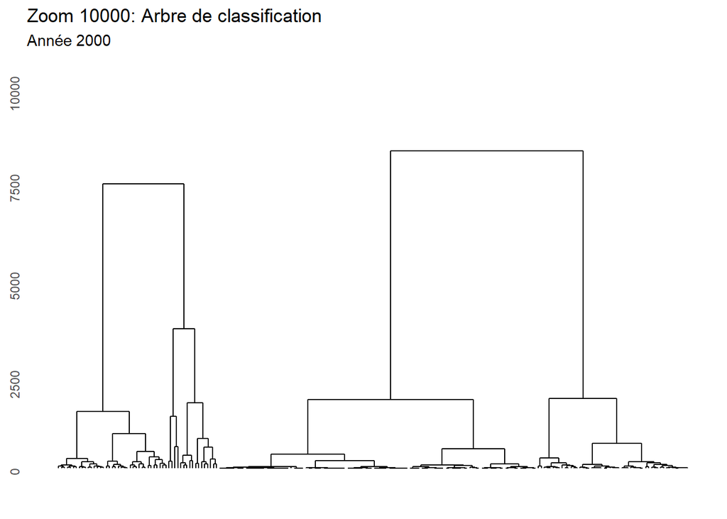

```r
# On limite les branches pour zoomer à partir d'une distance de 10000
ggdendrogram(tb.clust, rotate = FALSE, size = 2) +
  labs(title = "Zoom 10000: Arbre de classification",
       subtitle = "Année 2000") +
  theme(axis.text.x = element_blank()) +  # Suppression des labels des axes X
  scale_y_continuous(limits = c(0, 10000))  # Limite l'axe des Y à 10000 pour un meilleur zoom
```

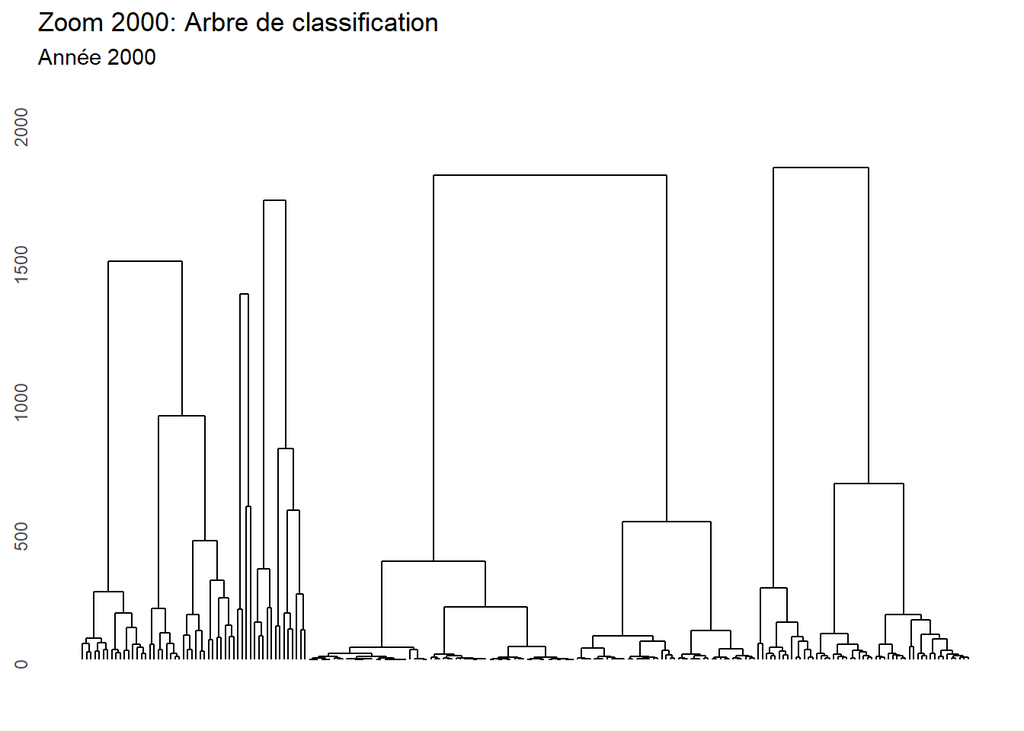

```r
# On limite les branches pour zoomer à partir d'une distance de 1000
ggdendrogram(tb.clust, rotate = FALSE, size = 2) +
  labs(title = "Zoom 2000: Arbre de classification",
       subtitle = "Année 2000") +
  theme(axis.text.x = element_blank()) +  # Suppression des labels des axes X
  scale_y_continuous(limits = c(0, 2000))  # Limite l'axe des Y à 2000 pour un meilleur zoom
```

L’arbre de classification, également appelé dendrogramme, représente la structure de regroupement des pays en fonction des variables choisies (par exemple, la prévalence, l’incidence et la mortalité de la tuberculose) pour l’année 2000.

Tout en bas, on a tous les pays de notre jeu de donnée mais étant trop nombreaux, on a supprimé les labels des axes X. Ajouter tous les labels pourrait rendre l’arbre illisible et encombré.

Concernant la structure de l’abre, on observe une hiérarchie de regroupement des pays en fonction de leurs similitudes. Les pays qui sont plus proches dans l’arbre ont des caractéristiques similaires (en termes de prévalence, incidence et mortalité de la tuberculose).

Plus on va haut dans l’abre, plus les objets regroupées sont éloignés. L’axe vertical montre la distance ou dissimilarité entre les groupes. Les grandes distances entre les branches indiquent des différences marquées entre les groupes, tandis que les petites distances montrent des pays ou groupes similaires.

On observe ici, deux grands clusters divisés eux mêmes en deux clusters, divisés en deux clusters également.

À partir de l’arbre de classification, on peut identifier différents groupes de pays qui présentent des caractéristiques épidémiologiques similaires concernant la tuberculose en 2000. Ces groupes pourraient être analysés plus en détail pour comprendre les facteurs communs influençant la tuberculose dans ces pays.

Le clustering hiérarchique, effectué à l’aide de la méthode Ward.D, a permis de regrouper les pays en fonction de leur proximité sur les variables étudiées.

L’absence de labels dans l’arbre n’empêche pas l’analyse de la structure des clusters. Cependant, malgré une tentative de zoom, le nombre élevé de valeurs reste trop important pour les identifier efficacement uniquement à l’aide de cet arbre de classification

Pour choisir le nombre de classes, on peut faire une approche à l’aide de cette figure, ce qui revient à construire un diagramme d’intertie.

### Diagramme d’inertie

Afin de regouper les individus similaires ou classes similaires, on choisit une mesure de similarité entre les invidus et entre les classes, suite au calcul de la matrice de distance. À l’itération, chaque observation forme sa propre classe.

On calcule pour chaques classes son inertie et on la somme pour toutes les classes :

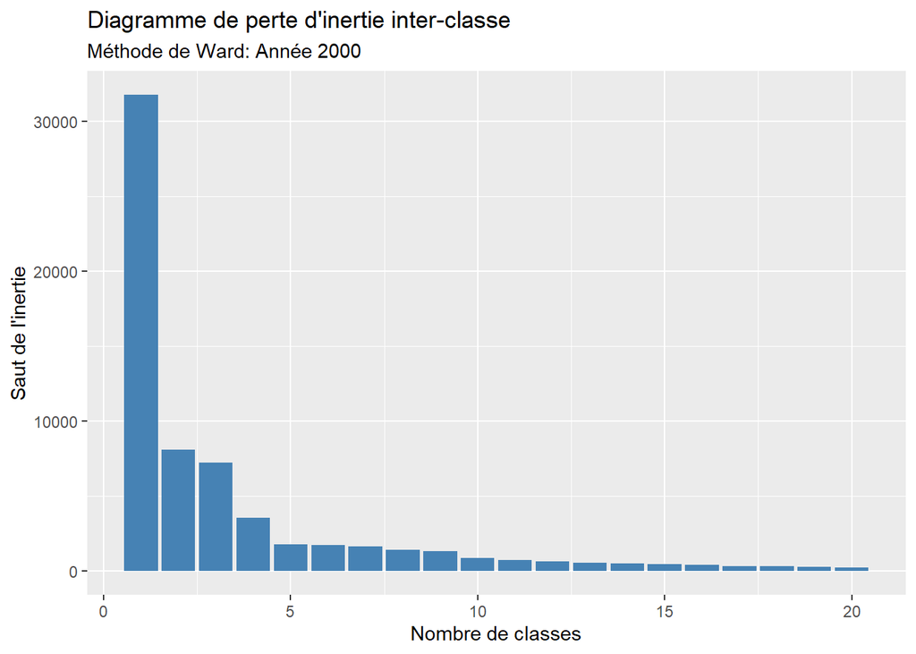

```r
# Trier les hauteurs de l'arbre de classification par ordre décroissant
inertie <-sort(tb.clust$height, decreasing = T)

# Création d'un tibble pour les 20 premières valeurs d'inertie

ggplot(tibble(
  x = c(1:20), # Crée une colonne 'x' avec les indices 1 à 20 représentant le nombre de classes

  y = inertie[1:20]), # Crée une colonne 'y' avec les 20 premières valeurs d'inertie

       aes(x = x, y = y)) + # Spécifie les axes x et y pour le graphique

  # Ajout d'un graphique en barres
  geom_bar(
    stat = "identity", # Utilise les valeurs exactes des données pour la hauteur des barres

    fill = "steelblue") + # Remplissage des barres avec la couleur bleu

  labs(
    title = "Diagramme de perte d'inertie inter-classe",# Titre du graphique
    subtitle = "Méthode de Ward: Année 2000", # Sous-titre

    x = "Nombre de classes",# Label de l'axe x

    y = "Saut de l'inertie"  # Label de l'axe y
  )
```

Pour avoir une bonne classification, on veut que les variables des couples soit éloignée. Maximiser l’inertie inter revient à minimiser l’intertie intra.

De ce fait, on va prendre les classes avec le plus grand statue d’inertie.

La hauteur de chaque barres correspond aux sauts de l’inertie.

La plus grande perte de l’inertie inter correspond à la plus grande fusion, des deux classes les plus éloignées donc la toute dernière fusion.

La hauteur de la deuxième barre correspond à la fusion des deux branches les plus proches à droite dans l’arbre de classification. La troisième barre représente la fusion des deux branches qui ont été fusionnées immédiatement après celles à droite. Ensuite, chaque barre suivante correspond à une fusion successive des clusters.

On peut appliquer la règle du coude à ce graphique pour déterminer le nombre optimal de clusters. En observant la transition entre la quatrième et la cinquième barre, on remarque que les barres suivantes ont toutes à peu près la même hauteur. Cela indique qu’à partir de ce point, les fusions suivantes ne diminuent plus significativement l’inertie, ce qui suggère qu’il n’est plus pertinent d’ajouter davantage de clusters.

Ainsi, la règle du coude nous aide à identifier le point où la réduction de l’inertie devient marginale, ce qui permet de choisir un nombre de classes qui capture efficacement la structure des données sans trop de division.

On peut donc interpéter qu’au :

- Passage de 1 à 2 clusters : Nous observons une forte diminution de l’inertie entre 1 et 2 clusters. Cela indique qu’en ajoutant un deuxième cluster, la séparation entre les groupes devient beaucoup plus nette, et les données sont mieux séparées.
- Passage de 2 à 3 clusters : Une réduction significative de l’inertie est visible entre 2 et 3 clusters. Cela suggère qu’avec 3 clusters, la séparation des groupes devient encore plus précise par rapport à 2, bien que l’impact soit moins marqué que celui observé entre 1 et 2 clusters.
- Passage de 3 à 4 clusters : À ce stade, la diminution de l’inertie devient moins importante. L’ajout d’un quatrième cluster améliore encore légèrement la séparation, mais l’impact est plus faible que lors des précédentes transitions.
- Passage de 4 à 5 clusters : À partir de 4 clusters, la réduction de l’inertie devient marginale. Les barres deviennent beaucoup plus courtes, ce qui montre que l’ajout d’un cinquième cluster n’apporte plus une réelle amélioration dans la réduction de l’inertie.

Nous pouvons conclure que 3 ou 4 clusters sont des choix raisonnables pour structurer les données. Après observation des résultats, nous estimons que le nombre optimal de clusters est 4, ce qui est également confirmé par l’analyse de l’arbre hiérarchique.

Nous allons maintenant examiner les plans par individus ainsi que les arbres hiérarchiques pour les classes de 1 à 4, car au-delà de 4, l’ajout de nouveaux clusters ne semble plus pertinent ni optimal.

###sortie de clustering hierarchique comme variable d’illustration de l’ACP 2000

Nous commençons par générer les étiquettes des clusters en utilisant la méthode de Ward pour effectuer un clustering hiérarchique. Nous appliquons la fonction cutree qui sur l’objet tb.clust, qui contient le résultat du clustering hiérarchique effectué avec la méthode de Ward. La fonction cutree() découpe un arbre de classification en un certain nombre de clusters. En d’autres termes, elle prend l’arbre hiérarchique obtenu par la méthode de Ward et le “coupe” à une hauteur spécifiée, produisant ainsi un nombre donné de groupes. Chaque groupe représente un cluster, et chaque observation est assignée à un de ces groupes. Nous définissons les clusters avec 2, 3 et 4 groupes, et stockons les résultats dans les variables labels2, labels3 et labels4:

```r
labels2 <- cutree(tb.clust, k = 2) # on coupe l'arbre à l'endroit où on a 2 branches

labels3 <- cutree(tb.clust, k = 3)# on coupe l'arbre pour avoir 3 branches

labels4 <- cutree(tb.clust, k = 4)# on coupe l'arbre pour avoir 4 branches
```

Ensuite, nous créons un nouveau tableau TB2_ACP_2000_2 qui contient les données des colonnes 3 à 7 de TB2_ACP_2000, ainsi que les étiquettes des clusters obtenues pour 2, 3 et 4 groupes. Nous convertissons les labels en caractères afin de pouvoir les utiliser dans l’ACP :

```r
TB2_ACP_2000_2<- as.data.frame(cbind(TB2_ACP_2000[,3:7],labels2, labels3, labels4) )
TB2_ACP_2000_2[,6]= as.character(TB2_ACP_2000_2[,6])
TB2_ACP_2000_2[,7]= as.character(TB2_ACP_2000_2[,7])
TB2_ACP_2000_2[,8]= as.character(TB2_ACP_2000_2[,8])
```

Enfin, nous réalisons l’ACP sur ce tableau enrichi, en spécifiant les variables qualitatives supplémentaires (les labels des clusters). Nous appliquons la standardisation des données avec scale.unit = TRUE, et nous choisissons de ne pas afficher les graphiques avec graph = FALSE:

```r
res.pca2000 <- PCA(TB2_ACP_2000_2, quali.sup=c(6,7,8), scale.unit= TRUE,graph = FALSE)
```

###visualisations des clusters sur CP1-CP2 : 2 classes

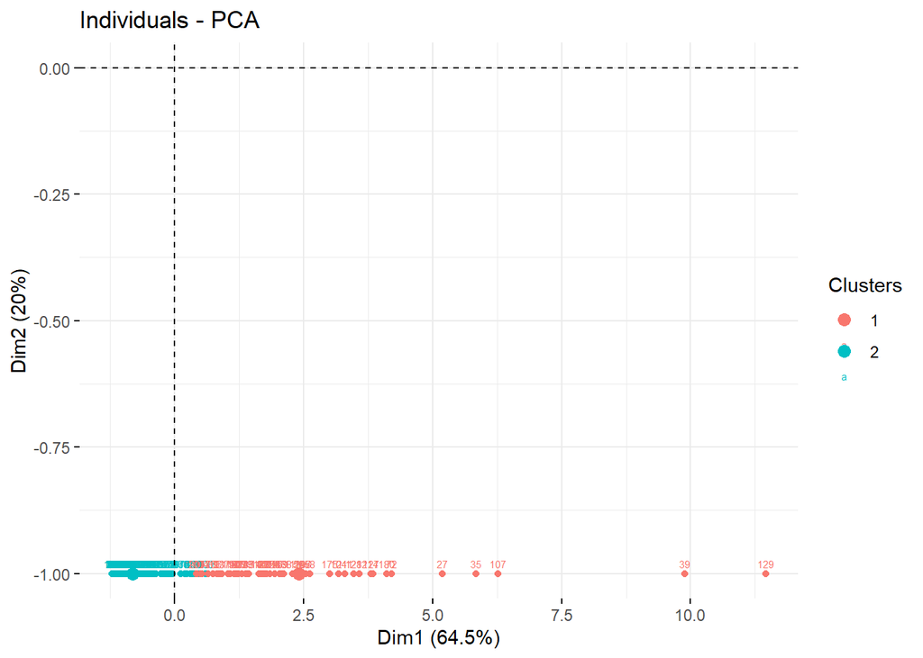

```r
fviz_pca_ind(res.pca2000,  # Objet contenant les résultats de l'ACP pour l'année 2000

             geom.ind = c("point", "text"), # Affichage des individus sous forme de points et de texte (étiquettes)

             labelsize = 2, # Taille des étiquettes des individus

             col.ind = TB2_ACP_2000_2$labels2,# Coloration des points en fonction des labels de clusters

              pointshape = 19,   #points ronds pleins
             legend.title = "Clusters") # Titre de la légende
```

Le graphique représente le plan des individus projetés sur les deux premières composantes principales (Dim1 et Dim2) après une ACP, avec un clustering en 2 classes. Voici ce que l’on peut en déduire :

- Dim1 (64.5%) : Cette composante principale explique 64.5% de la variance des données, ce qui en fait la dimension la plus importante pour la distinction des groupes.
- Dim2 (20%) : Cette deuxième composante principale explique 20% de la variance, représentant une part plus faible de l’information restante.

Le graphique utilise deux couleurs pour distinguer les deux classes du clustering : - Les points rouges représentent les individus appartenant à la classe 1. - Les points bleus représentent les individus appartenant à la classe 2.

Les étiquettes des points (les numéros affichés près de chaque point) correspondent aux indices des observations dans le jeu de données. Cela permet de suivre les observations spécifiques et d’analyser plus en détail comment elles se répartissent dans les deux classes.

Sur l’axe Dim2, bien que les classes semblent bien séparées le long de Dim1, il y a un certain chevauchement des classes sur Dim2. Cela suggère que Dim2 n’est pas aussi discriminante que Dim1 pour cette séparation. La dispersion sur Dim2 reste limitée, ce qui indique que la séparation des classes repose principalement sur la première composante.

La séparation des deux classes (rouge et bleue) est plus marquée le long de Dim1. Les points rouges (classe 1) et les points bleus (classe 2) sont bien séparés horizontalement, ce qui montre que Dim1 est l’axe principal pour distinguer les deux groupes. Sur Dim2, bien qu’il y ait encore une séparation, celle-ci est moins nette. Cela veut dire que la distinction entre les groupes n’est pas aussi forte le long de Dim2. C’est pour cela que l’on dit que Dim2 a un impact limité par rapport à Dim1 pour la séparation des classes.

Le graphique met donc en évidence que les deux classes sont relativement distinctes sur la première composante principale (Dim1), ce qui signifie que Dim1 est la composante principale permettant de distinguer ces deux groupes. La faible dispersion sur Dim2 suggère que cette composante a une influence moindre pour cette séparation spécifique.

Montrons maintenant ces classes/groupes sur l’arbre hiérarchique pour visualiser la structure du clustering.

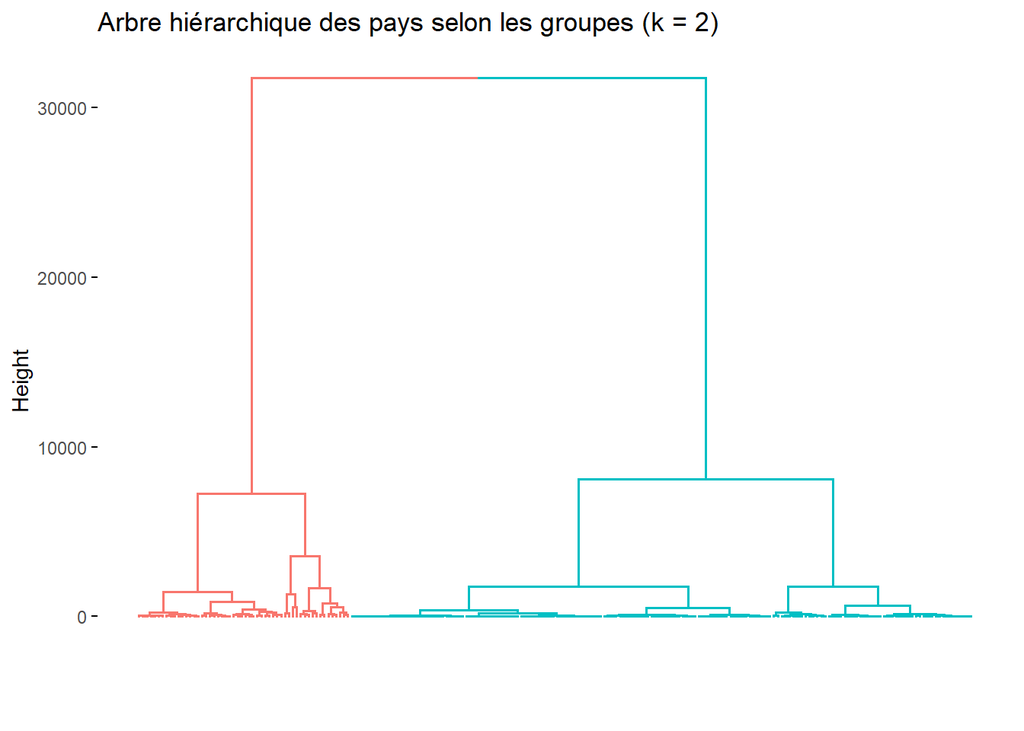

```r
fviz_dend(tb.clust,  # Objet contenant l'arbre de classification hiérarchique

          k = 2,  # Découpe en 2
          show_labels = FALSE,# Ne pas fficher les étiquette
          main = "Arbre hiérarchique des pays selon les groupes (k = 2)")# Titre
```

Les résultats du clustering révèlent des groupes distincts. Pour aller plus loin, nous pouvons analyser en détail ce qui distingue les individus des deux classes, en se basant sur les variables d’origine (par exemple, la prévalence, l’incidence ou la mortalité de la tuberculose).

Maintenant, nous allons afficher un tableau récapitulatif dans lequel nous verrons les pays associés à chaque groupe ou cluster ainsi que le pourcentage des régions qui appartiennent à chaque groupe. Ce tableau permettra de mieux comprendre la composition géographique des groupes formés par le clustering.

Le tableau inclura les éléments suivants :

- Les pays regroupés par cluster : Pour chaque groupe, nous afficherons le nom des pays qui lui sont associés, séparés par un point-virgule pour une meilleure lisibilité.
- Le pourcentage de chaque région dans chaque groupe : Pour chaque groupe, nous afficherons le pourcentage de pays de chaque région qui lui est associé. Cela permettra de visualiser la distribution géographique des groupes.

Il fournira une vue d’ensemble sur la manière dont les pays sont répartis dans chaque groupe, ainsi que la représentation géographique de ces groupes en termes de régions.

Voici le tableau qui sera généré, utilisant les résultats du clustering, des régions et des pourcentages par région pour chaque groupe :

```r
# Créer un tableau avec les pays regroupés par cluster
groupes2 <- split(TB2_ACP_2000$Country, labels2)

# Ajouter les régions pour chaque pays
regions <- TB2_ACP_2000$Region

# Créer une table de fréquence pour les pays par région
table_regions <- table(TB2_ACP_2000$Region)

# Calculer le pourcentage de chaque groupe par région
groupes_regions <- lapply(groupes2, function(group) {
  # Extraire les régions des pays dans le groupe
  group_regions <- regions[TB2_ACP_2000$Country %in% group]

  # Calculer le pourcentage de chaque région dans le groupe
  region_percentage <- table(group_regions) / length(group) * 100  # On divise par la taille du groupe pour obtenir un pourcentage
  return(region_percentage)
})

# Créer un tableau avec une ligne pour chaque groupe et les pays séparés par ";"
tableau_groupes <- data.frame(Groupe = paste("Groupe", 1:length(groupes2)),
                              Pays = sapply(groupes2, function(x) paste(x, collapse = "; ")),
                              Pourcentage = sapply(groupes_regions, function(x) paste(names(x), "=", round(x, 2), "%", collapse = "; ")))

# Afficher le tableau avec kable
kable(tableau_groupes,
      caption = "Répartition des pays dans chaque groupe (k = 2) avec les pourcentages des pays par région dans chaque groupe",
      align = "c") %>%
  kable_styling(full_width = FALSE, position = "center",
                bootstrap_options = c("striped", "hover")) %>%
  column_spec(1, bold = TRUE)
```

Répartition des pays dans chaque groupe (k = 2) avec les pourcentages des pays par région dans chaque groupe

| Groupe | Pays | Pourcentage |
| --- | --- | --- |
| Groupe 1 | Afghanistan; Angola; Azerbaijan; Bangladesh; Bhutan; Botswana; Burundi; Cambodia; Cameroon; Central African Republic; Congo; Côte d’Ivoire; Democratic People’s Republic of Korea; Democratic Republic o… | AFR = 50 %; AMR = 1.85 %; EMR = 7.41 %; EUR = 11.11 %; SEA = 11.11 %; WPR = 18.52 % |
| Groupe 2 | Albania; Algeria; American Samoa; Andorra; Anguilla; Antigua and Barbuda; Argentina; Armenia; Aruba; Australia; Austria; Bahamas; Bahrain; Barbados; Belarus; Belgium; Belize; Benin; Bermuda; Bolivia (… | AFR = 12.03 %; AMR = 27.85 %; EMR = 11.39 %; EUR = 29.75 %; SEA = 2.53 %; WPR = 16.46 % |

Le groupe 1 est principalement composé de pays situés en Afrique (AFR) et en Pacifique occidental (WPR), avec une forte dominance de l’Afrique, représentant 50% du groupe. La région Pacifique occidentale (WPR) suit avec 18,52% des pays, ce qui montre la prépondérance de ces régions dans ce groupe. D’autres régions, telles que l’Asie du Sud-Est (SEA) représente 11,11% du groupe, bien que sa contribution soiet plus limitée.Les pays de ce groupe, représentant principalement des régions en développement, sont confrontés à des défis importants en termes de croissance démographique et d’infrastructures de santé. La mortalité et la prévalence des maladies comme la tuberculose peuvent varier largement en fonction de la qualité des politiques de santé publique et du niveau de développement des infrastructures dans ces pays.

Le groupe 2 est largement dominé par les pays de l’Europe (EUR), qui représentent 29,75% du groupe, suivis par l’Amérique latine (AMR) avec 27,85%. En comparaison avec le groupe 1, ce groupe est principalement composé de pays développés. L’Afrique (AFR), bien que présente, constitue seulement 12,03% du groupe. L’Asie du Sud-Est (SEA) représente une petite part avec 2,53%, ce qui met en évidence la concentration de pays européens et latino-américains dans ce groupe.

Les pays du groupe 2 sont généralement caractérisés par des économies plus avancées, une meilleure infrastructure de santé et une plus grande homogénéité en termes de développement socio-économique. Les politiques de santé publique dans ces régions sont généralement plus structurées et cohérentes, ce qui explique les différences de mortalité et d’incidence des maladies par rapport au groupe 1.

Cette répartition géographique montre une nette différence dans les niveaux de développement économique, de santé publique et d’infrastructure entre les deux groupes, ce qui peut influencer les tendances en matière de prévalence, de mortalité ou d’incidence des maladies comme la tuberculose dans ces pays.

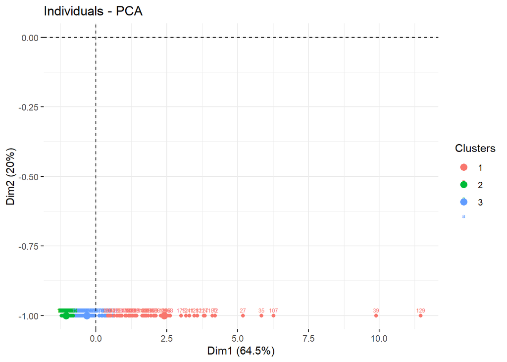

```r
fviz_pca_ind(res.pca2000, # Objet contenant les résultats de l'ACP pour l'année 2000

             geom.ind = c("point", "text"),# Affichage des individus sous forme de points et de texte (étiquettes)

             labelsize = 2, # Taille des étiquettes des individus

             col.ind = TB2_ACP_2000_2$labels3, # Coloration des points en fonction des labels de clusters
              pointshape = 19,
             legend.title = "Clusters")
```

Le graphique utilise trois couleurs pour distinguer les trois classes du clustering : les points rouges représentent les individus appartenant à la classe 1, les points verts représentent les individus appartenant à la classe 2 et les points bleus représentent les individus appartenant à la classe 3.

Les trois clusters sont relativement bien séparés sur Dim1, la composante principale expliquant la majorité de la variance. Dim1 est donc la dimension la plus importante pour différencier les groupes. Cependant, la séparation sur Dim2 n’est pas aussi nette, bien que Dim2 joue un rôle secondaire dans la discrimination des groupes. Le Cluster 1 (rouge) est le plus distinct des autres, tandis que Cluster 2 (vert) et Cluster 3 (bleu) se chevauchent davantage, en particulier sur l’axe Dim2.

L’évolution des couleurs et de la répartition des groupes montre que les dimensions principales de l’analyse expliquent bien les différences entre les groupes.

Ainsi, les résultats du clustering révèlent trois groupes distincts, et ces groupes peuvent être analysés plus en détail pour comprendre ce qui les distingue, en s’appuyant sur les variables d’origine.

Montrons maintenant ces classes/groupes sur l’arbre hiérarchique pour visualiser la structure du clustering :

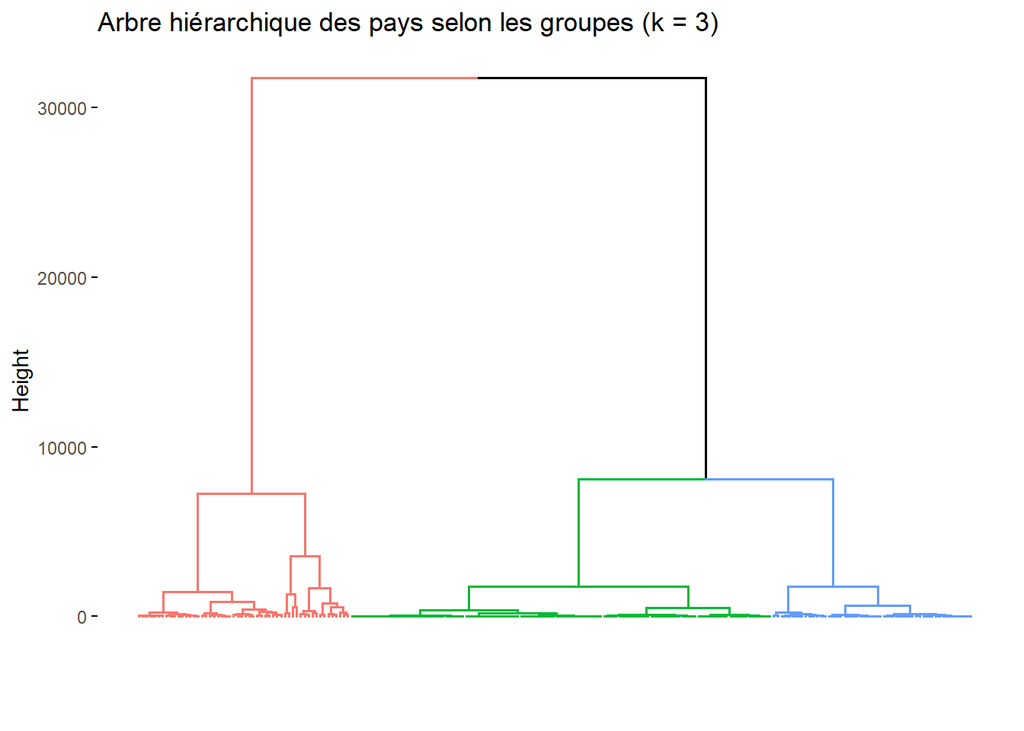

```r
fviz_dend(tb.clust,   # Objet contenant l'arbre de classification hiérarchique (issu de hclust)

          k = 3,  # Découpe en 3

          show_labels = FALSE,         # ne pas afficher les étiquette
          main = "Arbre hiérarchique des pays selon les groupes (k = 3)")# titre
```

Cet arbre hiérarchique révèle trois clusters distincts de pays, chacun ayant des caractéristiques qui les différencient des autres, avec une séparation plus marquée entre le groupe rouge et les autres. Les groupes vert et bleu, quant à eux, montrent une similarité relative, bien qu’ils soient distincts l’un de l’autre à des niveaux plus bas de l’arbre. Cela suggère une certaine hétérogénéité entre les pays, mais aussi des regroupements naturels.

Maintenant, nous allons afficher un tableau récapitulatif dans lequel nous verrons les pays associés à chaque groupe ou cluster ainsi que le pourcentage des régions qui appartiennent à chaque groupe. Ce tableau permettra de mieux comprendre la composition géographique des groupes formés par le clustering.

Ce tableau fournira une vue d’ensemble sur la manière dont les pays sont répartis dans chaque groupe, ainsi que la représentation géographique de ces groupes en termes de régions.

Le voici :

```r
# Créer un tableau avec les pays regroupés par cluster
groupes3 <- split(TB2_ACP_2000$Country, labels3)

# Ajouter les régions pour chaque pays
regions <- TB2_ACP_2000$Region

# Créer une table de fréquence pour les pays par région
table_regions <- table(TB2_ACP_2000$Region)

# Calculer le pourcentage de chaque groupe par région, en normalisant les pourcentages par groupe
groupes_regions <- lapply(groupes3, function(group) {
  # Extraire les régions des pays dans le groupe
  group_regions <- regions[TB2_ACP_2000$Country %in% group]

  # Calculer la table de fréquence pour les régions dans ce groupe
  group_region_count <- table(group_regions)

  # Normaliser pour obtenir le pourcentage de chaque région dans ce groupe
  region_percentage <- (group_region_count / length(group)) * 100

  return(region_percentage)
})

# Créer un tableau avec une ligne pour chaque groupe et les pays séparés par ";"
tableau_groupes <- data.frame(Groupe = paste("Groupe", 1:length(groupes3)),
                              Pays = sapply(groupes3, function(x) paste(x, collapse = "; ")),
                              Pourcentage = sapply(groupes_regions, function(x) paste(names(x), "=", round(x, 2), "%", collapse = "; ")))

# Afficher le tableau avec kable
kable(tableau_groupes,
      caption = "Répartition des pays dans chaque groupe (k = 3) avec les pourcentages des pays par région dans chaque groupe",
      align = "c") %>%
  kable_styling(full_width = FALSE, position = "center",
                bootstrap_options = c("striped", "hover")) %>%
  column_spec(1, bold = TRUE)
```

Répartition des pays dans chaque groupe (k = 3) avec les pourcentages des pays par région dans chaque groupe

| Groupe | Pays | Pourcentage |
| --- | --- | --- |
| Groupe 1 | Afghanistan; Angola; Azerbaijan; Bangladesh; Bhutan; Botswana; Burundi; Cambodia; Cameroon; Central African Republic; Congo; Côte d’Ivoire; Democratic People’s Republic of Korea; Democratic Republic o… | AFR = 50 %; AMR = 1.85 %; EMR = 7.41 %; EUR = 11.11 %; SEA = 11.11 %; WPR = 18.52 % |
| Groupe 2 | Albania; American Samoa; Andorra; Anguilla; Antigua and Barbuda; Argentina; Armenia; Aruba; Australia; Austria; Bahamas; Bahrain; Barbados; Belgium; Belize; Bermuda; Brazil; British Virgin Islands; Bu… | AFR = 2.8 %; AMR = 33.64 %; EMR = 14.02 %; EUR = 34.58 %; SEA = 0.93 %; WPR = 14.02 % |
| Groupe 3 | Algeria; Belarus; Benin; Bolivia (Plurinational State of); Bosnia and Herzegovina; Brunei Darussalam; Burkina Faso; Cabo Verde; Chad; China; China, Hong Kong SAR; China, Macao SAR; Dominican Republic;… | AFR = 31.37 %; AMR = 15.69 %; EMR = 5.88 %; EUR = 19.61 %; SEA = 5.88 %; WPR = 21.57 % |

Le tableau montre la répartition des pays dans trois groupes distincts (k=3) selon des critères géographiques, avec des pourcentages pour chaque région du monde (AFR, AMR, EMR, EUR, SEA, WPR).

Analysons ces données : Le groupe 1 est principalement composé de pays issus des régions d’Afrique (AFR) et de la Pacifique occidentale (WPR). On y trouve des pays comme l’Afghanistan, le Cameroun, la Guinée, les îles Salomon, Vanuatu, ect.

- AFR (Afrique) : 50 % des pays proviennent de cette région, ce qui en fait la principale zone géographique de ce groupe.
- AMR (Amérique) : 1,85 % des pays sont américains, une proportion faible par rapport aux autres régions.
- EMR (Moyen-Orient) : 7,41 % des pays viennent du Moyen-Orient.
- EUR (Europe) : 11,11 % des pays sont européens, une proportion modeste.
- SEA (Asie du Sud-Est) : 11,11 % des pays proviennent de cette région, représentant une part significative du groupe.
- WPR (Région Pacifique occidental) : 18,52 % des pays appartiennent à cette région.

Le groupe 1 est donc majoritairement africain et asiatique, ce qui reflète la diversité géographique de cette région.

Le groupe 2 est constitué de pays d’Europe (EUR) et des Amériques (AMR), avec une présence importante des pays européens et latino-américains. Des exemples incluent l’Albanie, l’Argentine, la Belgique, le Brésil, la Colombie, etc.

- AFR (Afrique) : 2,8 % une proportion beaucoup plus faible que dans le groupe 1.
- AMR (Amérique) : 33,64 % une part significative de pays américains, en particulier de l’Amérique latine.
- EMR (Moyen-Orient) : 14,02 % une proportion notable provenant du Moyen-Orient.
- EUR (Europe) : 34,58 % c’est la région dominante de ce groupe, représentant plus d’un tiers des pays.
- SEA (Asie du Sud-Est) : 0,93 % une très faible représentation dans ce groupe.
- WPR (Région Pacifique occidental) : 14,02 % avec une proportion modérée de pays.

Le groupe 2 est donc très européen et latino-américain, avec une prépondérance de pays européens, ce qui le distingue nettement du groupe 1.

Le groupe 3 présente une répartition plus diversifiée géographiquement, avec des pays d’Afrique, d’Europe, d’Amérique et d’Asie. On y trouve des pays comme l’Algérie, le Bélarus, la Bolivie, l’Équateur, la Guinée équatoriale, etc.

Ainsi, le tableau montre une nette différenciation entre les groupes, avec des pays africains et asiatiques dominant le groupe 1, un groupe 2 très centré sur les pays américains et européens, et un groupe 3 qui présente un mélange géographique assez diversifié. Les pourcentages indiquent également que chaque groupe est composé de régions géographiques dominantes mais aussi de régions moins représentées. Le groupe 1 est principalement africain et asiatique, tandis que le groupe 2 est dominé par l’Amérique et l’Europe, et le groupe 3 présente une distribution plus équilibrée entre les différentes régions. Cela suggère des différences significatives dans la composition régionale des groupes et peut-être des différences dans les indicateurs de santé publique ou de politiques influençant ces régions.

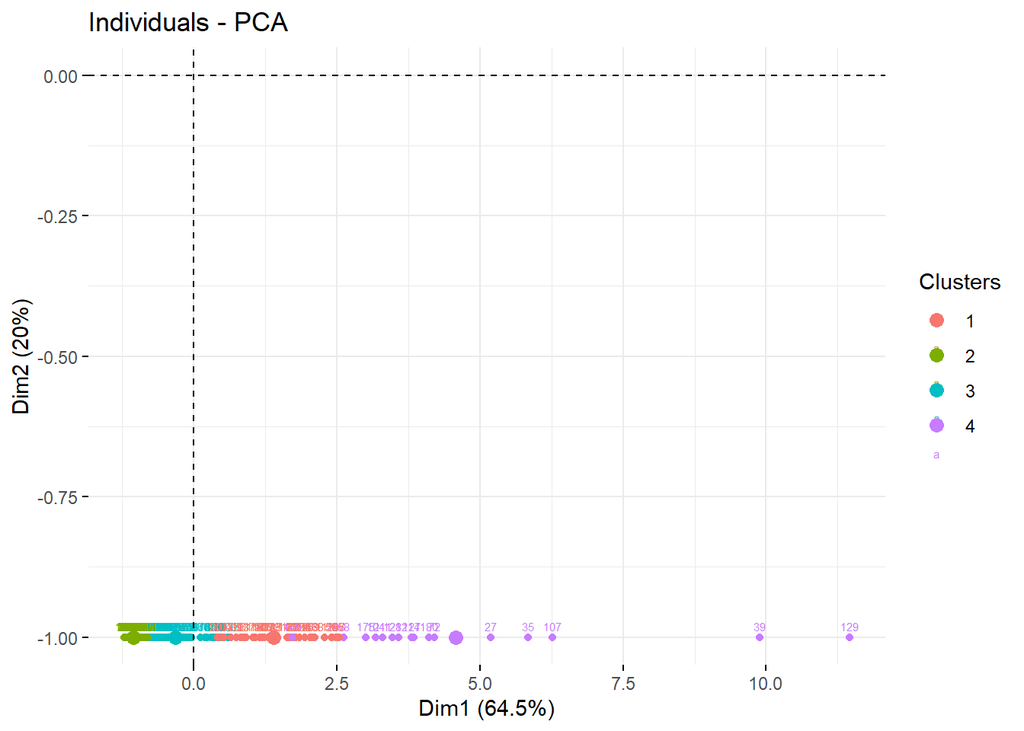

```r
fviz_pca_ind(res.pca2000, # Objet contenant les résultats de l'ACP pour l'année 2000

             geom.ind = c("point", "text"),# Affichage des individus sous forme de points et de texte (étiquettes)

             labelsize = 2, # Taille des étiquettes des individus

             col.ind = TB2_ACP_2000_2$labels4,  # Coloration des points en fonction des labels de clusters

              pointshape = 19,
             legend.title = "Clusters")# titre légende
```

En ce qui concerne Dim2, l’alignement des points dans l’axe vertical reste faible, indiquant que cette composante n’aide pas de manière significative à séparer les clusters. Cela suggère que Dim2 a une contribution mineure à la structuration des données et que la séparation principale des clusters se fait sur Dim1.

Montrons maintenant ces 4 classes/groupes sur l’arbre hiérarchique pour visualiser la structure du clustering.

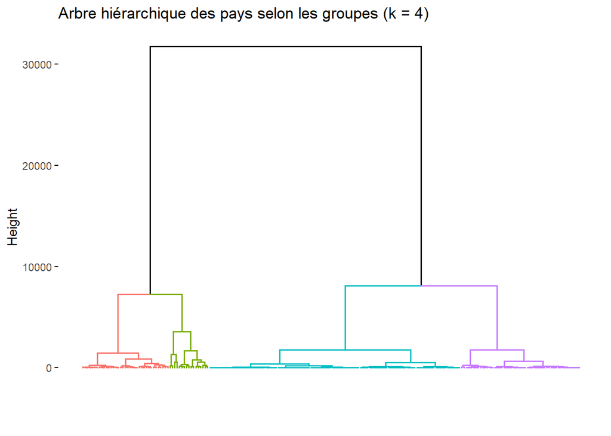

```r
fviz_dend(tb.clust,   # Objet contenant l'arbre de classification hiérarchique (issu de hclust)

          k = 4,                                  # Découpe en 4
          show_labels = FALSE, # ne pas afficher les lebels
          main = "Arbre hiérarchique des pays selon les groupes (k = 4)")  # titre
```

Cette représentation visuelle de l’arbre hiérarchique montre comment les pays sont regroupés en fonction de leurs caractéristiques, avec une séparation nette en 4 groupes. L’arbre fournit une vue d’ensemble de la structure des données et permet de visualiser les relations entre les pays selon leurs similitudes, que l’on va étudiées à l’aide du tableau récapitaluatif nous permerttant de savoir à quels pays appartiennent quelles branches.

```r
# Créer un tableau avec les pays regroupés par cluster
groupes4 <- split(TB2_ACP_2000$Country, labels4)

# Ajouter les régions pour chaque pays
regions <- TB2_ACP_2000$Region

# Créer une table de fréquence pour les pays par région
table_regions <- table(TB2_ACP_2000$Region)

# Calculer le pourcentage de chaque groupe par région, en normalisant les pourcentages par groupe
groupes_regions <- lapply(groupes4, function(group) {
  # Extraire les régions des pays dans le groupe
  group_regions <- regions[TB2_ACP_2000$Country %in% group]

  # Calculer la table de fréquence pour les régions dans ce groupe
  group_region_count <- table(group_regions)

  # Normaliser pour obtenir le pourcentage de chaque région dans ce groupe
  region_percentage <- (group_region_count / length(group)) * 100  # Diviser par la taille du groupe pour normaliser à 100%

  return(region_percentage)
})

# Créer un tableau avec une ligne pour chaque groupe et les pays séparés par ";"
tableau_groupes <- data.frame(Groupe = paste("Groupe", 1:length(groupes4)),
                              Pays = sapply(groupes4, function(x) paste(x, collapse = "; ")),
                              Pourcentage = sapply(groupes_regions, function(x) paste(names(x), "=", round(x, 2), "%", collapse = "; ")))

# Afficher le tableau avec kable
kable(tableau_groupes,
      caption = "Répartition des pays dans chaque groupe (k = 4) avec les pourcentages des pays par région dans chaque groupe",
      align = "c") %>%
  kable_styling(full_width = FALSE, position = "center",
                bootstrap_options = c("striped", "hover")) %>%
  column_spec(1, bold = TRUE)
```

Répartition des pays dans chaque groupe (k = 4) avec les pourcentages des pays par région dans chaque groupe

| Groupe | Pays | Pourcentage |
| --- | --- | --- |
| Groupe 1 | Afghanistan; Angola; Bangladesh; Burundi; Cameroon; Congo; Côte d’Ivoire; Democratic People’s Republic of Korea; Democratic Republic of the Congo; Ethiopia; Georgia; Guinea; Guinea-Bissau; Haiti; Indi… | AFR = 45.95 %; AMR = 2.7 %; EMR = 8.11 %; EUR = 13.51 %; SEA = 10.81 %; WPR = 18.92 % |
| Groupe 2 | Albania; American Samoa; Andorra; Anguilla; Antigua and Barbuda; Argentina; Armenia; Aruba; Australia; Austria; Bahamas; Bahrain; Barbados; Belgium; Belize; Bermuda; Brazil; British Virgin Islands; Bu… | AFR = 2.8 %; AMR = 33.64 %; EMR = 14.02 %; EUR = 34.58 %; SEA = 0.93 %; WPR = 14.02 % |
| Groupe 3 | Algeria; Belarus; Benin; Bolivia (Plurinational State of); Bosnia and Herzegovina; Brunei Darussalam; Burkina Faso; Cabo Verde; Chad; China; China, Hong Kong SAR; China, Macao SAR; Dominican Republic;… | AFR = 31.37 %; AMR = 15.69 %; EMR = 5.88 %; EUR = 19.61 %; SEA = 5.88 %; WPR = 21.57 % |
| Groupe 4 | Azerbaijan; Bhutan; Botswana; Cambodia; Central African Republic; Djibouti; Gabon; Lao People’s Democratic Republic; Lesotho; Mozambique; Myanmar; Namibia; Philippines; South Africa; Swaziland; Zambia… | AFR = 58.82 %; EMR = 5.88 %; EUR = 5.88 %; SEA = 11.76 %; WPR = 17.65 % |

Le tableau présente la répartition des pays en quatre groupes, avec les pourcentages de pays par région dans chaque groupe.

- AFR (Afrique) : 45.95% des pays proviennent de cette région, ce qui en fait la région dominante du groupe.
- AMR (Amérique) : 2.7% des pays sont américains, une proportion relativement faible.
- EMR (Moyen-Orient) : 8.11% des pays viennent du Moyen-Orient.
- EUR (Europe) : 13.51% des pays sont européens, une proportion modérée.
- SEA (Asie du Sud-Est) : 10.81% des pays viennent de cette région.
- WPR (Région Pacifique occidental) : 18.92% des pays appartiennent à cette région, dont des pays comme la Papouasie-Nouvelle-Guinée et la Somalie.

Le groupe 2 est donc fortement européen et latino-américain, avec une forte concentration de pays européens, mais aussi un impact notable de l’Amérique latine.

Le groupe 3 présente une répartition géographique diversifiée, avec une forte présence de pays de la région Pacifique occidental et une proportion importante de pays d’Afrique.

Le groupe 4 regroupe principalement des pays d’Afrique, mais aussi une proportion notable de pays de l’Asie du Sud-Est, avec une faible présence européenne.

Grâce à ce dernier tableau récapitulatif, on interprète que les pays se situant à gauche dans l’arbre de classification sont principalement en développement, surtout en Afrique et en Asie, et se distinguent par des taux plus élevés de mortalité et de prévalence de la tuberculose. Ces pays, dans leur majorité, souffrent de conditions économiques et sanitaires moins favorables, ce qui favorise la propagation de la maladie. Au sein de ce groupe, on observe deux sous-groupes. Le premier regroupe des pays où les taux de mortalité et de prévalence sont particulièrement élevés, en raison de l’insuffisance d’infrastructures sanitaires, de l’accès limité aux soins et d’autres facteurs socio-économiques. Le second sous-groupe, bien qu’étant également en développement, comprend des pays ayant de meilleures politiques de santé publique, ce qui leur permet de maintenir des taux relativement plus bas en matière de tuberculose, notamment grâce à des stratégies de prévention et d’accès à des traitements efficaces.

Concernant les pays se situant à droite dans l’arbre de classification, on les retrouve principalement dans les pays développés, avec une forte proportion d’Européens. Ces pays se distinguent par des taux de mortalité et de prévalence de la tuberculose relativement plus faibles, en raison de meilleures conditions de santé publique, d’un accès généralisé aux soins de santé et de politiques sanitaires avancées. Cependant, au sein de ce groupe, deux sous-groupes sont également présents. Le premier sous-groupe regroupe des pays développés où les taux de tuberculose restent relativement bas, bien que certains défis de santé publique persistent, comme les inégalités sociales en matière de santé. Le second sous-groupe représente des pays dont les conditions sanitaires sont optimales, où les taux de mortalité et de prévalence de la tuberculose sont remarquablement bas, en grande partie grâce à des systèmes de santé publics solides et des traitements modernes largement accessibles.

## III.2) Méthode de Ward : Années 1990, 2000, 2013

Maintenant, nous allons élargir notre analyse en nous concentrant sur trois années spécifiques : 1990, 2000, et 2013. Ces années correspondent respectivement au début, au milieu et à la fin de la période temporelle de 1990 à 2013. Cette approche nous permettra de comparer ces moments clés dans le temps et d’examiner s’il y a des différences significatives dans les données relatives à la tuberculose au fil des années. Nous allons analyser les groupes de pays en fonction des clusters obtenus, en utilisant des outils comme l’arbre hiérarchique, l’analyse de l’inertie et le clustering, afin de mieux comprendre les évolutions ou les changements dans les structures épidémiologiques de ces années. Cette comparaison entre les années 1990, 2000 et 2013 nous fournira des informations précieuses pour évaluer l’impact du temps sur les tendances de la tuberculose.

### Cercle de corrélation

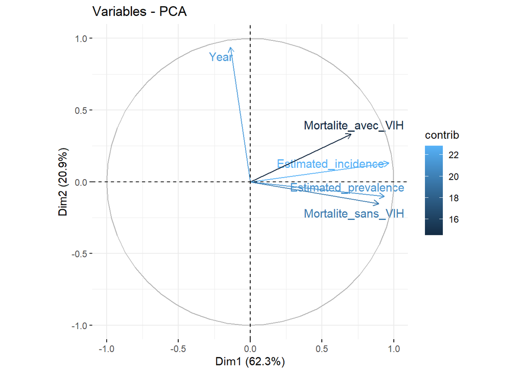

```r
TB2_ACP_comparaison <- TB2_ACP %>%
  filter(Year %in% c(1990, 2000, 2013)) #Filtrer les données pour ne conserver que les années 1990, 2000 et 2013

res.pca.comparaison =PCA(TB2_ACP_comparaison[,3:7],# Sélection des colonnes 3 à 7 du tableau de données 'TB2_ACP'

             scale.unit = TRUE,# Les données sont centrées (moyenne = 0) et réduites (écart-type = 1)

             graph=F)  # Désactive l'affichage automatique des graphiques de l'ACP.

# Visualisation du cercle des corrélations (représentation des variables dans le plan factoriel)
fviz_pca_var(res.pca.comparaison, # Résultat de l'ACP effectuée précédemment (objet PCA)
             col.var = "contrib",    # Colorier selon la contribution on vera cela plus en détail avec le sceenplot

             repel = T) # Active la répulsion automatique des étiquettes pour éviter qu'elles ne se chevauchent
```

Les points communs entre le cercle de corrélation de l’année 2000 et celui des années 1990, 2000 et 2013 Les deux cercles de corrélations représentent les mêmes variables : Year, Mortalite_avec_VIH, Estimated_incidence, Estimated_prevalence, et Mortalite_sans_VIH.

La distribution directionnelle des variables est globalement similaire : les flèches des variables épidémiologiques sont orientées vers la droite (Dim1), et Year vers le haut (Dim2).

Leur représentation est un peu plus serrée et orientée dans la même direction, ce qui suggère une structure de corrélation plus stable sur le temps.

La contribution de Year est différente. Dans le premier cercle (année 2000), la flèche Year est fortement marquée vers le haut, ce qui signifie que Year varie beaucoup dans la base (c’est logique puisqu’il n’y a qu’une seule année, donc ça ne capture rien de pertinent — cette variable peut même être considérée comme artificielle dans ce contexte).

Dans le deuxième cercle (1990, 2000, 2013), Year est aussi pointée vers le haut, mais elle semble légèrement plus courte donc sa contribution à Dim2 est un peu moins forte, peut-être parce que sa variation est intégrée dans d’autres dimensions.

En somme, contrairement à l’analyse restreinte à l’année 2000, les variables Estimated_prevalence, Estimated_incidence, Mortalite_sans_VIH, et Mortalite_avec_VIH sont encore plus fortement corrélées entre elles dans le graphique multi-années. Leur groupement serré confirme qu’elles évoluent ensemble au fil du temps. La variable Year, bien que toujours fortement associée à Dim2, a une contribution visiblement plus modérée, ce qui montre qu’elle n’explique plus seule la variabilité capturée par cette dimension. Elle est absorbée dans des dynamiques temporelles plus larges.

###Pourcentage de variance expliqués

```r
# Affichage du tableau avec kable
kable(get_eig(res.pca.comparaison),# Extraire les valeurs propres de l'ACP

      caption = "Pourcentage des variance expliqués") %>%# Titre du tableau

  kable_styling(full_width = FALSE, # Limite la largeur du tableau pour ne pas qu'il s'étende sur toute la page

              position = "center",  # Centre le tableau horizontalement dans la page

       bootstrap_options = c("striped",# "striped" : alterne la couleur des lignes pour une meilleure lisibilité

                             "hover"))%>% # "hover"   : surbrillance d'une ligne au passage de la souris (utile en affichage interactif)

   column_spec(1, bold = TRUE)# la première colonne est en gras
```

Pourcentage des variance expliqués

|  | eigenvalue | variance.percent | cumulative.variance.percent |
| --- | --- | --- | --- |
| Dim.1 | 3.1140868 | 62.2817351 | 62.28174 |
| Dim.2 | 1.0432518 | 20.8650351 | 83.14677 |
| Dim.3 | 0.6745791 | 13.4915824 | 96.63835 |
| Dim.4 | 0.1397211 | 2.7944222 | 99.43277 |
| Dim.5 | 0.0283613 | 0.5672252 | 100.00000 |

Explication des colonnes : - Eigenvalue (Valeur propre) : indique l’importance de chaque dimension. Une valeur propre élevée signifie que la composante explique une grande part de la variance. - Variance Percent : donne le pourcentage de variance totale expliqué par chaque composante. - Cumulative Variance Percent : indique la somme des variances expliquées jusqu’à la dimension concernée.

Analyse des résultats pour les années 1990, 2000, 2013 :

- Dim.1 (62.28%) : La première composante principale explique 62.28% de la variance, ce qui en fait la plus influente. Elle capture donc la structure principale de l’information dans les données.
- Dim.2 (20.87%) : La deuxième composante ajoute 20.87%, portant la variance cumulée à 83.15%. Cela signifie qu’à elles deux, Dim.1 et Dim.2 expliquent déjà plus de 80% de la variabilité, ce qui est excellent pour une visualisation en deux dimensions.
- Dim.3 (13.49%) : La troisième composante explique encore 13.49%, ce qui permet d’atteindre une variance cumulée de 96.64%. Cela suggère que les trois premières dimensions suffisent amplement à représenter les données.
- Dim.4 et Dim.5 : Comme pour l’année 2000, ces dimensions n’apportent qu’une contribution faible (≈2.79% et 0.57%), donc elles ne sont pas essentielles pour l’interprétation principale.

En somme, la structure de la variance est très proche de celle de l’année 2000 seule, ce qui confirme une stabilité dans les relations structurelles entre les variables au fil du temps. Les trois premières dimensions sont suffisantes pour expliquer près de 97% de la variance totale, ce qui valide leur usage pour une analyse visuelle ou pour une réduction de dimensionnalité.

Pour choisir combien d’informations on garde, on fait un screeplot :

### Screeplot

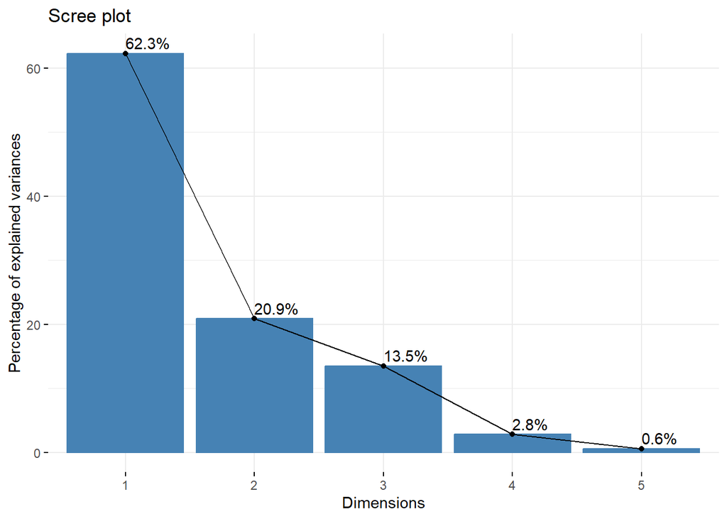

```r
fviz_screeplot(res.pca.comparaison, # Objet contenant les résultats de l'ACP réalisé précédemment avec la fonction PCA()

               addlabels=TRUE)# Ajoute les étiquettes numériques au-dessus des barres du scree plot
```

Ce graphique représente le Scree plot des années 1990; 2000 et 2013, utilisé pour visualiser les résultats d’une Analyse en Composantes Principales (ACP).

Les barres bleues indiquent le pourcentage de la variance expliquée par chaque dimension (ou composante principale).

La Dimension 2 apporte un complément important dans les deux cas, autour de 20.6–20.9% de variance expliquée.

Les Dimensions 4 et 5 ont un impact très faible (< 3% et < 1%) et peuvent être considérées comme non informatives.

Le profil global du scree plot est similaire : forte pente après Dim.1, puis décroissance plus lente ce qui est typique d’une structure avec 2 ou 3 dimensions importantes.

Les différences entre le scree plot de l’année 2000 et celui des années 1990 ,2000, 2013: La Dimension 3 explique légèrement plus de variance dans le graphique 1990–2013 : - 2000 : 12.8% - 1990–2013 : 13.5% Cela suggère qu’en prenant en compte plusieurs années, une troisième composante structurelle émerge plus clairement.

En cumulant Dim.1 à Dim.3 : - 2000 : 96.3% - 1990–2013 : 96.6% On capte donc un tout petit peu plus de variance avec les trois premières dimensions quand on utilise les données multi-années.

Les deux scree plots montrent donc une structure très stable, centrée sur les deux premières dimensions. Toutefois, le scree plot de 1990 2000 et 2013 indique que la troisième dimension devient légèrement plus informative, ce qui peut refléter des dynamiques temporelles supplémentaires dans les données. Cela pourrait justifier, dans cette version multi-temporelle, une analyse sur 3 dimensions au lieu de seulement 2.